# Pergunta_3-Contaminantes

# Pergunta 3

**Está ocorrendo contaminação por elementos químicos e consequentes danos em espécies de invertebrados e de pequenos vertebrados (anfíbios, répteis, roedores e marsupiais) que estão em contato direto com o rejeito?**

# Sintese

## Objetivo

- Sintetizar os efeitos da contaminação na fauna.

### 1. Invertebrado vs Vertebrado

#### Dados

| tipo_de_sitio | sitio_amostral | campanha | distância_lama | especie | aluminio_total | arsenio_total | cadmio_total | chumbo_total | cobalto_total | cobre_total | cromo_total | ferro_total | manganes_total | niquel_total | vanadio_total | zinco_total | taxon | grupo |
| --- | --- | --- | --- | --- | --- | --- | --- | --- | --- | --- | --- | --- | --- | --- | --- | --- | --- | --- |
| Norte | E4 | 5ª campanha | 0.4049292 | Rhinella granulosa | 15.7 | NA | 0.05 | NA | NA | 384.2 | 0.33 | 802.8 | 4.5 | 0.5 | NA | 32 | Herpetofauna | Vertebrado |
| Norte | E4 | 5ª campanha | 0.4049292 | Rhinella granulosa | 0.4 | NA | NA | NA | NA | 0.6 | NA | 12.6 | 0.2 | NA | NA | 15 | Herpetofauna | Vertebrado |
| Norte | E4 | 5ª campanha | 0.4049292 | Tropidurus torquatus | 12.8 | 0.23 | NA | NA | NA | 5.3 | NA | 327.1 | 2.2 | NA | NA | 37 | Herpetofauna | Vertebrado |
| Norte | E4 | 5ª campanha | 0.4049292 | Tropidurus torquatus | 0.4 | 0.07 | NA | NA | NA | NA | 0.11 | 7.8 | 2.6 | NA | NA | 9 | Herpetofauna | Vertebrado |
| Norte | E4 | 5ª campanha | 0.4049292 | Tropidurus torquatus | 4 | NA | NA | NA | NA | NA | NA | 11.5 | 0.5 | NA | NA | 15 | Herpetofauna | Vertebrado |
| Norte | E4 | 5ª campanha | 0.4049292 | Tropidurus torquatus | 16.6 | 1.36 | 0.05 | NA | NA | 4.1 | NA | 308.4 | 1.5 | NA | NA | 29 | Herpetofauna | Vertebrado |
| Norte | E4 | 5ª campanha | 0.4049292 | Tropidurus torquatus | 1.2 | NA | NA | NA | NA | NA | NA | 5.4 | 0.1 | NA | NA | 9 | Herpetofauna | Vertebrado |
| Norte | E4 | 5ª campanha | 0.4049292 | Tropidurus torquatus | 1.8 | 0.01 | 0.05 | NA | NA | NA | NA | 10.1 | 0.3 | NA | NA | 10 | Herpetofauna | Vertebrado |
| Norte | E4 | 5ª campanha | 0.4049292 | Tropidurus torquatus | 4.9 | 0.18 | NA | NA | NA | 0.4 | 0.05 | 9.7 | 0.3 | NA | NA | 6 | Herpetofauna | Vertebrado |
| Norte | E5 | 5ª campanha | -1.5781909 | Rhinella granulosa | 2 | 1.13 | NA | NA | NA | 126.4 | NA | 192.2 | 1.3 | NA | NA | 21 | Herpetofauna | Vertebrado |
| Norte | E5 | 5ª campanha | -1.5781909 | Rhinella granulosa | 3 | NA | NA | NA | NA | 0.4 | NA | 17.4 | 0.3 | NA | NA | 12 | Herpetofauna | Vertebrado |
| Norte | E5 | 5ª campanha | -1.5781909 | Rhinella granulosa | 1.2 | 0.28 | NA | NA | NA | 182 | NA | 203 | 3.2 | NA | NA | 24 | Herpetofauna | Vertebrado |
| Norte | E5 | 5ª campanha | -1.5781909 | Rhinella granulosa | 3.5 | 0.23 | NA | NA | NA | 0.9 | NA | 8.6 | 0.4 | NA | NA | 19 | Herpetofauna | Vertebrado |
| Norte | E5 | 5ª campanha | -1.5781909 | Rhinella granulosa | 1.2 | NA | 0.05 | NA | NA | 226 | NA | 200.5 | 3.2 | NA | NA | 20 | Herpetofauna | Vertebrado |
| Norte | E5 | 5ª campanha | -1.5781909 | Rhinella granulosa | 6.3 | NA | NA | NA | NA | 0.8 | NA | 8.9 | 0.4 | NA | NA | 18 | Herpetofauna | Vertebrado |
| Norte | E5 | 5ª campanha | -1.5781909 | Tropidurus torquatus | 15.7 | 0.08 | NA | NA | NA | 0.4 | NA | 7 | 0.3 | NA | NA | 12 | Herpetofauna | Vertebrado |
| Norte | E5 | 5ª campanha | -1.5781909 | Tropidurus torquatus | 11.5 | 0.69 | NA | NA | NA | 3.4 | NA | 335.2 | 1.6 | NA | NA | 35 | Herpetofauna | Vertebrado |
| Norte | E5 | 5ª campanha | -1.5781909 | Tropidurus torquatus | 4.1 | NA | NA | NA | NA | NA | NA | 5.7 | 0.1 | NA | NA | 9 | Herpetofauna | Vertebrado |
| Norte | E5 | 5ª campanha | -1.5781909 | Tropidurus torquatus | 0.4 | NA | 0.05 | NA | NA | 2.8 | NA | 629.3 | 1.3 | NA | NA | 29 | Herpetofauna | Vertebrado |
| Norte | E5 | 5ª campanha | -1.5781909 | Tropidurus torquatus | 1.6 | 0.67 | NA | NA | NA | NA | NA | 4.3 | 0.1 | <0.1 | NA | 16 | Herpetofauna | Vertebrado |
| Norte | E5 | 5ª campanha | -1.5781909 | Rhinella granulosa | 6.2 | 1.75 | 0.05 | NA | NA | 217.7 | NA | 141.5 | 2.2 | NA | NA | 24 | Herpetofauna | Vertebrado |
| Norte | E5 | 5ª campanha | -1.5781909 | Rhinella granulosa | 1.8 | NA | NA | NA | NA | 1.4 | NA | 12.5 | 0.5 | NA | NA | 15 | Herpetofauna | Vertebrado |
| Norte | E5 | 5ª campanha | -1.5781909 | Rhinella granulosa | 20.6 | 0.35 | NA | NA | NA | 337.5 | NA | 205.4 | 4.9 | NA | NA | 35 | Herpetofauna | Vertebrado |
| Norte | E5 | 5ª campanha | -1.5781909 | Rhinella granulosa | 1.3 | 0.33 | NA | NA | NA | 1.3 | NA | 13 | 0.4 | NA | NA | 14 | Herpetofauna | Vertebrado |
| Norte | E5 | 5ª campanha | -1.5781909 | Tropidurus torquatus | 4.4 | 0.13 | 0.06 | NA | NA | 4.4 | NA | 267.5 | 1.2 | NA | NA | 21 | Herpetofauna | Vertebrado |
| Norte | E5 | 5ª campanha | -1.5781909 | Tropidurus torquatus | 3.6 | 0.34 | NA | NA | NA | 0.4 | NA | 7.7 | 0.3 | NA | NA | 11 | Herpetofauna | Vertebrado |
| Norte | E5 | 5ª campanha | -1.5781909 | Tropidurus torquatus | 21 | 0.13 | NA | NA | NA | NA | NA | 27.2 | 1.1 | NA | NA | 19 | Herpetofauna | Vertebrado |
| Norte | E5 | 5ª campanha | -1.5781909 | Tropidurus torquatus | 3.6 | 1.17 | 0.07 | NA | NA | 2.3 | NA | 326.9 | 0.8 | NA | NA | 20 | Herpetofauna | Vertebrado |
| Norte | E5 | 5ª campanha | -1.5781909 | Tropidurus torquatus | 6 | 0.21 | NA | NA | NA | 0.4 | NA | 6.3 | 0.1 | NA | NA | 8 | Herpetofauna | Vertebrado |
| Norte | E5 | 5ª campanha | -1.5781909 | Tropidurus torquatus | 7.8 | 0.75 | NA | NA | NA | 0.4 | NA | 18.1 | 0.6 | NA | NA | 11 | Herpetofauna | Vertebrado |

[output cut: 2130 more lines]

#### Modelo

O modelo consideranto todos os grupos avaliados levou em consideração as variaveis comuns a todos os grupos.

- Variaveis respostas A concentração dos 12 metais transformadas em log permitindo ajuste dos modelos aos pressupostos.
- Variaveis explicativas Os diferentes tipos de sitios, as campanhas e a distancia do rejeito.
- Aleatorio Foi utilizado os sitios amostrais, as especies aninhadas ao taxon avaliado.

##### Aluminio

- Resultado do modelo

```
## Analysis of Deviance Table (Type II Wald chisquare tests)
##
## Response: aluminio_total
##                            Chisq Df Pr(>Chisq)
## distância_lama            0.4915  1     0.4833
## tipo_de_sitio            70.4060 14  1.629e-09 ***
## campanha               1455.1671  2  < 2.2e-16 ***
## tipo_de_sitio:campanha  661.2179 12  < 2.2e-16 ***
## ---
## Signif. codes:  0 '***' 0.001 '**' 0.01 '*' 0.05 '.' 0.1 ' ' 1
```

##### Arsenio

- Resultado do modelo

```
## Analysis of Deviance Table (Type II Wald chisquare tests)
##
## Response: arsenio_total
##                           Chisq Df Pr(>Chisq)
## distância_lama           0.0895  1  0.7647836
## tipo_de_sitio           39.9566 13  0.0001405 ***
## campanha                 9.8732  2  0.0071789 **
## tipo_de_sitio:campanha 234.2621  9  < 2.2e-16 ***
## ---
## Signif. codes:  0 '***' 0.001 '**' 0.01 '*' 0.05 '.' 0.1 ' ' 1
```

##### Chumbo

- Resultado do modelo

```
## Analysis of Deviance Table (Type II Wald chisquare tests)
##
## Response: chumbo_total
##                          Chisq Df Pr(>Chisq)
## distância_lama          0.2750  1     0.6000
## tipo_de_sitio          78.9884 14  4.357e-11 ***
## campanha                2.5976  2     0.2729
## tipo_de_sitio:campanha 45.2207  9  8.398e-07 ***
## ---
## Signif. codes:  0 '***' 0.001 '**' 0.01 '*' 0.05 '.' 0.1 ' ' 1
```

##### Cadmio

- Resultado do modelo

```
## Analysis of Deviance Table (Type II Wald chisquare tests)
##
## Response: cadmio_total
##                          Chisq Df Pr(>Chisq)
## distância_lama          0.4046  1   0.524738
## tipo_de_sitio          23.1279 13   0.040167 *
## campanha                6.6508  1   0.009911 **
## tipo_de_sitio:campanha 26.3799 11   0.005696 **
## ---
## Signif. codes:  0 '***' 0.001 '**' 0.01 '*' 0.05 '.' 0.1 ' ' 1
```

##### Cobalto

- Resultado do modelo

```
## Analysis of Deviance Table (Type II Wald chisquare tests)
##
## Response: cobalto_total
##                          Chisq Df Pr(>Chisq)
## distância_lama          0.3784  1    0.53843
## tipo_de_sitio          24.6245 12    0.01671 *
## campanha                0.0614  1    0.80426
## tipo_de_sitio:campanha  8.5701  4    0.07279 .
## ---
## Signif. codes:  0 '***' 0.001 '**' 0.01 '*' 0.05 '.' 0.1 ' ' 1
```

##### Cobre

- Resultado do modelo

```
## Analysis of Deviance Table (Type II Wald chisquare tests)
##
## Response: cobre_total
##                           Chisq Df Pr(>Chisq)
## distância_lama           0.0733  1     0.7866
## tipo_de_sitio          106.8730 14  2.255e-16 ***
## campanha                 2.3915  2     0.3025
## tipo_de_sitio:campanha  14.2833 12     0.2830
## ---
## Signif. codes:  0 '***' 0.001 '**' 0.01 '*' 0.05 '.' 0.1 ' ' 1
```

##### Cromo

- Resultado do modelo

```
## Analysis of Deviance Table (Type II Wald chisquare tests)
##
## Response: cromo_total
##                          Chisq Df Pr(>Chisq)
## distância_lama          2.3769  1     0.1231
## tipo_de_sitio          94.3806 14  5.609e-14 ***
## campanha               97.2580  2  < 2.2e-16 ***
## tipo_de_sitio:campanha 51.5553 10  1.379e-07 ***
## ---
## Signif. codes:  0 '***' 0.001 '**' 0.01 '*' 0.05 '.' 0.1 ' ' 1
```

##### Ferro

- Resultado do modelo

```
## Analysis of Deviance Table (Type II Wald chisquare tests)
##
## Response: ferro_total
##                           Chisq Df Pr(>Chisq)
## distância_lama           0.8991  1  0.3430217
## tipo_de_sitio           37.0452 14  0.0007262 ***
## campanha                12.0478  2  0.0024202 **
## tipo_de_sitio:campanha 485.2653 12  < 2.2e-16 ***
## ---
## Signif. codes:  0 '***' 0.001 '**' 0.01 '*' 0.05 '.' 0.1 ' ' 1
```

##### Manganes

- Resultado do modelo

```
## Analysis of Deviance Table (Type II Wald chisquare tests)
##
## Response: manganes_total
##                           Chisq Df Pr(>Chisq)
## distância_lama           0.6741  1     0.4116
## tipo_de_sitio           94.9405 14  4.389e-14 ***
## campanha                50.9411  2  8.675e-12 ***
## tipo_de_sitio:campanha 644.5598 12  < 2.2e-16 ***
## ---
## Signif. codes:  0 '***' 0.001 '**' 0.01 '*' 0.05 '.' 0.1 ' ' 1
```

##### Niquel

- Resultado do modelo

```
## Analysis of Deviance Table (Type II Wald chisquare tests)
##
## Response: niquel_total
##                           Chisq Df Pr(>Chisq)
## distância_lama           2.7311  1    0.09841 .
## tipo_de_sitio           66.2317 11  6.317e-10 ***
## campanha                16.1188  1  5.949e-05 ***
## tipo_de_sitio:campanha 128.9894  8  < 2.2e-16 ***
## ---
## Signif. codes:  0 '***' 0.001 '**' 0.01 '*' 0.05 '.' 0.1 ' ' 1
```

##### Vanadio

- Resultado do modelo

```
## Analysis of Deviance Table (Type II Wald chisquare tests)
##
## Response: vanadio_total
##                           Chisq Df Pr(>Chisq)
## distância_lama           6.5873  1    0.01027 *
## tipo_de_sitio          138.1659 10    < 2e-16 ***
## campanha               119.5863  2    < 2e-16 ***
## tipo_de_sitio:campanha 703.5840  6    < 2e-16 ***
## ---
## Signif. codes:  0 '***' 0.001 '**' 0.01 '*' 0.05 '.' 0.1 ' ' 1
```

##### Zinco

- Resultado do modelo

```
## Analysis of Deviance Table (Type II Wald chisquare tests)
##
## Response: zinco_total
##                            Chisq Df Pr(>Chisq)
## distância_lama            0.0333  1     0.8551
## tipo_de_sitio           168.4643 14     <2e-16 ***
## campanha                  4.1008  2     0.1287
## tipo_de_sitio:campanha 1178.9476 12     <2e-16 ***
## ---
## Signif. codes:  0 '***' 0.001 '**' 0.01 '*' 0.05 '.' 0.1 ' ' 1
```

#### Grafico

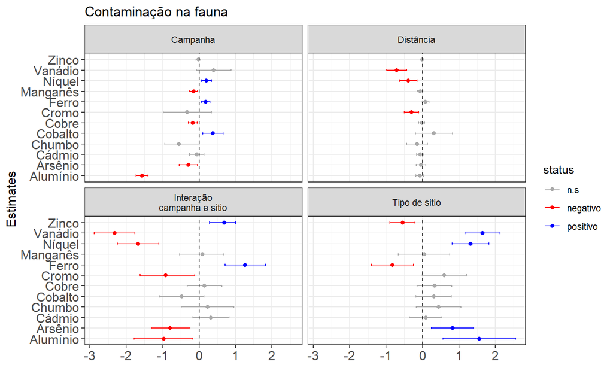

# Herpetofauna

## Objetivo

- Apresentar os resultados obitidos da contaminação de metais na herpetofauna.

## Dados coletados

| codigo_oceanus | id_amostra | id_da_planilha_de_campo | sitio_amostral | tipo_de_sitio | especie | n_individuos | orgao | peso_g_amostra | aluminio_total | arsenio_total | cadmio_total | chumbo_total | cobalto_total | cobre_total | cromo_total | ferro_total | manganes_total | niquel_total | vanadio_total | zinco_total | unidade | campanha | distância_Oceano | distância_lama |
| --- | --- | --- | --- | --- | --- | --- | --- | --- | --- | --- | --- | --- | --- | --- | --- | --- | --- | --- | --- | --- | --- | --- | --- | --- |
| 2594430 | LB_HPT_1002 | HPT_C319 | E4 | Norte | Rhinella granulosa | 1 | Figado | 0.093 | 15.7 | NA | 0.05 | NA | NA | 384.2 | 0.33 | 802.8 | 4.5 | 0.5 | NA | 32 | mg/Kg | Campanha_5 | -0.8277388 | 0.4049292 |
| 2594363 | LB_HPT_1003 | HPT_C319 | E4 | Norte | Rhinella granulosa | 1 | Musculo | 0.32 | 0.4 | NA | NA | NA | NA | 0.6 | NA | 12.6 | 0.2 | NA | NA | 15 | mg/Kg | Campanha_5 | -0.8277388 | 0.4049292 |
| 2594373 | LB_HPT_1007 | HPT_C313 | E4 | Norte | Tropidurus torquatus | 1 | Figado | 0.089 | 12.8 | 0.23 | NA | NA | NA | 5.3 | NA | 327.1 | 2.2 | NA | NA | 37 | mg/Kg | Campanha_5 | -0.8277388 | 0.4049292 |
| 2594383 | LB_HPT_1008 | HPT_C313 | E4 | Norte | Tropidurus torquatus | 1 | Musculo | 0.289 | 0.4 | 0.07 | NA | NA | NA | NA | 0.11 | 7.8 | 2.6 | NA | NA | 9 | mg/Kg | Campanha_5 | -0.8277388 | 0.4049292 |
| 2672845 | LB_HPT_1109 | HPT_C323 | E4 | Norte | Tropidurus torquatus | 1 | Musculo | 0.214 | 4 | NA | NA | NA | NA | NA | NA | 11.5 | 0.5 | NA | NA | 15 | mg/Kg | Campanha_5 | -0.8277388 | 0.4049292 |
| 2672852 | LB_HPT_1112 | HPT_C324 | E4 | Norte | Tropidurus torquatus | 1 | Figado | 0.156 | 16.6 | 1.36 | 0.05 | NA | NA | 4.1 | NA | 308.4 | 1.5 | NA | NA | 29 | mg/Kg | Campanha_5 | -0.8277388 | 0.4049292 |
| 2672873 | LB_HPT_1113 | HPT_C324 | E4 | Norte | Tropidurus torquatus | 1 | Musculo | 0.586 | 1.2 | NA | NA | NA | NA | NA | NA | 5.4 | 0.1 | NA | NA | 9 | mg/Kg | Campanha_5 | -0.8277388 | 0.4049292 |
| 2672853 | LB_HPT_1141 | HPT_C375 | E4 | Norte | Tropidurus torquatus | 1 | Musculo | 0.209 | 1.8 | 0.01 | 0.05 | NA | NA | NA | NA | 10.1 | 0.3 | NA | NA | 10 | mg/Kg | Campanha_5 | -0.8277388 | 0.4049292 |
| 2672908 | LB_HPT_1144 | HPT_C380 | E4 | Norte | Tropidurus torquatus | 1 | Musculo | 0.185 | 4.9 | 0.18 | NA | NA | NA | 0.4 | 0.05 | 9.7 | 0.3 | NA | NA | 6 | mg/Kg | Campanha_5 | -0.8277388 | 0.4049292 |
| 2594439 | LB_HPT_1017 | HPT_C315 | E5 | Norte | Rhinella granulosa | 1 | Figado | 0.155 | 2 | 1.13 | NA | NA | NA | 126.4 | NA | 192.2 | 1.3 | NA | NA | 21 | mg/Kg | Campanha_5 | -0.5172227 | -1.5781909 |
| 2594418 | LB_HPT_1018 | HPT_C315 | E5 | Norte | Rhinella granulosa | 1 | Musculo | 0.2 | 3 | NA | NA | NA | NA | 0.4 | NA | 17.4 | 0.3 | NA | NA | 12 | mg/Kg | Campanha_5 | -0.5172227 | -1.5781909 |
| 2594440 | LB_HPT_1022 | HPT_C316 | E5 | Norte | Rhinella granulosa | 1 | Figado | 0.267 | 1.2 | 0.28 | NA | NA | NA | 182 | NA | 203 | 3.2 | NA | NA | 24 | mg/Kg | Campanha_5 | -0.5172227 | -1.5781909 |
| 2594371 | LB_HPT_1023 | HPT_C316 | E5 | Norte | Rhinella granulosa | 1 | Musculo | 0.311 | 3.5 | 0.23 | NA | NA | NA | 0.9 | NA | 8.6 | 0.4 | NA | NA | 19 | mg/Kg | Campanha_5 | -0.5172227 | -1.5781909 |
| 2594431 | LB_HPT_1027 | HPT_C317 | E5 | Norte | Rhinella granulosa | 1 | Figado | 0.19 | 1.2 | NA | 0.05 | NA | NA | 226 | NA | 200.5 | 3.2 | NA | NA | 20 | mg/Kg | Campanha_5 | -0.5172227 | -1.5781909 |
| 2594405 | LB_HPT_1028 | HPT_C317 | E5 | Norte | Rhinella granulosa | 1 | Musculo | 0.236 | 6.3 | NA | NA | NA | NA | 0.8 | NA | 8.9 | 0.4 | NA | NA | 18 | mg/Kg | Campanha_5 | -0.5172227 | -1.5781909 |
| 2672859 | LB_HPT_1086 | HPT_C326 | E5 | Norte | Tropidurus torquatus | 1 | Musculo | 0.418 | 15.7 | 0.08 | NA | NA | NA | 0.4 | NA | 7 | 0.3 | NA | NA | 12 | mg/Kg | Campanha_5 | -0.5172227 | -1.5781909 |
| 2672841 | LB_HPT_1090 | HPT_C328 | E5 | Norte | Tropidurus torquatus | 1 | Figado | 0.131 | 11.5 | 0.69 | NA | NA | NA | 3.4 | NA | 335.2 | 1.6 | NA | NA | 35 | mg/Kg | Campanha_5 | -0.5172227 | -1.5781909 |
| 2672871 | LB_HPT_1091 | HPT_C328 | E5 | Norte | Tropidurus torquatus | 1 | Musculo | 0.555 | 4.1 | NA | NA | NA | NA | NA | NA | 5.7 | 0.1 | NA | NA | 9 | mg/Kg | Campanha_5 | -0.5172227 | -1.5781909 |
| 2672842 | LB_HPT_1095 | HPT_C329 | E5 | Norte | Tropidurus torquatus | 1 | Figado | 0.232 | 0.4 | NA | 0.05 | NA | NA | 2.8 | NA | 629.3 | 1.3 | NA | NA | 29 | mg/Kg | Campanha_5 | -0.5172227 | -1.5781909 |
| 2672856 | LB_HPT_1096 | HPT_C329 | E5 | Norte | Tropidurus torquatus | 1 | Musculo | 0.637 | 1.6 | 0.67 | NA | NA | NA | NA | NA | 4.3 | 0.1 | <0.1 | NA | 16 | mg/Kg | Campanha_5 | -0.5172227 | -1.5781909 |
| 2672833 | LB_HPT_1100 | HPT_C321 | E5 | Norte | Rhinella granulosa | 1 | Figado | 0.149 | 6.2 | 1.75 | 0.05 | NA | NA | 217.7 | NA | 141.5 | 2.2 | NA | NA | 24 | mg/Kg | Campanha_5 | -0.5172227 | -1.5781909 |
| 2672863 | LB_HPT_1101 | HPT_C321 | E5 | Norte | Rhinella granulosa | 1 | Musculo | 0.333 | 1.8 | NA | NA | NA | NA | 1.4 | NA | 12.5 | 0.5 | NA | NA | 15 | mg/Kg | Campanha_5 | -0.5172227 | -1.5781909 |
| 2672900 | LB_HPT_1105 | HPT_C322 | E5 | Norte | Rhinella granulosa | 1 | Figado | 0.111 | 20.6 | 0.35 | NA | NA | NA | 337.5 | NA | 205.4 | 4.9 | NA | NA | 35 | mg/Kg | Campanha_5 | -0.5172227 | -1.5781909 |
| 2672867 | LB_HPT_1106 | HPT_C322 | E5 | Norte | Rhinella granulosa | 1 | Musculo | 0.303 | 1.3 | 0.33 | NA | NA | NA | 1.3 | NA | 13 | 0.4 | NA | NA | 14 | mg/Kg | Campanha_5 | -0.5172227 | -1.5781909 |
| 2672912 | LB_HPT_1120 | HPT_C368 | E5 | Norte | Tropidurus torquatus | 1 | Figado | 0.048 | 4.4 | 0.13 | 0.06 | NA | NA | 4.4 | NA | 267.5 | 1.2 | NA | NA | 21 | mg/Kg | Campanha_5 | -0.5172227 | -1.5781909 |
| 2672843 | LB_HPT_1121 | HPT_C368 | E5 | Norte | Tropidurus torquatus | 1 | Musculo | 0.624 | 3.6 | 0.34 | NA | NA | NA | 0.4 | NA | 7.7 | 0.3 | NA | NA | 11 | mg/Kg | Campanha_5 | -0.5172227 | -1.5781909 |
| 2672864 | LB_HPT_1130 | HPT_C312 | E5 | Norte | Tropidurus torquatus | 1 | Musculo | 0.15 | 21 | 0.13 | NA | NA | NA | NA | NA | 27.2 | 1.1 | NA | NA | 19 | mg/Kg | Campanha_5 | -0.5172227 | -1.5781909 |
| 2672875 | LB_HPT_1137 | HPT_C374 | E5 | Norte | Tropidurus torquatus | 1 | Figado | 0.192 | 3.6 | 1.17 | 0.07 | NA | NA | 2.3 | NA | 326.9 | 0.8 | NA | NA | 20 | mg/Kg | Campanha_5 | -0.5172227 | -1.5781909 |
| 2672828 | LB_HPT_1138 | HPT_C374 | E5 | Norte | Tropidurus torquatus | 1 | Musculo | 0.459 | 6 | 0.21 | NA | NA | NA | 0.4 | NA | 6.3 | 0.1 | NA | NA | 8 | mg/Kg | Campanha_5 | -0.5172227 | -1.5781909 |
| 2672847 | LB_HPT_1146 | HPT_C378 | E5 | Norte | Tropidurus torquatus | 1 | Musculo | 0.458 | 7.8 | 0.75 | NA | NA | NA | 0.4 | NA | 18.1 | 0.6 | NA | NA | 11 | mg/Kg | Campanha_5 | -0.5172227 | -1.5781909 |

[output cut: 183 more lines]

## Tabela de contaminantes

| tipo_de_sitio | especie | orgao | campanha | N_amostrado | Aluminio_mean | Aluminio_sd | Aluminio_n | Arsenio_mean | Arsenio_sd | Arsenio_n | Cadmio_mean | Cadmio_sd | Cadmio_n | Chumbo_mean | Chumbo_sd | Chumbo_n | cobalto_mean | cobalto_sd | cobalto_n | Cobre_mean | Cobre_sd | Cobre_n | Cromo_mean | Cromo_sd | Cromo_n | Ferro_mean | Ferro_sd | Ferro_n | Manganes_mean | … |
| --- | --- | --- | --- | --- | --- | --- | --- | --- | --- | --- | --- | --- | --- | --- | --- | --- | --- | --- | --- | --- | --- | --- | --- | --- | --- | --- | --- | --- | --- | --- |
| Norte | Rhinella granulosa | Figado | Campanha_3 | 4 | 550.225000 | 468.862143 | 4 | 0.3750000 | 0.1740690 | 4 | NaN | NA | 0 | 0.2033333 | 0.1429452 | 3 | 0.05 | NA | 1 | 177.1500000 | 65.6520881 | 4 | 0.342500 | 0.1753805 | 4 | 212.575000 | 89.173403 | 4 | 7.6750000 | … |
| Norte | Rhinella granulosa | Figado | Campanha_5 | 18 | 9.500000 | 6.657857 | 17 | 0.8530769 | 0.4613275 | 13 | 0.0550000 | 0.0124316 | 3 | NaN | NA | 0 | NaN | NA | 0 | 272.6777778 | 95.5338594 | 18 | 0.330000 | NA | 1 | 308.900000 | 211.329550 | 18 | 2.7777778 | … |
| Norte | Rhinella granulosa | Musculo | Campanha_3 | 17 | 1254.347059 | 1098.392459 | 17 | 0.4900000 | 0.3798772 | 15 | NaN | NA | 0 | 0.2757143 | 0.4757400 | 5 | NaN | NA | 0 | 6.4312500 | 5.2603826 | 15 | 0.664375 | 0.4572959 | 14 | 52.058824 | 59.726272 | 17 | 13.6615385 | … |
| Norte | Rhinella granulosa | Musculo | Campanha_5 | 21 | 3.745000 | 2.963013 | 17 | 0.3745455 | 0.4651960 | 9 | 0.0600000 | 0.0173205 | 2 | NaN | NA | 0 | NaN | NA | 0 | 0.7761905 | 0.3269629 | 9 | 0.050000 | NA | 1 | 12.425000 | 5.261966 | 19 | 1.3809524 | … |
| Norte | Tropidurus torquatus | Figado | Campanha_3 | 7 | 1002.685714 | 601.804582 | 7 | 0.5342857 | 0.1912117 | 7 | 0.0766667 | 0.0287518 | 5 | 0.5580000 | 0.4837045 | 5 | 0.06 | 0.0173205 | 2 | 12.1857143 | 8.4657011 | 7 | 1.326667 | 0.9754315 | 6 | 492.557143 | 225.329602 | 7 | 12.0714286 | … |
| Norte | Tropidurus torquatus | Figado | Campanha_5 | 9 | 8.033333 | 5.697148 | 8 | 0.5885714 | 0.5060444 | 7 | 0.0600000 | 0.0152753 | 4 | NaN | NA | 0 | NaN | NA | 0 | 3.5222222 | 1.1211353 | 9 | NaN | NA | 0 | 316.344444 | 145.525145 | 9 | 1.2444444 | … |
| Norte | Tropidurus torquatus | Musculo | Campanha_3 | 20 | 583.694737 | 623.766533 | 19 | 0.3400000 | 0.1453489 | 20 | NaN | NA | 0 | 0.1173333 | 0.1095749 | 10 | 0.08 | NA | 1 | 2.7916667 | 3.4392014 | 9 | 2.282105 | 6.6360627 | 15 | 44.022222 | 62.935930 | 18 | 6.0900000 | … |
| Norte | Tropidurus torquatus | Musculo | Campanha_5 | 20 | 5.915000 | 5.382063 | 20 | 0.3573333 | 0.3759268 | 14 | 0.0500000 | NA | 1 | NaN | NA | 0 | NaN | NA | 0 | 0.4272727 | 0.0646670 | 3 | 0.080000 | 0.0424264 | 2 | 9.895000 | 6.732363 | 19 | 0.4941176 | … |
| Sul | Rhinella granulosa | Figado | Campanha_5 | 8 | 8.212500 | 4.047376 | 8 | 0.9328571 | 1.2727230 | 6 | 0.0800000 | 0.0435890 | 3 | NaN | NA | 0 | NaN | NA | 0 | 306.4500000 | 180.3866007 | 8 | NaN | NA | 0 | 794.350000 | 1139.734952 | 8 | 3.5250000 | … |
| Sul | Rhinella granulosa | Musculo | Campanha_3 | 20 | 773.440000 | 378.256081 | 20 | 0.4375000 | 0.1745332 | 17 | 0.0533333 | 0.0057735 | 2 | 0.3158333 | 0.2731120 | 11 | 0.05 | NA | 1 | 4.7150000 | 4.2000345 | 16 | 0.759000 | 0.6579546 | 16 | 80.345000 | 72.316086 | 19 | 6.9950000 | … |
| Sul | Rhinella granulosa | Musculo | Campanha_5 | 15 | 5.573333 | 7.527802 | 15 | 0.3508333 | 0.2796575 | 12 | 0.0500000 | 0.0000000 | 1 | NaN | NA | 0 | NaN | NA | 0 | 0.6090909 | 0.3389824 | 5 | NaN | NA | 0 | 12.486667 | 5.158193 | 15 | 0.4846154 | … |
| Sul | Rhinella granulosa | Rim | Campanha_5 | 3 | 10.966667 | 5.326663 | 3 | 1.2166667 | 0.7356856 | 3 | 0.1633333 | 0.0251661 | 3 | NaN | NA | 0 | NaN | NA | 0 | 2.4333333 | 0.7637626 | 3 | 0.240000 | NA | 1 | 151.066667 | 21.387925 | 3 | 2.3000000 | … |
| Sul | Tropidurus torquatus | Figado | Campanha_3 | 5 | 7143.620000 | 10137.414011 | 5 | 3.5980000 | 4.6207759 | 5 | 0.0533333 | 0.0057735 | 2 | 1.9500000 | 2.8213826 | 4 | 0.21 | 0.0565685 | 2 | 40.8000000 | 53.3210559 | 5 | 2.898000 | 3.7321870 | 5 | 619.620000 | 661.443949 | 5 | 74.6600000 | … |
| Sul | Tropidurus torquatus | Figado | Campanha_5 | 14 | 4.371429 | 2.537239 | 12 | 0.6300000 | 0.4864497 | 13 | 0.0641667 | 0.0267848 | 4 | NaN | NA | 0 | NaN | NA | 0 | 8.2928571 | 5.2708873 | 13 | NaN | NA | 0 | 424.278571 | 320.415992 | 14 | 2.4642857 | … |
| Sul | Tropidurus torquatus | Musculo | Campanha_3 | 12 | 375.216667 | 90.703040 | 12 | 0.2958333 | 0.1083310 | 10 | NaN | NA | 0 | 0.0616667 | 0.0116905 | 4 | NaN | NA | 0 | 0.6777778 | 0.4206476 | 5 | 0.354000 | 0.1701111 | 10 | 9.336364 | 6.123279 | 11 | 0.8333333 | … |
| Sul | Tropidurus torquatus | Musculo | Campanha_5 | 15 | 3.100000 | 3.242133 | 10 | 0.3900000 | 0.2255901 | 11 | NaN | NA | 0 | 0.0500000 | NA | 1 | NaN | NA | 0 | 0.4166667 | 0.0577350 | 2 | 0.060000 | NA | 1 | 8.314286 | 2.570800 | 12 | 0.3000000 | … |
| Sul | Tropidurus torquatus | Rim | Campanha_3 | 1 | 11068.800000 | NA | 1 | 5.0200000 | NA | 1 | NaN | NA | 0 | 2.7800000 | NA | 1 | NaN | NA | 0 | 52.8000000 | NA | 1 | 5.840000 | NA | 1 | 668.400000 | NA | 1 | 116.3000000 | … |
| Sul | Tropidurus torquatus | Rim | Campanha_5 | 4 | 4.250000 | 2.800595 | 4 | 1.0600000 | 0.3061046 | 3 | 0.0500000 | NA | 1 | NaN | NA | 0 | NaN | NA | 0 | 1.8500000 | 0.6244998 | 4 | NaN | NA | 0 | 62.625000 | 14.465447 | 4 | 2.5000000 | … |

## **0. Contaminação *Leptodactylus fuscus***

### 0.1. Músculo

| codigo_oceanus | id_amostra | id_da_planilha_de_campo | sitio_amostral | transecto_parcela | tipo_de_sitio | especie | no_de_individuos | orgao | peso | aluminio_total | arsenio_total | cadmio_total | chumbo_total | cobalto_total | cobre_total | cromo_total | ferro_total | manganes_total | niquel_total | vanadio_total | zinco_total | unidade | campanha | distância_Oceano | distância_lama |
| --- | --- | --- | --- | --- | --- | --- | --- | --- | --- | --- | --- | --- | --- | --- | --- | --- | --- | --- | --- | --- | --- | --- | --- | --- | --- |
| 2308270 | LB_HPT_503 - E6 | HPT_C169 | E6 | NA | Norte | Leptodactylus fuscus | NA | Músculo | 0.851 | 1113.7 | 46.16 | 0.14 | 1.28 | NA | 0.7 | 0.55 | 48 | 36.7 | 0.8 | 0.08 | 8 | mg/Kg | Campanha 3 | -0.3968952 | -0.382027 |
| 2308273 | LB_HPT_507 - E6 | HPT_C202 | E6 | NA | Norte | Leptodactylus fuscus | NA | Músculo | 0.631 | 1387.8 | 57.48 | 0.12 | 0.84 | NA | 0.6 | 0.56 | 57.3 | 45 | 0.9 | 0.16 | 7 | mg/Kg | Campanha 3 | -0.3968952 | -0.382027 |
| 2308286 | LB_HPT_621 - E6 | HPT_C169 | E6 | NA | Norte | Leptodactylus fuscus | NA | Músculo | 0.487 | 1880 | 59.81 | 0.15 | 1.2 | NA | 0.7 | 0.82 | 78.1 | 41.7 | 1.1 | 0.28 | 8 | mg/Kg | Campanha 3 | -0.3968952 | -0.382027 |
| 2308267 | LB_HPT_624 - E6 | HPT_C202 | E6 | NA | Norte | Leptodactylus fuscus | NA | Músculo | 0.562 | 1307.2 | 54.42 | 0.15 | 0.54 | NA | 0.6 | 0.74 | 87.5 | 44 | 0.9 | 0.25 | 8 | mg/Kg | Campanha 3 | -0.3968952 | -0.382027 |
| 2308310 | LB_HPT_627 - E6 | HPT_C203 | E6 | NA | Norte | Leptodactylus fuscus | NA | Músculo | 0.642 | 168 | 36.34 | 0.16 | 1.03 | NA | 0.6 | 0.59 | 66 | 37.9 | 0.8 | NA | 8 | mg/Kg | Campanha 3 | -0.3968952 | -0.382027 |
| 2308238 | LB_HPT_630 - E6 | HPT_C204 | E6 | NA | Norte | Leptodactylus fuscus | NA | Músculo | 0.378 | 1017 | 53.64 | 0.15 | 1.27 | NA | 0.8 | 0.7 | 174.1 | 44.9 | 0.9 | 0.15 | 8 | mg/Kg | Campanha 3 | -0.3968952 | -0.382027 |
| 2308300 | LB_HPT_633 - E6 | HPT_C205 | E6 | NA | Norte | Leptodactylus fuscus | NA | Músculo | 0.401 | 1419.7 | 106.3 | 0.36 | 0.92 | NA | 1.6 | 2.15 | 118.6 | 95.5 | 2.6 | 0.22 | 20 | mg/Kg | Campanha 3 | -0.3968952 | -0.382027 |
| 2308272 | LB_HPT_636 - E6 | HPT_C219 | E6 | NA | Norte | Leptodactylus fuscus | NA | Músculo | 0.743 | 1522.8 | 59.64 | 0.16 | 1.71 | NA | 0.7 | 0.78 | 80.8 | 44.9 | 1 | 0.17 | 6 | mg/Kg | Campanha 3 | -0.3968952 | -0.382027 |
| 2308276 | LB_HPT_639 - E6 | HPT_C220 | E6 | NA | Norte | Leptodactylus fuscus | NA | Músculo | 0.778 | 1446.6 | 51.77 | 0.14 | 0.78 | NA | 0.7 | 0.62 | 63.2 | 40.5 | 0.9 | 0.13 | 6 | mg/Kg | Campanha 3 | -0.3968952 | -0.382027 |
| 2308230 | LB_HPT_642 - E6 | HPT_C221 | E6 | NA | Norte | Leptodactylus fuscus | NA | Músculo | 0.807 | 1272.8 | 51.73 | 0.14 | 1.05 | NA | 0.7 | 0.68 | 72.3 | 42.9 | 0.9 | 0.17 | 6 | mg/Kg | Campanha 3 | -0.3968952 | -0.382027 |
| 2308250 | LB_HPT_643 - E7 | HPT_C025 | E7 | NA | Sul | Leptodactylus fuscus | NA | Músculo | 0.521 | 409.1 | 36.37 | 0.15 | 0.51 | NA | 0.7 | 0.65 | 57.6 | 35.7 | 0.7 | 0.07 | 9 | mg/Kg | Campanha 3 | 1.2386725 | 1.130963 |
| 2308290 | LB_HPT_644 - E7 | HPT_C026 | E7 | NA | Sul | Leptodactylus fuscus | NA | Músculo | 0.213 | 1516.1 | 69.94 | 0.22 | 1.56 | NA | 0.9 | 0.92 | 86.7 | 57.2 | 1.2 | 0.16 | 11 | mg/Kg | Campanha 3 | 1.2386725 | 1.130963 |
| 2308235 | LB_HPT_645 - E7 | HPT_C081 | E7 | NA | Sul | Leptodactylus fuscus | NA | Músculo | 0.35 | 487 | 38.98 | 0.13 | 0.77 | NA | 0.7 | 0.76 | 89.6 | 37.7 | 0.7 | 0.1 | 10 | mg/Kg | Campanha 3 | 1.2386725 | 1.130963 |
| 2308268 | LB_HPT_646 - E7 | HPT_C088 | E7 | NA | Sul | Leptodactylus fuscus | NA | Músculo | 0.338 | 712.3 | 43.96 | 0.13 | 1.06 | NA | 0.7 | 0.63 | 55.6 | 37.8 | 0.8 | 0.1 | 10 | mg/Kg | Campanha 3 | 1.2386725 | 1.130963 |
| 2308255 | LB_HPT_647 - E7 | HPT_C080 | E7 | NA | Sul | Leptodactylus fuscus | NA | Músculo | 0.512 | 1001.3 | 49.39 | 0.14 | 0.76 | NA | 0.8 | 0.71 | 230.9 | 45.9 | 1 | 0.14 | 9 | mg/Kg | Campanha 3 | 1.2386725 | 1.130963 |
| 2308231 | LB_HPT_648 - E7 | HPT_C027 | E7 | NA | Sul | Leptodactylus fuscus | NA | Músculo | 0.229 | 2369.3 | 91.91 | 0.28 | 1.56 | NA | 1.1 | 1.53 | 121.8 | 74.7 | 1.8 | 0.23 | 15 | mg/Kg | Campanha 3 | 1.2386725 | 1.130963 |
| 2308232 | LB_HPT_649 - E7 | HPT_C028 | E7 | NA | Sul | Leptodactylus fuscus | NA | Músculo | 0.576 | 1127.1 | 47.55 | 0.15 | 1.09 | NA | 0.7 | 0.64 | 50.1 | 38.7 | 0.9 | 0.12 | 8 | mg/Kg | Campanha 3 | 1.2386725 | 1.130963 |
| 2308256 | LB_HPT_650 - E7 | HPT_C029 | E7 | NA | Sul | Leptodactylus fuscus | NA | Músculo | 0.355 | 966 | 47.49 | 0.14 | 1.16 | NA | 0.7 | 0.65 | 50.1 | 39.3 | 0.8 | 0.11 | 8 | mg/Kg | Campanha 3 | 1.2386725 | 1.130963 |
| 2308236 | LB_HPT_651 - E7 | HPT_C030 | E7 | NA | Sul | Leptodactylus fuscus | NA | Músculo | 0.502 | 977.7 | 43.08 | 0.12 | 1.34 | NA | 0.5 | 0.5 | 43.6 | 37.5 | 0.7 | 0.05 | 5 | mg/Kg | Campanha 3 | 1.2386725 | 1.130963 |
| 2308229 | LB_HPT_652 - E7 | HPT_C031 | E7 | NA | Sul | Leptodactylus fuscus | NA | Músculo | 0.291 | 2180 | 83.84 | 0.22 | 0.66 | NA | 1.2 | 1.08 | 85.4 | 63 | 1.3 | 0.32 | 10 | mg/Kg | Campanha 3 | 1.2386725 | 1.130963 |

- Aluminio

```
## Analysis of Deviance Table (Type II Wald chisquare tests)
##
## Response: as.numeric(aluminio_total)
##                   Chisq Df Pr(>Chisq)
## distância_Oceano 0.0926  1     0.7608
## distância_lama           0
## tipo_de_sitio            0
```

| contrast | estimate | SE | df | t.ratio | p.value |
| --- | --- | --- | --- | --- | --- |
| Norte - Sul | 78.97 | 259.4581 | 20.00628 | 0.3043652 | 0.763993 |

- Arsenio

```
## Analysis of Deviance Table (Type II Wald chisquare tests)
##
## Response: as.numeric(arsenio_total)
##                   Chisq Df Pr(>Chisq)
## distância_Oceano 0.0814  1     0.7755
## distância_lama           0
## tipo_de_sitio            0
```

| contrast | estimate | SE | df | t.ratio | p.value |
| --- | --- | --- | --- | --- | --- |
| Norte - Sul | 2.478 | 8.687434 | 19.74461 | 0.2852396 | 0.7784312 |

- Chumbo

```
## Analysis of Deviance Table (Type II Wald chisquare tests)
##
## Response: as.numeric(chumbo_total)
##                   Chisq Df Pr(>Chisq)
## distância_Oceano 0.0093  1     0.9232
## distância_lama           0
## tipo_de_sitio            0
```

| contrast | estimate | SE | df | t.ratio | p.value |
| --- | --- | --- | --- | --- | --- |
| Norte - Sul | 0.015 | 0.1555375 | 18.01163 | 0.0964397 | 0.9242363 |

- Cadmio

```
## Analysis of Deviance Table (Type II Wald chisquare tests)
##
## Response: as.numeric(cadmio_total)
##                   Chisq Df Pr(>Chisq)
## distância_Oceano 0.0013  1      0.971
## distância_lama           0
## tipo_de_sitio            0
```

- Cobalto

[output not shown]

```
## [1] "Poucas amostras com valor comparavel"
```

- Cobre

```
## Analysis of Deviance Table (Type II Wald chisquare tests)
##
## Response: as.numeric(cobre_total)
##                   Chisq Df Pr(>Chisq)
## distância_Oceano 0.0546  1     0.8152
## distância_lama           0
## tipo_de_sitio            0
```

| contrast | estimate | SE | df | t.ratio | p.value |
| --- | --- | --- | --- | --- | --- |
| Norte - Sul | -0.03 | 0.1283333 | 27.4176 | -0.2337662 | 0.8169032 |

- Cromo

[output not shown]

[output not shown]

- Ferro

```
## Analysis of Deviance Table (Type II Wald chisquare tests)
##
## Response: as.numeric(ferro_total)
##                   Chisq Df Pr(>Chisq)
## distância_Oceano 0.0143  1     0.9049
## distância_lama           0
## tipo_de_sitio            0
```

| contrast | estimate | SE | df | t.ratio | p.value |
| --- | --- | --- | --- | --- | --- |
| Norte - Sul | -2.55 | 21.33883 | 18.28904 | -0.1195005 | 0.9061818 |

- Manganes

```
## Analysis of Deviance Table (Type II Wald chisquare tests)
##
## Response: as.numeric(manganes_total)
##                   Chisq Df Pr(>Chisq)
## distância_Oceano 0.0088  1     0.9252
## distância_lama           0
## tipo_de_sitio            0
```

| contrast | estimate | SE | df | t.ratio | p.value |
| --- | --- | --- | --- | --- | --- |
| Norte - Sul | 0.65 | 6.92404 | 18.17756 | 0.0938758 | 0.9262348 |

- Niquel

```
## Analysis of Deviance Table (Type II Wald chisquare tests)
##
## Response: as.numeric(niquel_total)
##                   Chisq Df Pr(>Chisq)
## distância_Oceano 0.1715  1     0.6787
## distância_lama           0
## tipo_de_sitio            0
```

| contrast | estimate | SE | df | t.ratio | p.value |
| --- | --- | --- | --- | --- | --- |
| Norte - Sul | 0.09 | 0.2172939 | 22.93072 | 0.4141856 | 0.6825869 |

- Vanadio

```
##
## Call:
## glm(formula = as.numeric(vanadio_total) ~ distância_Oceano +
##     distância_lama + tipo_de_sitio, data = metal)
##
## Coefficients: (2 not defined because of singularities)
##                  Estimate Std. Error t value Pr(>|t|)
## (Intercept)       0.16945    0.01908   8.882 8.55e-08 ***
## distância_Oceano -0.02378    0.02031  -1.170    0.258
## distância_lama         NA         NA      NA       NA
## tipo_de_sitioSul       NA         NA      NA       NA
## ---
## Signif. codes:  0 '***' 0.001 '**' 0.01 '*' 0.05 '.' 0.1 ' ' 1
##
## (Dispersion parameter for gaussian family taken to be 0.005228758)
##
##     Null deviance: 0.096053  on 18  degrees of freedom
## Residual deviance: 0.088889  on 17  degrees of freedom
## AIC: -42.012
##
## Number of Fisher Scoring iterations: 2
```

| contrast | estimate | SE | df | t.ratio | p.value |
| --- | --- | --- | --- | --- | --- |
| Norte - Sul | 0.0388889 | 0.0332242 | 17 | 1.170498 | 0.257948 |

- Zinco

```
## Analysis of Deviance Table (Type II Wald chisquare tests)
##
## Response: as.numeric(zinco_total)
##                   Chisq Df Pr(>Chisq)
## distância_Oceano 0.3422  1     0.5586
## distância_lama           0
## tipo_de_sitio            0
```

| contrast | estimate | SE | df | t.ratio | p.value |
| --- | --- | --- | --- | --- | --- |
| Norte - Sul | -1 | 1.709451 | 27.44257 | -0.5849832 | 0.5633385 |

## **1. Contaminação *Tropidurus torquatus***

### 1.1. Músculo

| codigo_oceanus | id_amostra | id_da_planilha_de_campo | sitio_amostral | tipo_de_sitio | especie | n_individuos | orgao | peso_g_amostra | aluminio_total | arsenio_total | cadmio_total | chumbo_total | cobalto_total | cobre_total | cromo_total | ferro_total | manganes_total | niquel_total | vanadio_total | zinco_total | unidade | campanha | distância_Oceano | distância_lama |
| --- | --- | --- | --- | --- | --- | --- | --- | --- | --- | --- | --- | --- | --- | --- | --- | --- | --- | --- | --- | --- | --- | --- | --- | --- |
| 2594383 | LB_HPT_1008 | HPT_C313 | E4 | Norte | Tropidurus torquatus | 1 | Musculo | 0.289 | 0.4 | 0.07 | NA | NA | NA | NA | 0.11 | 7.8 | 2.6 | NA | NA | 9 | mg/Kg | Campanha_5 | -0.8277388 | 0.4049292 |
| 2672845 | LB_HPT_1109 | HPT_C323 | E4 | Norte | Tropidurus torquatus | 1 | Musculo | 0.214 | 4 | NA | NA | NA | NA | NA | NA | 11.5 | 0.5 | NA | NA | 15 | mg/Kg | Campanha_5 | -0.8277388 | 0.4049292 |
| 2672873 | LB_HPT_1113 | HPT_C324 | E4 | Norte | Tropidurus torquatus | 1 | Musculo | 0.586 | 1.2 | NA | NA | NA | NA | NA | NA | 5.4 | 0.1 | NA | NA | 9 | mg/Kg | Campanha_5 | -0.8277388 | 0.4049292 |
| 2672853 | LB_HPT_1141 | HPT_C375 | E4 | Norte | Tropidurus torquatus | 1 | Musculo | 0.209 | 1.8 | 0.01 | 0.05 | NA | NA | NA | NA | 10.1 | 0.3 | NA | NA | 10 | mg/Kg | Campanha_5 | -0.8277388 | 0.4049292 |
| 2672908 | LB_HPT_1144 | HPT_C380 | E4 | Norte | Tropidurus torquatus | 1 | Musculo | 0.185 | 4.9 | 0.18 | NA | NA | NA | 0.4 | 0.05 | 9.7 | 0.3 | NA | NA | 6 | mg/Kg | Campanha_5 | -0.8277388 | 0.4049292 |
| 2672859 | LB_HPT_1086 | HPT_C326 | E5 | Norte | Tropidurus torquatus | 1 | Musculo | 0.418 | 15.7 | 0.08 | NA | NA | NA | 0.4 | NA | 7 | 0.3 | NA | NA | 12 | mg/Kg | Campanha_5 | -0.5172227 | -1.5781909 |
| 2672871 | LB_HPT_1091 | HPT_C328 | E5 | Norte | Tropidurus torquatus | 1 | Musculo | 0.555 | 4.1 | NA | NA | NA | NA | NA | NA | 5.7 | 0.1 | NA | NA | 9 | mg/Kg | Campanha_5 | -0.5172227 | -1.5781909 |
| 2672856 | LB_HPT_1096 | HPT_C329 | E5 | Norte | Tropidurus torquatus | 1 | Musculo | 0.637 | 1.6 | 0.67 | NA | NA | NA | NA | NA | 4.3 | 0.1 | <0.1 | NA | 16 | mg/Kg | Campanha_5 | -0.5172227 | -1.5781909 |
| 2672843 | LB_HPT_1121 | HPT_C368 | E5 | Norte | Tropidurus torquatus | 1 | Musculo | 0.624 | 3.6 | 0.34 | NA | NA | NA | 0.4 | NA | 7.7 | 0.3 | NA | NA | 11 | mg/Kg | Campanha_5 | -0.5172227 | -1.5781909 |
| 2672864 | LB_HPT_1130 | HPT_C312 | E5 | Norte | Tropidurus torquatus | 1 | Musculo | 0.15 | 21 | 0.13 | NA | NA | NA | NA | NA | 27.2 | 1.1 | NA | NA | 19 | mg/Kg | Campanha_5 | -0.5172227 | -1.5781909 |
| 2672828 | LB_HPT_1138 | HPT_C374 | E5 | Norte | Tropidurus torquatus | 1 | Musculo | 0.459 | 6 | 0.21 | NA | NA | NA | 0.4 | NA | 6.3 | 0.1 | NA | NA | 8 | mg/Kg | Campanha_5 | -0.5172227 | -1.5781909 |
| 2672847 | LB_HPT_1146 | HPT_C378 | E5 | Norte | Tropidurus torquatus | 1 | Musculo | 0.458 | 7.8 | 0.75 | NA | NA | NA | 0.4 | NA | 18.1 | 0.6 | NA | NA | 11 | mg/Kg | Campanha_5 | -0.5172227 | -1.5781909 |
| 2672822 | LB_HPT_1082 | HPT_C325 | E5 | Norte | Tropidurus torquatus | 1 | Musculo | 0.08 | 15.6 | 1.43 | NA | NA | NA | 0.5 | NA | 27.1 | 0.8 | NA | NA | 42 | mg/Kg | Campanha_5 | -0.5172227 | -1.5781909 |
| 2672861 | LB_HPT_1076 | HPT_C310 | E6 | Norte | Tropidurus torquatus | 1 | Musculo | 0.33 | 4.2 | NA | NA | NA | NA | 0.4 | NA | 8.8 | <0.1 | NA | NA | 9 | mg/Kg | Campanha_5 | -0.3968952 | -0.3820270 |
| 2672823 | LB_HPT_1080 | HPT_C311 | E6 | Norte | Tropidurus torquatus | 1 | Musculo | 0.223 | 2.8 | 0.15 | NA | NA | NA | NA | NA | 9 | 0.2 | NA | NA | 14 | mg/Kg | Campanha_5 | -0.3968952 | -0.3820270 |
| 2672868 | LB_HPT_1117 | HPT_C330 | E6 | Norte | Tropidurus torquatus | 1 | Musculo | 0.286 | 6.6 | 0.64 | NA | NA | NA | 0.4 | NA | 11.6 | 0.3 | NA | NA | 11 | mg/Kg | Campanha_5 | -0.3968952 | -0.3820270 |
| 2672839 | LB_HPT_1124 | HPT_C367 | E6 | Norte | Tropidurus torquatus | 1 | Musculo | 0.319 | 2.6 | 0.2 | NA | NA | NA | 0.4 | NA | 4.4 | 0.5 | NA | NA | 11 | mg/Kg | Campanha_5 | -0.3968952 | -0.3820270 |
| 2672920 | LB_HPT_1129 | HPT_C372 | E6 | Norte | Tropidurus torquatus | 1 | Musculo | 0.511 | 4.4 | 0.35 | NA | NA | NA | NA | NA | 5.6 | <0.1 | NA | NA | 8 | mg/Kg | Campanha_5 | -0.3968952 | -0.3820270 |
| 2672896 | LB_HPT_1134 | HPT_C373 | E6 | Norte | Tropidurus torquatus | 1 | Musculo | 0.518 | 4.8 | NA | NA | NA | NA | 0.4 | NA | 5.7 | <0.1 | NA | NA | 8 | mg/Kg | Campanha_5 | -0.3968952 | -0.3820270 |
| 2672919 | LB_HPT_1145 | HPT_C387 | E6 | Norte | Tropidurus torquatus | 1 | Musculo | 0.394 | 5.2 | 0.15 | NA | NA | NA | 0.6 | NA | 4.9 | 0.2 | NA | NA | 10 | mg/Kg | Campanha_5 | -0.3968952 | -0.3820270 |
| 2672874 | LB_HPT_1168 | HPT_C390 | E7 | Sul | Tropidurus torquatus | 1 | Musculo | 0.605 | 2.5 | 0.21 | NA | 0.05 | NA | 0.4 | NA | 6.1 | 0.1 | NA | NA | 10 | mg/Kg | Campanha_5 | 1.2386725 | 1.1309625 |
| 2672897 | LB_HPT_1171 | HPT_C391 | E7 | Sul | Tropidurus torquatus | 1 | Musculo | 0.471 | 4.4 | 0.1 | NA | NA | NA | NA | NA | 9.6 | 0.2 | NA | NA | 10 | mg/Kg | Campanha_5 | 1.2386725 | 1.1309625 |
| 2672890 | LB_HPT_1174 | HPT_C392 | E7 | Sul | Tropidurus torquatus | 1 | Musculo | 0.679 | 3.1 | 0.29 | NA | NA | NA | 0.4 | NA | 8.7 | 0.5 | NA | NA | 11 | mg/Kg | Campanha_5 | 1.2386725 | 1.1309625 |
| 2672887 | LB_HPT_1178 | HPT_C393 | E7 | Sul | Tropidurus torquatus | 1 | Musculo | 0.634 | 10.8 | 0.93 | NA | NA | NA | 0.4 | NA | 14.7 | 0.2 | NA | NA | 10 | mg/Kg | Campanha_5 | 1.2386725 | 1.1309625 |
| 2672888 | LB_HPT_1181 | HPT_C394 | E7 | Sul | Tropidurus torquatus | 1 | Musculo | 0.654 | 3.1 | 0.3 | NA | NA | NA | 0.4 | 0.06 | 11.7 | 0.3 | 0.1 | NA | 10 | mg/Kg | Campanha_5 | 1.2386725 | 1.1309625 |
| 2672904 | LB_HPT_1185 | HPT_C395 | E7 | Sul | Tropidurus torquatus | 1 | Musculo | 0.759 | 0.4 | 0.15 | NA | NA | NA | 0.6 | NA | NA | 0.3 | NA | NA | 11 | mg/Kg | Campanha_5 | 1.2386725 | 1.1309625 |
| 2672880 | LB_HPT_1189 | HPT_C396 | E7 | Sul | Tropidurus torquatus | 1 | Musculo | 0.57 | 1.4 | 0.49 | NA | NA | NA | 0.4 | NA | 6.4 | 0.3 | NA | NA | 8 | mg/Kg | Campanha_5 | 1.2386725 | 1.1309625 |
| 2672907 | LB_HPT_1192 | HPT_C397 | E7 | Sul | Tropidurus torquatus | 1 | Musculo | 0.432 | 10.2 | 0.52 | NA | NA | NA | 0.4 | NA | 9.6 | 0.4 | NA | NA | 10 | mg/Kg | Campanha_5 | 1.2386725 | 1.1309625 |
| 2672911 | LB_HPT_1195 | HPT_C398 | E7 | Sul | Tropidurus torquatus | 1 | Musculo | 0.404 | 3.5 | NA | NA | NA | NA | 0.4 | NA | 8.9 | 0.3 | NA | NA | 11 | mg/Kg | Campanha_5 | 1.2386725 | 1.1309625 |
| 2672906 | LB_HPT_1198 | HPT_C399 | E7 | Sul | Tropidurus torquatus | 1 | Musculo | 0.484 | 1.3 | NA | NA | NA | NA | 0.4 | NA | 7.6 | 0.3 | NA | NA | 8 | mg/Kg | Campanha_5 | 1.2386725 | 1.1309625 |
| 2672917 | LB_HPT_1202 | HPT_C400 | E8 | Sul | Tropidurus torquatus | 1 | Musculo | 0.544 | 2.5 | 0.38 | NA | NA | NA | 0.4 | NA | 6.3 | 0.3 | NA | NA | 8 | mg/Kg | Campanha_5 | 1.3072665 | 0.8564840 |
| 2672895 | LB_HPT_1205 | HPT_C401 | E8 | Sul | Tropidurus torquatus | 1 | Musculo | 0.27 | 1.1 | 0.42 | NA | NA | NA | NA | NA | 7.1 | 0.3 | NA | NA | 8 | mg/Kg | Campanha_5 | 1.3072665 | 0.8564840 |
| 2672883 | LB_HPT_1208 | HPT_C402 | E8 | Sul | Tropidurus torquatus | 1 | Musculo | 0.355 | 0.4 | NA | NA | NA | NA | NA | NA | 6.1 | 0.4 | NA | NA | 8 | mg/Kg | Campanha_5 | 1.3072665 | 0.8564840 |
| 2707273 | LB_HPT_1260 | HPT_C418 | E8 | Sul | Tropidurus torquatus | 1 | Musculo | 0.437 | 0.4 | 0.3 | NA | NA | NA | 0.4 | NA | 5.1 | <0.1 | NA | NA | <5 | mg/Kg | Campanha_5 | 1.3072665 | 0.8564840 |
| 2707293 | LB_HPT_1262 | HPT_C419 | E8 | Sul | Tropidurus torquatus | 1 | Musculo | 0.344 | 1.4 | 0.59 | NA | NA | NA | 0.4 | NA | 8.5 | 0.3 | NA | NA | 6 | mg/Kg | Campanha_5 | 1.3072665 | 0.8564840 |
| 2308306 | LB_HPT_570 - E4 | HPT_C145 | E4 | Norte | Tropidurus torquatus | NA | Musculo | 0.606 | 406.5 | 0.29 | NA | NA | NA | 0.6 | 0.08 | 20.9 | 0.8 | <0.1 | NA | 21 | mg/Kg | Campanha_3 | -0.8277388 | 0.4049292 |
| 2308303 | LB_HPT_573 - E4 | HPT_C146 | E4 | Norte | Tropidurus torquatus | NA | Musculo | 0.379 | NA | 0.2 | NA | NA | NA | NA | NA | NA | NA | NA | NA | NA | mg/Kg | Campanha_3 | -0.8277388 | 0.4049292 |
| 2308282 | LB_HPT_576 - E4 | HPT_C174 | E4 | Norte | Tropidurus torquatus | NA | Musculo | 0.501 | 211.8 | 0.22 | NA | NA | NA | NA | 0.19 | NA | NA | NA | NA | 10 | mg/Kg | Campanha_3 | -0.8277388 | 0.4049292 |
| 2308309 | LB_HPT_579 - E4 | HPT_C175 | E4 | Norte | Tropidurus torquatus | NA | Musculo | 0.31 | 849.2 | 0.57 | NA | 0.05 | NA | 3.1 | 0.19 | 10.9 | 8.3 | 0.4 | 0.11 | 37 | mg/Kg | Campanha_3 | -0.8277388 | 0.4049292 |
| 2308269 | LB_HPT_582 - E4 | HPT_C186 | E4 | Norte | Tropidurus torquatus | NA | Musculo | 0.88 | 402 | 0.28 | NA | 0.1 | NA | 0.4 | 0.26 | 19.3 | <0.1 | <0.1 | NA | 28 | mg/Kg | Campanha_3 | -0.8277388 | 0.4049292 |
| 2308257 | LB_HPT_585 - E4 | HPT_C187 | E4 | Norte | Tropidurus torquatus | NA | Musculo | 0.567 | 379.1 | 0.43 | NA | 0.06 | NA | NA | 0.33 | 36.9 | 0.6 | <0.1 | NA | 57 | mg/Kg | Campanha_3 | -0.8277388 | 0.4049292 |
| 2308284 | LB_HPT_588 - E4 | HPT_C188 | E4 | Norte | Tropidurus torquatus | NA | Musculo | 0.539 | 18.2 | 0.18 | NA | 0.05 | NA | NA | 0.09 | 6.9 | NA | NA | NA | 33 | mg/Kg | Campanha_3 | -0.8277388 | 0.4049292 |
| 2308261 | LB_HPT_591 - E4 | HPT_C189 | E4 | Norte | Tropidurus torquatus | NA | Musculo | 0.419 | 390 | 0.26 | NA | 0.05 | NA | 0.4 | 0.17 | 21.6 | NA | NA | NA | 18 | mg/Kg | Campanha_3 | -0.8277388 | 0.4049292 |
| 2308283 | LB_HPT_594 - E5 | HPT_C245 | E5 | Norte | Tropidurus torquatus | NA | Musculo | 0.258 | 1740.5 | 0.53 | NA | 0.19 | NA | 7.7 | 2.12 | 147.5 | 16.2 | 1.1 | NA | 77 | mg/Kg | Campanha_3 | -0.5172227 | -1.5781909 |
| 2308296 | LB_HPT_597 - E5 | HPT_C246 | E5 | Norte | Tropidurus torquatus | NA | Musculo | 0.548 | 445 | 0.32 | NA | 0.05 | NA | 0.8 | 0.2 | 5.9 | 0.7 | <0.1 | NA | 7 | mg/Kg | Campanha_3 | -0.5172227 | -1.5781909 |
| 2308314 | LB_HPT_540 - E6 | HPT_C153 | E6 | Norte | Tropidurus torquatus | NA | Musculo | 0.556 | 330.9 | 0.24 | NA | 0.06 | NA | 0.4 | 28.96 | 250.8 | 1.2 | 0.5 | 0.12 | 28 | mg/Kg | Campanha_3 | -0.3968952 | -0.3820270 |
| 2308262 | LB_HPT_543 - E6 | HPT_C154 | E6 | Norte | Tropidurus torquatus | NA | Musculo | 0.553 | 6.2 | 0.14 | NA | 0.09 | NA | NA | 0.05 | 1 | NA | NA | NA | 27 | mg/Kg | Campanha_3 | -0.3968952 | -0.3820270 |
| 2308291 | LB_HPT_546 - E6 | HPT_C155 | E6 | Norte | Tropidurus torquatus | NA | Musculo | 0.234 | 2069.3 | 0.45 | NA | 0.31 | NA | 9.6 | 1.01 | 50.4 | 15.7 | 1.4 | 0.32 | 41 | mg/Kg | Campanha_3 | -0.3968952 | -0.3820270 |
| 2308243 | LB_HPT_549 - E6 | HPT_C156 | E6 | Norte | Tropidurus torquatus | NA | Musculo | 0.502 | 280.7 | 0.36 | NA | 0.07 | NA | NA | 0.37 | 17.3 | NA | NA | NA | 8 | mg/Kg | Campanha_3 | -0.3968952 | -0.3820270 |
| 2308240 | LB_HPT_552 - E6 | HPT_C170 | E6 | Norte | Tropidurus torquatus | NA | Musculo | 0.569 | 277.3 | 0.5 | NA | 0.05 | NA | NA | 0.09 | 10.1 | NA | NA | NA | 8 | mg/Kg | Campanha_3 | -0.3968952 | -0.3820270 |
| 2308304 | LB_HPT_555 - E6 | HPT_C171 | E6 | Norte | Tropidurus torquatus | NA | Musculo | 0.939 | 442.4 | 0.33 | NA | NA | 0.08 | 1.1 | 6.64 | 42.4 | 1 | 5.4 | NA | 8 | mg/Kg | Campanha_3 | -0.3968952 | -0.3820270 |
| 2308289 | LB_HPT_558 - E6 | HPT_C194 | E6 | Norte | Tropidurus torquatus | NA | Musculo | 0.329 | 308.5 | 0.61 | NA | NA | NA | NA | 0.8 | 26.4 | NA | <0.1 | NA | 85 | mg/Kg | Campanha_3 | -0.3968952 | -0.3820270 |
| 2308301 | LB_HPT_561 - E6 | HPT_C195 | E6 | Norte | Tropidurus torquatus | NA | Musculo | 0.176 | 1919.8 | 0.11 | NA | 0.42 | NA | 7.6 | 1.47 | 92.7 | 15.2 | 1.1 | NA | 194 | mg/Kg | Campanha_3 | -0.3968952 | -0.3820270 |
| 2308302 | LB_HPT_564 - E6 | HPT_C225 | E6 | Norte | Tropidurus torquatus | NA | Musculo | 0.53 | 579.3 | 0.31 | NA | 0.08 | NA | 1.4 | 0.17 | 5.7 | 1.2 | 0.2 | NA | 9 | mg/Kg | Campanha_3 | -0.3968952 | -0.3820270 |
| 2308311 | LB_HPT_567 - E6 | HPT_C236 | E6 | Norte | Tropidurus torquatus | NA | Musculo | 0.524 | 33.5 | 0.47 | NA | 0.13 | NA | 0.4 | 0.17 | 25.7 | NA | NA | NA | 24 | mg/Kg | Campanha_3 | -0.3968952 | -0.3820270 |
| 2308247 | LB_HPT_653 - E7 | HPT_C014 | E7 | Sul | Tropidurus torquatus | NA | Musculo | 0.503 | 345.6 | 0.19 | NA | 0.06 | NA | 0.4 | 0.62 | 10.2 | NA | <0.1 | NA | 11 | mg/Kg | Campanha_3 | 1.2386725 | 1.1309625 |
| 2308246 | LB_HPT_654 - E7 | HPT_C015 | E7 | Sul | Tropidurus torquatus | NA | Musculo | 0.555 | 355.7 | 0.19 | NA | NA | NA | 0.4 | 0.48 | 1.9 | NA | NA | NA | 9 | mg/Kg | Campanha_3 | 1.2386725 | 1.1309625 |
| 2308264 | LB_HPT_655 - E7 | HPT_C016 | E7 | Sul | Tropidurus torquatus | NA | Musculo | 0.401 | 575.4 | 0.44 | NA | 0.06 | NA | 1.7 | 0.3 | 14.1 | 2.1 | 0.2 | NA | 17 | mg/Kg | Campanha_3 | 1.2386725 | 1.1309625 |
| 2308252 | LB_HPT_656 - E7 | HPT_C017 | E7 | Sul | Tropidurus torquatus | NA | Musculo | 0.505 | 179.2 | 0.48 | NA | NA | NA | NA | 0.37 | 3.2 | NA | NA | NA | 6 | mg/Kg | Campanha_3 | 1.2386725 | 1.1309625 |
| 2308294 | LB_HPT_657 - E7 | HPT_C018 | E7 | Sul | Tropidurus torquatus | NA | Musculo | 0.521 | 385.5 | 0.17 | NA | NA | NA | NA | 0.31 | 19.4 | NA | NA | NA | 10 | mg/Kg | Campanha_3 | 1.2386725 | 1.1309625 |
| 2308280 | LB_HPT_658 - E7 | HPT_C019 | E7 | Sul | Tropidurus torquatus | NA | Musculo | 0.512 | 406.5 | 0.34 | NA | 0.07 | NA | 0.4 | 0.61 | 17.5 | 0.2 | NA | NA | 94 | mg/Kg | Campanha_3 | 1.2386725 | 1.1309625 |
| 2308234 | LB_HPT_659 - E7 | HPT_C020 | E7 | Sul | Tropidurus torquatus | NA | Musculo | 0.516 | 373.6 | 0.31 | NA | NA | NA | 0.5 | 0.19 | 6.1 | NA | NA | NA | 12 | mg/Kg | Campanha_3 | 1.2386725 | 1.1309625 |
| 2308278 | LB_HPT_660 - E7 | HPT_C021 | E7 | Sul | Tropidurus torquatus | NA | Musculo | 0.59 | 310.8 | 0.34 | NA | NA | NA | NA | NA | 4.1 | NA | NA | NA | 33 | mg/Kg | Campanha_3 | 1.2386725 | 1.1309625 |
| 2308242 | LB_HPT_661 - E7 | HPT_C022 | E7 | Sul | Tropidurus torquatus | NA | Musculo | 0.501 | 377.6 | 0.39 | NA | 0.08 | NA | 0.4 | 0.14 | 11.1 | NA | NA | NA | 23 | mg/Kg | Campanha_3 | 1.2386725 | 1.1309625 |
| 2308237 | LB_HPT_662 - E7 | HPT_C023 | E7 | Sul | Tropidurus torquatus | NA | Musculo | 0.511 | 374.9 | 0.18 | NA | 0.05 | NA | 0.7 | 0.18 | 12.2 | 0.2 | NA | NA | 18 | mg/Kg | Campanha_3 | 1.2386725 | 1.1309625 |
| 2308245 | LB_HPT_663 - E7 | HPT_C024 | E7 | Sul | Tropidurus torquatus | NA | Musculo | 0.509 | 449.1 | 0.2 | NA | NA | NA | 0.8 | 0.34 | 2.9 | NA | NA | NA | 14 | mg/Kg | Campanha_3 | 1.2386725 | 1.1309625 |
| 2308277 | LB_HPT192 - E7 | HPT_C124 | E7 | Sul | Tropidurus torquatus | NA | Musculo | 0.743 | 368.7 | 0.32 | NA | 0.05 | NA | 0.8 | NA | NA | NA | NA | NA | 9 | mg/Kg | Campanha_3 | 1.2386725 | 1.1309625 |

- Aluminio

```
## Analysis of Deviance Table (Type II Wald chisquare tests)
##
## Response: as.numeric(aluminio_total)
##                          Chisq Df Pr(>Chisq)
## distância_Oceano        0.1756  1     0.6752
## distância_lama          1.0855  1     0.2975
## tipo_de_sitio           0.2572  1     0.6121
## campanha               36.0715  1  1.902e-09 ***
## tipo_de_sitio:campanha  1.9173  1     0.1662
## ---
## Signif. codes:  0 '***' 0.001 '**' 0.01 '*' 0.05 '.' 0.1 ' ' 1
```

| contrast | campanha | estimate | SE | df | t.ratio | p.value |
| --- | --- | --- | --- | --- | --- | --- |
| Norte - Sul | Campanha_3 | 348.9466 | 744.3718 | 0.2158013 | 0.4687800 | 0.8365993 |
| Norte - Sul | Campanha_5 | 109.9942 | 764.2034 | 0.2461285 | 0.1439331 | 0.9395385 |

| contrast | tipo_de_sitio | estimate | SE | df | t.ratio | p.value |
| --- | --- | --- | --- | --- | --- | --- |
| Campanha_3 - Campanha_5 | Norte | 623.3846 | 114.5775 | 59.07052 | 5.440722 | 0.0000011 |
| Campanha_3 - Campanha_5 | Sul | 384.4322 | 179.2620 | 17.26539 | 2.144527 | 0.0465023 |

- Arsenio

```
## Analysis of Deviance Table (Type II Wald chisquare tests)
##
## Response: as.numeric(arsenio_total)
##                         Chisq Df Pr(>Chisq)
## distância_Oceano       0.0653  1    0.79826
## distância_lama         5.2118  1    0.02243 *
## tipo_de_sitio          0.2233  1    0.63657
## campanha               0.0013  1    0.97137
## tipo_de_sitio:campanha 1.5319  1    0.21583
## ---
## Signif. codes:  0 '***' 0.001 '**' 0.01 '*' 0.05 '.' 0.1 ' ' 1
```

| contrast | campanha | estimate | SE | df | t.ratio | p.value |
| --- | --- | --- | --- | --- | --- | --- |
| Norte - Sul | Campanha_3 | -0.2793483 | 0.5306224 | 0.1751419 | -0.5264540 | 0.8396162 |
| Norte - Sul | Campanha_5 | -0.4334741 | 0.5487434 | 0.2039395 | -0.7899395 | 0.7735834 |

| contrast | tipo_de_sitio | estimate | SE | df | t.ratio | p.value |
| --- | --- | --- | --- | --- | --- | --- |
| Campanha_3 - Campanha_5 | Norte | 0.0727160 | 0.0852278 | 52.12732 | 0.8531953 | 0.3974546 |
| Campanha_3 - Campanha_5 | Sul | -0.0814099 | 0.1308606 | 14.03498 | -0.6221113 | 0.5438435 |

- Chumbo

```
## Analysis of Deviance Table (Type II Wald chisquare tests)
##
## Response: as.numeric(chumbo_total)
##                         Chisq Df Pr(>Chisq)
## distância_Oceano       0.7383  1     0.3902
## distância_lama         0.0046  1     0.9460
## tipo_de_sitio          0.7266  1     0.3940
## campanha               0.0137  1     0.9067
## tipo_de_sitio:campanha         0
```

| contrast | campanha | estimate | SE | df | t.ratio | p.value |
| --- | --- | --- | --- | --- | --- | --- |
| Norte - Sul | Campanha_3 | 0.448494 | NaN | 0 | NaN | NaN |
| Norte - Sul | Campanha_5 | NA | NA | NA | NA | NA |

| contrast | tipo_de_sitio | estimate | SE | df | t.ratio | p.value |
| --- | --- | --- | --- | --- | --- | --- |
| Campanha_3 - Campanha_5 | Norte | NA | NA | NA | NA | NA |
| Campanha_3 - Campanha_5 | Sul | 0.0116667 | 0.0995001 | 17 | 0.1172529 | 0.9080338 |

- Cadmio

|  | cadmio_total | tipo_de_sitio | sitio_amostral | campanha |
| --- | --- | --- | --- | --- |
| 4 | 0.05 | Norte | E4 | Campanha_5 |

```
## [1] "Poucas amostras com valor comparavel"
```

- Cobalto

|  | cobalto_total | tipo_de_sitio | sitio_amostral | campanha |
| --- | --- | --- | --- | --- |
| 51 | 0.08 | Norte | E6 | Campanha_3 |

```
## [1] "Poucas amostras com valor comparavel"
```

- Cobre

```
## Analysis of Deviance Table (Type II Wald chisquare tests)
##
## Response: as.numeric(cobre_total)
##                         Chisq Df Pr(>Chisq)
## distância_Oceano       1.7016  1   0.192084
## distância_lama         0.6470  1   0.421189
## tipo_de_sitio          1.6126  1   0.204127
## campanha               7.8627  1   0.005046 **
## tipo_de_sitio:campanha 5.1084  1   0.023811 *
## ---
## Signif. codes:  0 '***' 0.001 '**' 0.01 '*' 0.05 '.' 0.1 ' ' 1
```

| contrast | campanha | estimate | SE | df | t.ratio | p.value |
| --- | --- | --- | --- | --- | --- | --- |
| Norte - Sul | Campanha_3 | 7.237363 | 5.026636 | 0.2515539 | 1.4398026 | 0.6533000 |
| Norte - Sul | Campanha_5 | 4.740454 | 4.980703 | 0.2589842 | 0.9517641 | 0.7138863 |

| contrast | tipo_de_sitio | estimate | SE | df | t.ratio | p.value |
| --- | --- | --- | --- | --- | --- | --- |
| Campanha_3 - Campanha_5 | Norte | 2.8463228 | 0.7988457 | 37.17887 | 3.5630446 | 0.0010263 |
| Campanha_3 - Campanha_5 | Sul | 0.3494139 | 0.9808257 | 25.39242 | 0.3562446 | 0.7246004 |

- Cromo

[output not shown]

[output not shown]

[output not shown]

- Ferro

```
## Analysis of Deviance Table (Type II Wald chisquare tests)
##
## Response: as.numeric(ferro_total)
##                         Chisq Df Pr(>Chisq)
## distância_Oceano       0.4641  1    0.49569
## distância_lama         0.7022  1    0.40205
## tipo_de_sitio          0.9554  1    0.32835
## campanha               6.4740  1    0.01095 *
## tipo_de_sitio:campanha 3.8218  1    0.05059 .
## ---
## Signif. codes:  0 '***' 0.001 '**' 0.01 '*' 0.05 '.' 0.1 ' ' 1
```

| contrast | campanha | estimate | SE | df | t.ratio | p.value |
| --- | --- | --- | --- | --- | --- | --- |
| Norte - Sul | Campanha_3 | 68.66889 | 75.82334 | 0.2085093 | 0.9056432 | 0.7520073 |
| Norte - Sul | Campanha_5 | 33.68407 | 78.03434 | 0.2405088 | 0.4316569 | 0.8388888 |

| contrast | tipo_de_sitio | estimate | SE | df | t.ratio | p.value |
| --- | --- | --- | --- | --- | --- | --- |
| Campanha_3 - Campanha_5 | Norte | 37.391678 | 11.67457 | 56.04478 | 3.2028316 | 0.0022449 |
| Campanha_3 - Campanha_5 | Sul | 2.406855 | 19.24024 | 14.74766 | 0.1250948 | 0.9021378 |

- Manganes

```
## Analysis of Deviance Table (Type II Wald chisquare tests)
##
## Response: as.numeric(manganes_total)
##                          Chisq Df Pr(>Chisq)
## distância_Oceano        0.2330  1  0.6293343
## distância_lama          0.0851  1  0.7704825
## tipo_de_sitio           0.6853  1  0.4077539
## campanha               11.8261  1  0.0005841 ***
## tipo_de_sitio:campanha  3.7344  1  0.0533015 .
## ---
## Signif. codes:  0 '***' 0.001 '**' 0.01 '*' 0.05 '.' 0.1 ' ' 1
```

| contrast | campanha | estimate | SE | df | t.ratio | p.value |
| --- | --- | --- | --- | --- | --- | --- |
| Norte - Sul | Campanha_3 | 8.88942 | 9.901017 | 0.4549422 | 0.8978290 | 0.6414526 |
| Norte - Sul | Campanha_5 | 3.86505 | 10.018645 | 0.5040002 | 0.3857856 | 0.8048759 |

| contrast | tipo_de_sitio | estimate | SE | df | t.ratio | p.value |
| --- | --- | --- | --- | --- | --- | --- |
| Campanha_3 - Campanha_5 | Norte | 5.6261259 | 1.429737 | 37.00042 | 3.9350787 | 0.0003528 |
| Campanha_3 - Campanha_5 | Sul | 0.6017553 | 2.462173 | 35.45003 | 0.2444001 | 0.8083301 |

- Niquel

```
## Analysis of Deviance Table (Type II Wald chisquare tests)
##
## Response: as.numeric(niquel_total)
##                         Chisq Df Pr(>Chisq)
## distância_Oceano       0.3283  1     0.5667
## distância_lama         0.0118  1     0.9136
## tipo_de_sitio          0.3943  1     0.5300
## campanha               0.0011  1     0.9733
## tipo_de_sitio:campanha         0
```

| contrast | campanha | estimate | SE | df | t.ratio | p.value |
| --- | --- | --- | --- | --- | --- | --- |
| Norte - Sul | Campanha_3 | 7.329856 | 11.67275 | 4.264738 | 0.6279457 | 0.5621053 |
| Norte - Sul | Campanha_5 | NA | NA | NA | NA | NA |

| contrast | tipo_de_sitio | estimate | SE | df | t.ratio | p.value |
| --- | --- | --- | --- | --- | --- | --- |
| Campanha_3 - Campanha_5 | Norte | NA | NA | NA | NA | NA |
| Campanha_3 - Campanha_5 | Sul | 0.1 | 2.985632 | 4 | 0.0334937 | 0.9748856 |

- Vanadio

|  | vanadio_total | tipo_de_sitio | sitio_amostral | campanha | distância_Oceano | distância_lama |
| --- | --- | --- | --- | --- | --- | --- |
| 39 | 0.11 | Norte | E4 | Campanha_3 | -0.8277388 | 0.4049292 |
| 46 | 0.12 | Norte | E6 | Campanha_3 | -0.3968952 | -0.3820270 |
| 48 | 0.32 | Norte | E6 | Campanha_3 | -0.3968952 | -0.3820270 |

```
## [1] "Poucas amostras com valor comparavel"
```

- Zinco

```
## Analysis of Deviance Table (Type II Wald chisquare tests)
##
## Response: as.numeric(zinco_total)
##                         Chisq Df Pr(>Chisq)
## distância_Oceano       0.2196  1   0.639377
## distância_lama         0.1713  1   0.678950
## tipo_de_sitio          0.4196  1   0.517121
## campanha               9.2147  1   0.002401 **
## tipo_de_sitio:campanha 1.0978  1   0.294752
## ---
## Signif. codes:  0 '***' 0.001 '**' 0.01 '*' 0.05 '.' 0.1 ' ' 1
```

| contrast | campanha | estimate | SE | df | t.ratio | p.value |
| --- | --- | --- | --- | --- | --- | --- |
| Norte - Sul | Campanha_3 | 36.46014 | 58.89081 | 0.1591696 | 0.6191142 | 0.8299904 |
| Norte - Sul | Campanha_5 | 22.01716 | 60.44383 | 0.1815558 | 0.3642581 | 0.8765712 |

| contrast | tipo_de_sitio | estimate | SE | df | t.ratio | p.value |
| --- | --- | --- | --- | --- | --- | --- |
| Campanha_3 - Campanha_5 | Norte | 27.06183 | 9.064293 | 58.05971 | 2.9855423 | 0.0041389 |
| Campanha_3 - Campanha_5 | Sul | 12.61885 | 13.825239 | 22.43429 | 0.9127403 | 0.3710842 |

### 1.2. Rim

| codigo_oceanus | id_amostra | id_da_planilha_de_campo | sitio_amostral | tipo_de_sitio | especie | n_individuos | orgao | peso_g_amostra | aluminio_total | arsenio_total | cadmio_total | chumbo_total | cobalto_total | cobre_total | cromo_total | ferro_total | manganes_total | niquel_total | vanadio_total | zinco_total | unidade | campanha |
| --- | --- | --- | --- | --- | --- | --- | --- | --- | --- | --- | --- | --- | --- | --- | --- | --- | --- | --- | --- | --- | --- | --- |
| 2672849 | LB_HPT_1175 | HPT_C392 | E7 | Sul | Tropidurus torquatus | 1 | Rim | 0.182 | 2.7 | NA | NA | NA | NA | 1.7 | NA | 65.1 | 2.3 | NA | NA | 24 | mg/Kg | Campanha_5 |
| 2672921 | LB_HPT_1186 | HPT_C395 | E7 | Sul | Tropidurus torquatus | 1 | Rim | 0.205 | 4.2 | 0.77 | NA | NA | NA | 2 | NA | 50.8 | 2.3 | NA | NA | 27 | mg/Kg | Campanha_5 |
| 2672860 | LB_HPT_1199 | HPT_C399 | E7 | Sul | Tropidurus torquatus | 1 | Rim | 0.122 | 1.9 | 1.03 | NA | NA | NA | 2.6 | NA | 82.1 | 3 | NA | NA | 38 | mg/Kg | Campanha_5 |
| 2672878 | LB_HPT_1209 | HPT_C402 | E8 | Sul | Tropidurus torquatus | 1 | Rim | 0.093 | 8.2 | 1.38 | 0.05 | NA | NA | 1.1 | NA | 52.5 | 2.4 | NA | NA | 26 | mg/Kg | Campanha_5 |
| 2308224 | LB_HPT011 - E7 | HPT_C015 | E7 | Sul | Tropidurus torquatus | NA | Rim | 0.05 | 11068.8 | 5.02 | NA | 2.78 | NA | 52.8 | 5.84 | 668.4 | 116.3 | 10.6 | 0.41 | 1982 | mg/Kg | Campanha_3 |

- Aluminio

[output not shown]

```
## [1] "Poucas amostras com valor comparavel"
```

- Arsenio

|  | arsenio_total | tipo_de_sitio | sitio_amostral | campanha |
| --- | --- | --- | --- | --- |
| 2 | 0.77 | Sul | E7 | Campanha_5 |
| 3 | 1.03 | Sul | E7 | Campanha_5 |
| 4 | 1.38 | Sul | E8 | Campanha_5 |
| 5 | 5.02 | Sul | E7 | Campanha_3 |

```
## [1] "Poucas amostras com valor comparavel"
```

Chumbo

|  | chumbo_total | tipo_de_sitio | sitio_amostral | campanha |
| --- | --- | --- | --- | --- |
| 5 | 2.78 | Sul | E7 | Campanha_3 |

```
## [1] "Poucas amostras com valor comparavel"
```

- Cadmio

|  | cadmio_total | tipo_de_sitio | sitio_amostral | campanha |
| --- | --- | --- | --- | --- |
| 4 | 0.05 | Sul | E8 | Campanha_5 |

```
## [1] "Poucas amostras com valor comparavel"
```

- Cobalto

[output not shown]

```
## [1] "Poucas amostras com valor comparavel"
```

- Cobre

| cobre_total | tipo_de_sitio | sitio_amostral | campanha |
| --- | --- | --- | --- |
| 1.7 | Sul | E7 | Campanha_5 |
| 2.0 | Sul | E7 | Campanha_5 |
| 2.6 | Sul | E7 | Campanha_5 |
| 1.1 | Sul | E8 | Campanha_5 |
| 52.8 | Sul | E7 | Campanha_3 |

```
## [1] "Poucas amostras com valor comparavel"
```

- Cromo

[output not shown]

```
## [1] "Poucas amostras com valor comparavel"
```

- Ferro

| ferro_total | tipo_de_sitio | sitio_amostral | campanha |
| --- | --- | --- | --- |
| 65.1 | Sul | E7 | Campanha_5 |
| 50.8 | Sul | E7 | Campanha_5 |
| 82.1 | Sul | E7 | Campanha_5 |
| 52.5 | Sul | E8 | Campanha_5 |
| 668.4 | Sul | E7 | Campanha_3 |

```
## [1] "Poucas amostras com valor comparavel"
```

- Manganes

| manganes_total | tipo_de_sitio | sitio_amostral | campanha |
| --- | --- | --- | --- |
| 2.3 | Sul | E7 | Campanha_5 |
| 2.3 | Sul | E7 | Campanha_5 |
| 3.0 | Sul | E7 | Campanha_5 |
| 2.4 | Sul | E8 | Campanha_5 |
| 116.3 | Sul | E7 | Campanha_3 |

```
## [1] "Poucas amostras com valor comparavel"
```

- Niquel

|  | niquel_total | tipo_de_sitio | sitio_amostral | campanha |
| --- | --- | --- | --- | --- |
| 5 | 10.6 | Sul | E7 | Campanha_3 |

```
## [1] "Poucas amostras com valor comparavel"
```

- Vanadio

|  | vanadio_total | tipo_de_sitio | sitio_amostral | campanha |
| --- | --- | --- | --- | --- |
| 5 | 0.41 | Sul | E7 | Campanha_3 |

```
## [1] "Poucas amostras com valor comparavel"
```

- Zinco

| zinco_total | tipo_de_sitio | sitio_amostral | campanha |
| --- | --- | --- | --- |
| 24 | Sul | E7 | Campanha_5 |
| 27 | Sul | E7 | Campanha_5 |
| 38 | Sul | E7 | Campanha_5 |
| 26 | Sul | E8 | Campanha_5 |
| 1982 | Sul | E7 | Campanha_3 |

```
## [1] "Poucas amostras com valor comparavel"
```

### 1.3. Fígado

| codigo_oceanus | id_amostra | id_da_planilha_de_campo | sitio_amostral | tipo_de_sitio | especie | n_individuos | orgao | peso_g_amostra | aluminio_total | arsenio_total | cadmio_total | chumbo_total | cobalto_total | cobre_total | cromo_total | ferro_total | manganes_total | niquel_total | vanadio_total | zinco_total | unidade | campanha | distancia_Oceano | distancia_lama |
| --- | --- | --- | --- | --- | --- | --- | --- | --- | --- | --- | --- | --- | --- | --- | --- | --- | --- | --- | --- | --- | --- | --- | --- | --- |
| 2594373 | LB_HPT_1007 | HPT_C313 | E4 | Norte | Tropidurus torquatus | 1 | Figado | 0.089 | 12.8 | 0.23 | NA | NA | NA | 5.3 | NA | 327.1 | 2.2 | NA | NA | 37 | mg/Kg | Campanha_5 | -0.8277388 | 0.4049292 |
| 2672852 | LB_HPT_1112 | HPT_C324 | E4 | Norte | Tropidurus torquatus | 1 | Figado | 0.156 | 16.6 | 1.36 | 0.05 | NA | NA | 4.1 | NA | 308.4 | 1.5 | NA | NA | 29 | mg/Kg | Campanha_5 | -0.8277388 | 0.4049292 |
| 2672841 | LB_HPT_1090 | HPT_C328 | E5 | Norte | Tropidurus torquatus | 1 | Figado | 0.131 | 11.5 | 0.69 | NA | NA | NA | 3.4 | NA | 335.2 | 1.6 | NA | NA | 35 | mg/Kg | Campanha_5 | -0.5172227 | -1.5781909 |
| 2672842 | LB_HPT_1095 | HPT_C329 | E5 | Norte | Tropidurus torquatus | 1 | Figado | 0.232 | 0.4 | NA | 0.05 | NA | NA | 2.8 | NA | 629.3 | 1.3 | NA | NA | 29 | mg/Kg | Campanha_5 | -0.5172227 | -1.5781909 |
| 2672912 | LB_HPT_1120 | HPT_C368 | E5 | Norte | Tropidurus torquatus | 1 | Figado | 0.048 | 4.4 | 0.13 | 0.06 | NA | NA | 4.4 | NA | 267.5 | 1.2 | NA | NA | 21 | mg/Kg | Campanha_5 | -0.5172227 | -1.5781909 |
| 2672875 | LB_HPT_1137 | HPT_C374 | E5 | Norte | Tropidurus torquatus | 1 | Figado | 0.192 | 3.6 | 1.17 | 0.07 | NA | NA | 2.3 | NA | 326.9 | 0.8 | NA | NA | 20 | mg/Kg | Campanha_5 | -0.5172227 | -1.5781909 |
| 2672866 | LB_HPT_1085 | HPT_C326 | E5 | Norte | Tropidurus torquatus | 1 | Figado | 0.16 | 12.8 | 0.11 | 0.09 | NA | NA | 2.2 | NA | 378.8 | 1.2 | NA | NA | 34 | mg/Kg | Campanha_5 | -0.5172227 | -1.5781909 |
| 2672902 | LB_HPT_1128 | HPT_C372 | E6 | Norte | Tropidurus torquatus | 1 | Figado | 0.182 | 1.9 | NA | 0.05 | NA | NA | 2.6 | NA | 127.4 | 0.4 | NA | NA | 17 | mg/Kg | Campanha_5 | -0.3968952 | -0.3820270 |
| 2672918 | LB_HPT_1133 | HPT_C373 | E6 | Norte | Tropidurus torquatus | 1 | Figado | o.126 | 8.3 | 0.43 | 0.05 | NA | NA | 4.6 | NA | 146.5 | 1 | NA | NA | 32 | mg/Kg | Campanha_5 | -0.3968952 | -0.3820270 |
| 2672857 | LB_HPT_1167 | HPT_C390 | E7 | Sul | Tropidurus torquatus | 1 | Figado | 0.191 | 6.1 | 0.55 | 0.14 | NA | NA | 10.4 | NA | 781.7 | 1.7 | NA | NA | 24 | mg/Kg | Campanha_5 | 1.2386725 | 1.1309625 |
| 2672836 | LB_HPT_1170 | HPT_C391 | E7 | Sul | Tropidurus torquatus | 1 | Figado | 0.19 | 2.8 | 0.51 | 0.08 | NA | NA | 13.2 | NA | 1348 | 0.8 | NA | NA | 25 | mg/Kg | Campanha_5 | 1.2386725 | 1.1309625 |
| 2672916 | LB_HPT_1173 | HPT_C392 | E7 | Sul | Tropidurus torquatus | 1 | Figado | 0.158 | 3.9 | 0.5 | 0.08 | NA | NA | 4.5 | NA | 464.7 | 2.1 | NA | NA | 26 | mg/Kg | Campanha_5 | 1.2386725 | 1.1309625 |
| 2672881 | LB_HPT_1177 | HPT_C393 | E7 | Sul | Tropidurus torquatus | 1 | Figado | 0.17 | 3.1 | 0.64 | 0.05 | NA | NA | 16 | NA | 497.8 | 1.4 | NA | NA | 26 | mg/Kg | Campanha_5 | 1.2386725 | 1.1309625 |
| 2672909 | LB_HPT_1180 | HPT_C394 | E7 | Sul | Tropidurus torquatus | 1 | Figado | 0.213 | 1.6 | 0.58 | 0.05 | NA | NA | 6.5 | NA | 319 | 0.9 | NA | NA | 21 | mg/Kg | Campanha_5 | 1.2386725 | 1.1309625 |
| 2672889 | LB_HPT_1184 | HPT_C395 | E7 | Sul | Tropidurus torquatus | 1 | Figado | 0.19 | 1 | 0.22 | 0.05 | NA | NA | 7 | NA | 298.5 | 3.5 | NA | NA | 21 | mg/Kg | Campanha_5 | 1.2386725 | 1.1309625 |
| 2672886 | LB_HPT_1188 | HPT_C396 | E7 | Sul | Tropidurus torquatus | 1 | Figado | 0.136 | 7.2 | 0.81 | 0.05 | NA | NA | 4.5 | NA | 270.3 | 1.6 | NA | NA | 24 | mg/Kg | Campanha_5 | 1.2386725 | 1.1309625 |
| 2672893 | LB_HPT_1191 | HPT_C397 | E7 | Sul | Tropidurus torquatus | 1 | Figado | 0.108 | 5.9 | 0.59 | 0.05 | NA | NA | 3.6 | NA | 469.8 | 1.9 | NA | NA | 28 | mg/Kg | Campanha_5 | 1.2386725 | 1.1309625 |
| 2672885 | LB_HPT_1194 | HPT_C398 | E7 | Sul | Tropidurus torquatus | 1 | Figado | 0.19 | 5.9 | 0.54 | 0.07 | NA | NA | 9 | NA | 174.1 | 1.7 | NA | NA | 22 | mg/Kg | Campanha_5 | 1.2386725 | 1.1309625 |
| 2672872 | LB_HPT_1197 | HPT_C399 | E7 | Sul | Tropidurus torquatus | 1 | Figado | 0.184 | 1 | 0.06 | 0.05 | NA | NA | 19.2 | NA | 162 | 6.8 | NA | NA | 17 | mg/Kg | Campanha_5 | 1.2386725 | 1.1309625 |
| 2672832 | LB_HPT_1201 | HPT_C400 | E8 | Sul | Tropidurus torquatus | 1 | Figado | 0.172 | 4.8 | 0.99 | 0.05 | NA | NA | 3.8 | NA | 257.8 | 1.7 | NA | NA | 20 | mg/Kg | Campanha_5 | 1.3072665 | 0.8564840 |
| 2672905 | LB_HPT_1204 | HPT_C401 | E8 | Sul | Tropidurus torquatus | 1 | Figado | 0.062 | 6.4 | 0.18 | 0.05 | NA | NA | 4.2 | NA | 180.8 | 2 | NA | NA | 29 | mg/Kg | Campanha_5 | 1.3072665 | 0.8564840 |
| 2672892 | LB_HPT_1207 | HPT_C402 | E8 | Sul | Tropidurus torquatus | 1 | Figado | 0.079 | 9.3 | 2.02 | NA | NA | NA | 12.5 | NA | 540.3 | 5.6 | NA | NA | 56 | mg/Kg | Campanha_5 | 1.3072665 | 0.8564840 |
| 2707308 | LB_HPT_1261 | HPT_C419 | E8 | Sul | Tropidurus torquatus | 1 | Figado | 0.221 | 2.2 | NA | NA | NA | NA | 1.7 | NA | 175.1 | 2.8 | NA | NA | 21 | mg/Kg | Campanha_5 | 1.3072665 | 0.8564840 |
| 2308223 | LB_HPT_568 - E4 | HPT_C145 | E4 | Norte | Tropidurus torquatus | NA | Figado | 0.363 | 332.7 | 0.31 | 0.06 | NA | 0.05 | 5.1 | NA | 791.4 | 0.4 | NA | NA | 22 | mg/Kg | Campanha_3 | -0.8277388 | 0.4049292 |
| 2308222 | LB_HPT_584 - E4 | HPT_C187 | E4 | Norte | Tropidurus torquatus | NA | Figado | 0.318 | 805.5 | 0.33 | 0.08 | 0.34 | 0.05 | 7.4 | 0.34 | 715.3 | 4.6 | 0.4 | 0.06 | 28 | mg/Kg | Campanha_3 | -0.8277388 | 0.4049292 |
| 2308216 | LB_HPT_541 - E6 | HPT_C154 | E6 | Norte | Tropidurus torquatus | NA | Figado | 0.089 | 1390.9 | 0.44 | 0.05 | 0.16 | NA | 11.1 | 1.25 | 230.8 | 9.8 | 1 | NA | 76 | mg/Kg | Campanha_3 | -0.3968952 | -0.3820270 |
| 2308225 | LB_HPT_547 - E6 | HPT_C156 | E6 | Norte | Tropidurus torquatus | NA | Figado | 0.225 | 776.5 | 0.78 | 0.12 | NA | NA | 6.7 | 1.05 | 208.2 | 3.9 | 0.4 | NA | 47 | mg/Kg | Campanha_3 | -0.3968952 | -0.3820270 |
| 2308217 | LB_HPT_554 - E6 | HPT_C171 | E6 | Norte | Tropidurus torquatus | NA | Figado | 0.243 | 925.3 | 0.71 | 0.05 | 0.13 | 0.08 | 9.2 | 0.4 | 592.1 | 6.3 | 0.5 | NA | 109 | mg/Kg | Campanha_3 | -0.3968952 | -0.3820270 |
| 2308227 | LB_HPT_556 - E6 | HPT_C194 | E6 | Norte | Tropidurus torquatus | NA | Figado | 0.071 | 628.7 | 0.69 | NA | 1.05 | NA | 29.5 | 2.83 | 412.5 | 31.6 | 2.6 | 0.28 | 456 | mg/Kg | Campanha_3 | -0.3968952 | -0.3820270 |
| 2308221 | LB_HPT_562 - E6 | HPT_C225 | E6 | Norte | Tropidurus torquatus | NA | Figado | 0.117 | 2159.2 | 0.48 | 0.1 | 1.11 | NA | 16.3 | 2.09 | 497.6 | 27.9 | 2.1 | NA | 222 | mg/Kg | Campanha_3 | -0.3968952 | -0.3820270 |
| 2308214 | LB_HPT006 - E7 | HPT_C014 | E7 | Sul | Tropidurus torquatus | NA | Figado | 0.031 | 5657.3 | 4.9 | NA | NA | NA | 33 | 1.48 | 416.5 | 59 | 4.8 | 0.97 | 128 | mg/Kg | Campanha_3 | 1.2386725 | 1.1309625 |
| 2308211 | LB_HPT012 - E7 | HPT_C015 | E7 | Sul | Tropidurus torquatus | NA | Figado | 0.055 | 2412.2 | 0.48 | 0.05 | 1.04 | NA | 17.7 | 2.05 | 425.3 | 24.6 | 1.9 | NA | 351 | mg/Kg | Campanha_3 | 1.2386725 | 1.1309625 |
| 2308220 | LB_HPT102 - E7 | HPT_C020 | E7 | Sul | Tropidurus torquatus | NA | Figado | 0.209 | 1687.6 | 0.93 | 0.06 | 0.29 | 0.25 | 10.2 | 0.74 | 164.8 | 13.8 | 0.8 | NA | 334 | mg/Kg | Campanha_3 | 1.2386725 | 1.1309625 |
| 2308213 | LB_HPT108 - E7 | HPT_C021 | E7 | Sul | Tropidurus torquatus | NA | Figado | 0.259 | 968.7 | 0.51 | 0.05 | 0.32 | 0.17 | 8.5 | 0.72 | 303.8 | 8 | 1 | NA | 114 | mg/Kg | Campanha_3 | 1.2386725 | 1.1309625 |
| 2308212 | LB_HPT126 - E7 | HPT_C024 | E7 | Sul | Tropidurus torquatus | NA | Figado |  | 24992.3 | 11.17 | NA | 6.15 | NA | 134.6 | 9.5 | 1787.7 | 267.9 | 23.4 | 5.66 | 1101 | mg/Kg | Campanha_3 | 1.2386725 | 1.1309625 |

- Aluminio

```
## Analysis of Deviance Table (Type II Wald chisquare tests)
##
## Response: as.numeric(aluminio_total)
##                         Chisq Df Pr(>Chisq)
## distancia_Oceano       0.0166  1   0.897375
## distancia_lama         0.0011  1   0.973470
## tipo_de_sitio          0.8906  1   0.345306
## campanha               9.2571  1   0.002346 **
## tipo_de_sitio:campanha 4.0431  1   0.044353 *
## ---
## Signif. codes:  0 '***' 0.001 '**' 0.01 '*' 0.05 '.' 0.1 ' ' 1
```

| contrast | campanha | estimate | SE | df | t.ratio | p.value |
| --- | --- | --- | --- | --- | --- | --- |
| Norte - Sul | Campanha_3 | -4455.937 | 14386.81 | 1.327555 | -0.3097238 | 0.7983342 |
| Norte - Sul | Campanha_5 | 1781.167 | 15460.32 | 1.843476 | 0.1152089 | 0.9195865 |

| contrast | tipo_de_sitio | estimate | SE | df | t.ratio | p.value |
| --- | --- | --- | --- | --- | --- | --- |
| Campanha_3 - Campanha_5 | Norte | 915.3047 | 2426.667 | 28.07594 | 0.377186 | 0.7088715 |
| Campanha_3 - Campanha_5 | Sul | 7152.4086 | 2346.495 | 25.57708 | 3.048125 | 0.0052935 |

- Arsenio

```
## Analysis of Deviance Table (Type II Wald chisquare tests)
##
## Response: as.numeric(arsenio_total)
##                         Chisq Df Pr(>Chisq)
## distancia_Oceano       0.0179  1    0.89353
## distancia_lama         0.0078  1    0.92983
## tipo_de_sitio          1.3069  1    0.25297
## campanha               5.7489  1    0.01650 *
## tipo_de_sitio:campanha 3.4597  1    0.06288 .
## ---
## Signif. codes:  0 '***' 0.001 '**' 0.01 '*' 0.05 '.' 0.1 ' ' 1
```

| contrast | campanha | estimate | SE | df | t.ratio | p.value |
| --- | --- | --- | --- | --- | --- | --- |
| Norte - Sul | Campanha_3 | -1.988992 | 8.294190 | 1.667477 | -0.2398054 | 0.8366588 |
| Norte - Sul | Campanha_5 | 1.137103 | 9.098337 | 2.453114 | 0.1249793 | 0.9100535 |

| contrast | tipo_de_sitio | estimate | SE | df | t.ratio | p.value |
| --- | --- | --- | --- | --- | --- | --- |
| Campanha_3 - Campanha_5 | Norte | -0.1554177 | 1.375267 | 25.03766 | -0.1130091 | 0.9109246 |
| Campanha_3 - Campanha_5 | Sul | 2.9706772 | 1.132509 | 24.80463 | 2.6230938 | 0.0146836 |

- Chumbo

|  | chumbo_total | tipo_de_sitio | sitio_amostral | campanha |
| --- | --- | --- | --- | --- |
| 25 | 0.34 | Norte | E4 | Campanha_3 |
| 26 | 0.16 | Norte | E6 | Campanha_3 |
| 28 | 0.13 | Norte | E6 | Campanha_3 |
| 29 | 1.05 | Norte | E6 | Campanha_3 |
| 30 | 1.11 | Norte | E6 | Campanha_3 |
| 32 | 1.04 | Sul | E7 | Campanha_3 |
| 33 | 0.29 | Sul | E7 | Campanha_3 |
| 34 | 0.32 | Sul | E7 | Campanha_3 |
| 35 | 6.15 | Sul | E7 | Campanha_3 |

```
## [1] "Poucas amostras com valor comparavel"
```

- Cadmio

```
## Analysis of Deviance Table (Type II Wald chisquare tests)
##
## Response: as.numeric(cadmio_total)
##                         Chisq Df Pr(>Chisq)
## distancia_Oceano       0.0411  1     0.8393
## distancia_lama         0.6465  1     0.4214
## tipo_de_sitio          0.0256  1     0.8729
## campanha               0.2533  1     0.6147
## tipo_de_sitio:campanha 2.4663  1     0.1163
```

| contrast | campanha | estimate | SE | df | t.ratio | p.value |
| --- | --- | --- | --- | --- | --- | --- |
| Norte - Sul | Campanha_3 | -0.0074753 | 0.1018314 | 0.5776376 | -0.0734082 | 0.9588991 |
| Norte - Sul | Campanha_5 | -0.0437939 | 0.1070967 | 0.7289161 | -0.4089197 | 0.7709989 |

| contrast | tipo_de_sitio | estimate | SE | df | t.ratio | p.value |
| --- | --- | --- | --- | --- | --- | --- |
| Campanha_3 - Campanha_5 | Norte | 0.0256232 | 0.0172806 | 21.15026 | 1.4827700 | 0.1528839 |
| Campanha_3 - Campanha_5 | Sul | -0.0106955 | 0.0168510 | 21.95230 | -0.6347096 | 0.5321778 |

- Cobalto

|  | cobalto_total | tipo_de_sitio | sitio_amostral | campanha |
| --- | --- | --- | --- | --- |
| 24 | 0.05 | Norte | E4 | Campanha_3 |
| 25 | 0.05 | Norte | E4 | Campanha_3 |
| 28 | 0.08 | Norte | E6 | Campanha_3 |
| 33 | 0.25 | Sul | E7 | Campanha_3 |
| 34 | 0.17 | Sul | E7 | Campanha_3 |

```
## [1] "Poucas amostras com valor comparavel"
```

- Cobre

```
## Analysis of Deviance Table (Type II Wald chisquare tests)
##
## Response: as.numeric(cobre_total)
##                         Chisq Df Pr(>Chisq)
## distancia_Oceano       0.0977  1   0.754576
## distancia_lama         0.0327  1   0.856485
## tipo_de_sitio          0.2906  1   0.589824
## campanha               7.2331  1   0.007157 **
## tipo_de_sitio:campanha 2.3343  1   0.126553
## ---
## Signif. codes:  0 '***' 0.001 '**' 0.01 '*' 0.05 '.' 0.1 ' ' 1
```

| contrast | campanha | estimate | SE | df | t.ratio | p.value |
| --- | --- | --- | --- | --- | --- | --- |
| Norte - Sul | Campanha_3 | -5.202928 | 77.98215 | 1.327555 | -0.0667195 | 0.9554203 |
| Norte - Sul | Campanha_5 | 20.485293 | 83.80098 | 1.843476 | 0.2444517 | 0.8313663 |

| contrast | tipo_de_sitio | estimate | SE | df | t.ratio | p.value |
| --- | --- | --- | --- | --- | --- | --- |
| Campanha_3 - Campanha_5 | Norte | 6.914238 | 13.15349 | 28.07594 | 0.5256582 | 0.6032532 |
| Campanha_3 - Campanha_5 | Sul | 32.602459 | 12.71892 | 25.57708 | 2.5633035 | 0.0166114 |

- Cromo

[output not shown]

[output not shown]

[output not shown]

- Ferro

```
## Analysis of Deviance Table (Type II Wald chisquare tests)
##
## Response: as.numeric(ferro_total)
##                         Chisq Df Pr(>Chisq)
## distancia_Oceano       2.5109  1    0.11306
## distancia_lama         0.8200  1    0.36518
## tipo_de_sitio          2.4370  1    0.11851
## campanha               3.0847  1    0.07903 .
## tipo_de_sitio:campanha 0.2330  1    0.62934
## ---
## Signif. codes:  0 '***' 0.001 '**' 0.01 '*' 0.05 '.' 0.1 ' ' 1
```

| contrast | campanha | estimate | SE | df | t.ratio | p.value |
| --- | --- | --- | --- | --- | --- | --- |
| Norte - Sul | Campanha_3 | -2073.795 | 1280.802 | 1.327555 | -1.619137 | 0.3042658 |
| Norte - Sul | Campanha_5 | -2207.081 | 1376.373 | 1.843476 | -1.603549 | 0.2602368 |

| contrast | tipo_de_sitio | estimate | SE | df | t.ratio | p.value |
| --- | --- | --- | --- | --- | --- | --- |
| Campanha_3 - Campanha_5 | Norte | 320.5501 | 216.0368 | 28.07594 | 1.4837753 | 0.1490091 |
| Campanha_3 - Campanha_5 | Sul | 187.2642 | 208.8994 | 25.57708 | 0.8964321 | 0.3783822 |

- Manganes

```
## Analysis of Deviance Table (Type II Wald chisquare tests)
##
## Response: as.numeric(manganes_total)
##                         Chisq Df Pr(>Chisq)
## distancia_Oceano       0.0626  1   0.802413
## distancia_lama         0.0037  1   0.951446
## tipo_de_sitio          0.5716  1   0.449624
## campanha               7.9887  1   0.004707 **
## tipo_de_sitio:campanha 3.5018  1   0.061301 .
## ---
## Signif. codes:  0 '***' 0.001 '**' 0.01 '*' 0.05 '.' 0.1 ' ' 1
```

| contrast | campanha | estimate | SE | df | t.ratio | p.value |
| --- | --- | --- | --- | --- | --- | --- |
| Norte - Sul | Campanha_3 | -27.04403 | 156.8388 | 1.327555 | -0.1724320 | 0.8856250 |
| Norte - Sul | Campanha_5 | 36.23541 | 168.5417 | 1.843476 | 0.2149937 | 0.8511849 |

| contrast | tipo_de_sitio | estimate | SE | df | t.ratio | p.value |
| --- | --- | --- | --- | --- | --- | --- |
| Campanha_3 - Campanha_5 | Norte | 9.20026 | 26.45447 | 28.07594 | 0.3477771 | 0.7306015 |
| Campanha_3 - Campanha_5 | Sul | 72.47970 | 25.58047 | 25.57708 | 2.8333996 | 0.0088635 |

- Niquel

|  | niquel_total | tipo_de_sitio | sitio_amostral | campanha | distancia_Oceano | distancia_lama |
| --- | --- | --- | --- | --- | --- | --- |
| 25 | 0.4 | Norte | E4 | Campanha_3 | -0.8277388 | 0.4049292 |
| 26 | 1.0 | Norte | E6 | Campanha_3 | -0.3968952 | -0.3820270 |
| 27 | 0.4 | Norte | E6 | Campanha_3 | -0.3968952 | -0.3820270 |
| 28 | 0.5 | Norte | E6 | Campanha_3 | -0.3968952 | -0.3820270 |
| 29 | 2.6 | Norte | E6 | Campanha_3 | -0.3968952 | -0.3820270 |
| 30 | 2.1 | Norte | E6 | Campanha_3 | -0.3968952 | -0.3820270 |
| 31 | 4.8 | Sul | E7 | Campanha_3 | 1.2386725 | 1.1309625 |
| 32 | 1.9 | Sul | E7 | Campanha_3 | 1.2386725 | 1.1309625 |
| 33 | 0.8 | Sul | E7 | Campanha_3 | 1.2386725 | 1.1309625 |
| 34 | 1.0 | Sul | E7 | Campanha_3 | 1.2386725 | 1.1309625 |
| 35 | 23.4 | Sul | E7 | Campanha_3 | 1.2386725 | 1.1309625 |

```
## [1] "Poucas amostras com valor comparavel"
```

- Vanadio

|  | vanadio_total | tipo_de_sitio | sitio_amostral | campanha | distancia_Oceano | distancia_lama |
| --- | --- | --- | --- | --- | --- | --- |
| 25 | 0.06 | Norte | E4 | Campanha_3 | -0.8277388 | 0.4049292 |
| 29 | 0.28 | Norte | E6 | Campanha_3 | -0.3968952 | -0.3820270 |
| 31 | 0.97 | Sul | E7 | Campanha_3 | 1.2386725 | 1.1309625 |
| 35 | 5.66 | Sul | E7 | Campanha_3 | 1.2386725 | 1.1309625 |

```
## [1] "Poucas amostras com valor comparavel"
```

- Zinco

```
## Analysis of Deviance Table (Type II Wald chisquare tests)
##
## Response: as.numeric(zinco_total)
##                          Chisq Df Pr(>Chisq)
## distancia_Oceano        0.5650  1    0.45225
## distancia_lama          0.0348  1    0.85201
## tipo_de_sitio           0.1609  1    0.68832
## campanha               15.8673  1  6.794e-05 ***
## tipo_de_sitio:campanha  4.7418  1    0.02944 *
## ---
## Signif. codes:  0 '***' 0.001 '**' 0.01 '*' 0.05 '.' 0.1 ' ' 1
```

| contrast | campanha | estimate | SE | df | t.ratio | p.value |
| --- | --- | --- | --- | --- | --- | --- |
| Norte - Sul | Campanha_3 | 158.3318 | 626.3498 | 1.327555 | 0.252785 | 0.8339408 |
| Norte - Sul | Campanha_5 | 452.4023 | 673.0865 | 1.843476 | 0.672131 | 0.5758110 |

| contrast | tipo_de_sitio | estimate | SE | df | t.ratio | p.value |
| --- | --- | --- | --- | --- | --- | --- |
| Campanha_3 - Campanha_5 | Norte | 89.19946 | 105.6483 | 28.07594 | 0.8443053 | 0.4056359 |
| Campanha_3 - Campanha_5 | Sul | 383.26996 | 102.1579 | 25.57708 | 3.7517394 | 0.0009084 |

## **2. Contaminação *Rhinella granulosa***

### 2.1. Músculo

| codigo_oceanus | id_amostra | id_da_planilha_de_campo | sitio_amostral | tipo_de_sitio | especie | n_individuos | orgao | peso_g_amostra | aluminio_total | arsenio_total | cadmio_total | chumbo_total | cobalto_total | cobre_total | cromo_total | ferro_total | manganes_total | niquel_total | vanadio_total | zinco_total | unidade | campanha | distancia_Oceano | distancia_lama |
| --- | --- | --- | --- | --- | --- | --- | --- | --- | --- | --- | --- | --- | --- | --- | --- | --- | --- | --- | --- | --- | --- | --- | --- | --- |
| 2594363 | LB_HPT_1003 | HPT_C319 | E4 | Norte | Rhinella granulosa | 1 | Musculo | 0.32 | 0.4 | NA | NA | NA | NA | 0.6 | NA | 12.6 | 0.2 | NA | NA | 15 | mg/Kg | Campanha_5 | -0.8277388 | 0.4049292 |
| 2594418 | LB_HPT_1018 | HPT_C315 | E5 | Norte | Rhinella granulosa | 1 | Musculo | 0.2 | 3 | NA | NA | NA | NA | 0.4 | NA | 17.4 | 0.3 | NA | NA | 12 | mg/Kg | Campanha_5 | -0.5172227 | -1.5781909 |
| 2594371 | LB_HPT_1023 | HPT_C316 | E5 | Norte | Rhinella granulosa | 1 | Musculo | 0.311 | 3.5 | 0.23 | NA | NA | NA | 0.9 | NA | 8.6 | 0.4 | NA | NA | 19 | mg/Kg | Campanha_5 | -0.5172227 | -1.5781909 |
| 2594405 | LB_HPT_1028 | HPT_C317 | E5 | Norte | Rhinella granulosa | 1 | Musculo | 0.236 | 6.3 | NA | NA | NA | NA | 0.8 | NA | 8.9 | 0.4 | NA | NA | 18 | mg/Kg | Campanha_5 | -0.5172227 | -1.5781909 |
| 2672863 | LB_HPT_1101 | HPT_C321 | E5 | Norte | Rhinella granulosa | 1 | Musculo | 0.333 | 1.8 | NA | NA | NA | NA | 1.4 | NA | 12.5 | 0.5 | NA | NA | 15 | mg/Kg | Campanha_5 | -0.5172227 | -1.5781909 |
| 2672867 | LB_HPT_1106 | HPT_C322 | E5 | Norte | Rhinella granulosa | 1 | Musculo | 0.303 | 1.3 | 0.33 | NA | NA | NA | 1.3 | NA | 13 | 0.4 | NA | NA | 14 | mg/Kg | Campanha_5 | -0.5172227 | -1.5781909 |
| 2672877 | LB_HPT_1150 | HPT_C379a | E5 | Norte | Rhinella granulosa | 1 | Musculo | 0.127 | 8.6 | 1.74 | 0.08 | NA | NA | 0.4 | NA | 25.3 | 0.3 | NA | NA | 18 | mg/Kg | Campanha_5 | -0.5172227 | -1.5781909 |
| 2672899 | LB_HPT_1154 | HPT_C379b | E5 | Norte | Rhinella granulosa | 1 | Musculo | 0.323 | 1.9 | NA | NA | NA | NA | 0.6 | NA | 10.4 | 3 | NA | NA | 14 | mg/Kg | Campanha_5 | -0.5172227 | -1.5781909 |
| 2672844 | LB_HPT_1159 | HPT_C379c | E5 | Norte | Rhinella granulosa | 1 | Musculo | 0.268 | 3.3 | NA | NA | NA | NA | 1.2 | 0.05 | 3.3 | 7.9 | NA | NA | 15 | mg/Kg | Campanha_5 | -0.5172227 | -1.5781909 |
| 2672855 | LB_HPT_1163 | HPT_C379d | E5 | Norte | Rhinella granulosa | 1 | Musculo | 0.281 | 1.8 | 0.27 | NA | NA | NA | 1.2 | NA | 15.2 | 0.3 | NA | NA | 12 | mg/Kg | Campanha_5 | -0.5172227 | -1.5781909 |
| 2594386 | LB_HPT_1013 | HPT_C314 | E5 | Norte | Rhinella granulosa | 1 | Musculo | 0.267 | 2.1 | 0.24 | NA | NA | NA | 1.2 | NA | 12.3 | 0.4 | <0.1 | NA | 17 | mg/Kg | Campanha_5 | -0.5172227 | -1.5781909 |
| 2672862 | LB_HPT_1038 | HPT_C301 | E6 | Norte | Rhinella granulosa | 1 | Musculo | 0.172 | 10.9 | 0.03 | NA | NA | NA | 0.4 | NA | 19.3 | 9.8 | NA | NA | 28 | mg/Kg | Campanha_5 | -0.3968952 | -0.3820270 |
| 2672827 | LB_HPT_1042 | HPT_C302 | E6 | Norte | Rhinella granulosa | 1 | Musculo | 0.24 | 5.1 | 0.41 | NA | NA | NA | 0.4 | NA | 12.4 | 0.5 | NA | NA | 14 | mg/Kg | Campanha_5 | -0.3968952 | -0.3820270 |
| 2672914 | LB_HPT_1047 | HPT_C303 | E6 | Norte | Rhinella granulosa | 1 | Musculo | 0.26 | 8.8 | NA | 0.05 | NA | NA | 0.6 | NA | 12.4 | 0.3 | NA | NA | 14 | mg/Kg | Campanha_5 | -0.3968952 | -0.3820270 |
| 2672858 | LB_HPT_1052 | HPT_C304 | E6 | Norte | Rhinella granulosa | 1 | Musculo | 0.319 | 5.9 | 0.33 | 0.05 | NA | NA | 0.6 | NA | 11.9 | 0.4 | NA | NA | 14 | mg/Kg | Campanha_5 | -0.3968952 | -0.3820270 |
| 2672837 | LB_HPT_1057 | HPT_C305 | E6 | Norte | Rhinella granulosa | 1 | Musculo | 0.434 | 2.1 | 0.23 | NA | NA | NA | 0.8 | NA | 17.8 | 2.3 | NA | NA | 17 | mg/Kg | Campanha_5 | -0.3968952 | -0.3820270 |
| 2672854 | LB_HPT_1062 | HPT_C306 | E6 | Norte | Rhinella granulosa | 1 | Musculo | 0.4 | NA | NA | NA | NA | NA | 1 | NA | NA | 0.4 | NA | NA | 14 | mg/Kg | Campanha_5 | -0.3968952 | -0.3820270 |
| 2672851 | LB_HPT_1065 | HPT_C307 | E6 | Norte | Rhinella granulosa | 1 | Musculo | 0.3 | 4.2 | 0.09 | NA | NA | NA | 0.8 | NA | 5.8 | 0.4 | NA | NA | 19 | mg/Kg | Campanha_5 | -0.3968952 | -0.3820270 |
| 2672882 | LB_HPT_1068 | HPT_C308 | E6 | Norte | Rhinella granulosa | 1 | Musculo | 0.312 | 0.6 | 0.22 | NA | NA | NA | 0.7 | NA | 10 | 0.3 | NA | NA | 12 | mg/Kg | Campanha_5 | -0.3968952 | -0.3820270 |
| 2672869 | LB_HPT_1072 | HPT_C309 | E6 | Norte | Rhinella granulosa | 1 | Musculo | 0.305 | 2 | NA | NA | NA | NA | 0.6 | NA | 3.7 | 0.2 | NA | NA | 14 | mg/Kg | Campanha_5 | -0.3968952 | -0.3820270 |
| 2594395 | LB_HPT_1033 | HPT_C300 | E6 | Norte | Rhinella granulosa | 1 | Musculo | 0.139 | 1.3 | NA | NA | NA | NA | 0.4 | NA | 15.7 | 0.3 | NA | NA | 15 | mg/Kg | Campanha_5 | -0.3968952 | -0.3820270 |
| 2672903 | LB_HPT_1212 | HPT_C403 | E7 | Sul | Rhinella granulosa | 1 | Musculo | 0.275 | 3.5 | 0.54 | NA | NA | NA | 0.4 | NA | 8.8 | 0.3 | NA | NA | 11 | mg/Kg | Campanha_5 | 1.2386725 | 1.1309625 |
| 2672915 | LB_HPT_1215 | HPT_C404 | E7 | Sul | Rhinella granulosa | 1 | Musculo | 0.27 | 2.9 | NA | NA | NA | NA | 0.4 | NA | 13.9 | 0.4 | NA | NA | 14 | mg/Kg | Campanha_5 | 1.2386725 | 1.1309625 |
| 2672876 | LB_HPT_1218 | HPT_C405 | E7 | Sul | Rhinella granulosa | 1 | Musculo | 0.24 | 14.3 | 0.25 | NA | NA | NA | 1.5 | NA | 12.3 | 0.4 | NA | NA | 17 | mg/Kg | Campanha_5 | 1.2386725 | 1.1309625 |
| 2672894 | LB_HPT_1221 | HPT_C406 | E7 | Sul | Rhinella granulosa | 1 | Musculo | 0.21 | 0.6 | 0.27 | NA | NA | NA | 0.9 | NA | 0.6 | 0.3 | NA | NA | 16 | mg/Kg | Campanha_5 | 1.2386725 | 1.1309625 |
| 2707225 | LB_HPT_1257 | HPT_C417 | E7 | Sul | Rhinella granulosa | 1 | Musculo | 0.125 | 2.2 | 0.53 | NA | NA | NA | 0.4 | NA | 20.6 | 0.7 | NA | NA | 16 | mg/Kg | Campanha_5 | 1.2386725 | 1.1309625 |
| 2707208 | LB_HPT_1238 | HPT_C411 | E7 | Sul | Rhinella granulosa | 1 | Musculo | 0.134 | 7.8 | 0.3 | NA | NA | NA | 0.6 | NA | 14.3 | 0.3 | NA | NA | 15 | mg/Kg | Campanha_5 | 1.2386725 | 1.1309625 |
| 2707267 | LB_HPT_1241 | HPT_C412 | E7 | Sul | Rhinella granulosa | 1 | Musculo | 0.16 | 0.8 | 0.13 | NA | NA | NA | 0.4 | NA | 12.9 | 0.3 | NA | NA | 12 | mg/Kg | Campanha_5 | 1.2386725 | 1.1309625 |
| 2707186 | LB_HPT_1231 | HPT_C409 | E8 | Sul | Rhinella granulosa | 1 | Musculo | 0.241 | 3.3 | 0.23 | NA | NA | NA | 0.7 | NA | 15.6 | 0.6 | NA | NA | 15 | mg/Kg | Campanha_5 | 1.3072665 | 0.8564840 |
| 2707246 | LB_HPT_1234 | HPT_C410 | E8 | Sul | Rhinella granulosa | 1 | Musculo | 0.338 | 0.4 | 0.18 | NA | NA | NA | 0.6 | NA | 11.5 | 0.7 | NA | NA | 12 | mg/Kg | Campanha_5 | 1.3072665 | 0.8564840 |
| 2707238 | LB_HPT_1225 | HPT_C407 | E9 | Sul | Rhinella granulosa | 1 | Musculo | 0.17 | 1.8 | 0.15 | NA | NA | NA | 0.4 | NA | 10 | 0.2 | NA | NA | 8 | mg/Kg | Campanha_5 | -0.8040823 | -0.4321578 |
| 2707291 | LB_HPT_1228 | HPT_C408 | E9 | Sul | Rhinella granulosa | 1 | Musculo | 0.095 | 3.1 | 1.13 | 0.05 | NA | NA | NA | NA | 9 | 0.5 | NA | NA | 15 | mg/Kg | Campanha_5 | -0.8040823 | -0.4321578 |
| 2707197 | LB_HPT_1245 | HPT_C413 | E9 | Sul | Rhinella granulosa | 1 | Musculo | 0.028 | 11.1 | NA | 0.05 | NA | NA | NA | NA | 22.6 | 0.3 | NA | NA | 19 | mg/Kg | Campanha_5 | -0.8040823 | -0.4321578 |
| 2707193 | LB_HPT_1248 | HPT_C414 | E9 | Sul | Rhinella granulosa | 1 | Musculo | 0.021 | 2.8 | 0.17 | 0.05 | NA | NA | NA | NA | 9.6 | NA | NA | NA | 17 | mg/Kg | Campanha_5 | -0.8040823 | -0.4321578 |
| 2707300 | LB_HPT_1251 | HPT_C415 | E9 | Sul | Rhinella granulosa | 1 | Musculo | 0.019 | 28.5 | NA | NA | NA | NA | NA | NA | 14.6 | NA | NA | NA | 26 | mg/Kg | Campanha_5 | -0.8040823 | -0.4321578 |
| 2707251 | LB_HPT_1254 | HPT_C416 | E9 | Sul | Rhinella granulosa | 1 | Musculo | 0.006 | 0.5 | 0.33 | 0.05 | NA | NA | 0.4 | NA | 11 | 1.3 | NA | NA | 11 | mg/Kg | Campanha_5 | -0.8040823 | -0.4321578 |
| 2308288 | LB_HPT_600 - E5 | HPT_C138 | E5 | Norte | Rhinella granulosa | NA | Musculo | 0.125 | 2357.2 | 0.57 | NA | 0.07 | NA | 11.5 | 0.94 | 48.9 | 19.9 | 1.7 | 0.3 | 70 | mg/Kg | Campanha_3 | -0.5172227 | -1.5781909 |
| 2308266 | LB_HPT_603 - E5 | HPT_C139 | E5 | Norte | Rhinella granulosa | NA | Musculo | 0.215 | 1389.5 | 0.12 | NA | NA | NA | 7 | 0.44 | 27.2 | 10.5 | 0.9 | NA | 27 | mg/Kg | Campanha_3 | -0.5172227 | -1.5781909 |
| 2308317 | LB_HPT_606 - E5 | HPT_C140 | E5 | Norte | Rhinella granulosa | NA | Musculo | 0.148 | 128.2 | 0.47 | NA | 0.18 | NA | 5.3 | 0.59 | 64.5 | 6 | 0.4 | NA | 83 | mg/Kg | Campanha_3 | -0.5172227 | -1.5781909 |
| 2308254 | LB_HPT_609 - E5 | HPT_C179 | E5 | Norte | Rhinella granulosa | NA | Musculo | 0.063 | 3668.6 | 1.52 | NA | 0.07 | NA | 19.2 | 1.73 | 122.4 | 34.2 | 3 | 0.57 | 117 | mg/Kg | Campanha_3 | -0.5172227 | -1.5781909 |
| 2308293 | LB_HPT_612 - E5 | HPT_C181 | E5 | Norte | Rhinella granulosa | NA | Musculo | 0.114 | 1883.4 | 0.46 | NA | NA | NA | 7.3 | 0.89 | 90.1 | 14.4 | 1.5 | NA | 71 | mg/Kg | Campanha_3 | -0.5172227 | -1.5781909 |
| 2308249 | LB_HPT_615 - E5 | HPT_C182 | E5 | Norte | Rhinella granulosa | NA | Musculo | 0.092 | 2377.7 | NA | NA | NA | NA | 11.9 | 0.65 | 41.2 | 20.2 | 2 | 0.61 | 53 | mg/Kg | Campanha_3 | -0.5172227 | -1.5781909 |
| 2308260 | LB_HPT_618 - E5 | HPT_C244 | E5 | Norte | Rhinella granulosa | NA | Musculo | 0.179 | 1939.5 | 0.48 | NA | NA | NA | 10.2 | 1.05 | 71.5 | 16.3 | 1.5 | 0.32 | 80 | mg/Kg | Campanha_3 | -0.5172227 | -1.5781909 |
| 2308295 | LB_HPT_510 - E6 | HPT_C147 | E6 | Norte | Rhinella granulosa | NA | Musculo | 0.512 | 35.2 | 0.31 | NA | 0.07 | NA | 1.1 | NA | 9.9 | NA | NA | NA | 40 | mg/Kg | Campanha_3 | -0.3968952 | -0.3820270 |
| 2308271 | LB_HPT_513 - E6 | HPT_C148 | E6 | Norte | Rhinella granulosa | NA | Musculo | 0.222 | 316.7 | 0.06 | NA | NA | NA | 1.1 | 0.56 | 22.5 | 0.7 | 0.1 | NA | 42 | mg/Kg | Campanha_3 | -0.3968952 | -0.3820270 |
| 2308265 | LB_HPT_516 - E6 | HPT_C149 | E6 | Norte | Rhinella granulosa | NA | Musculo | 0.624 | 259.6 | 0.11 | NA | NA | NA | 0.4 | 0.05 | 9.6 | NA | NA | NA | 27 | mg/Kg | Campanha_3 | -0.3968952 | -0.3820270 |
| 2308251 | LB_HPT_519 - E6 | HPT_C150 | E6 | Norte | Rhinella granulosa | NA | Musculo | 0.152 | 1460.9 | 0.66 | NA | 0.13 | NA | 6.5 | 0.79 | 45.2 | 10.4 | 0.9 | 0.18 | 55 | mg/Kg | Campanha_3 | -0.3968952 | -0.3820270 |
| 2308299 | LB_HPT_522 - E6 | HPT_C151 | E6 | Norte | Rhinella granulosa | NA | Musculo | 0.2 | 2730.5 | 1.07 | NA | 1.35 | NA | 10.5 | 1.37 | 248 | 27.7 | 1.8 | 0.31 | 470 | mg/Kg | Campanha_3 | -0.3968952 | -0.3820270 |
| 2308287 | LB_HPT_525 - E6 | HPT_C152 | E6 | Norte | Rhinella granulosa | NA | Musculo | 0.526 | 416.5 | 0.28 | NA | NA | NA | 1.2 | 0.1 | 10 | 3.1 | NA | NA | 28 | mg/Kg | Campanha_3 | -0.3968952 | -0.3820270 |
| 2308258 | LB_HPT_528 - E6 | HPT_C168 | E6 | Norte | Rhinella granulosa | NA | Musculo | 0.0541 | 337.6 | 0.48 | NA | NA | NA | 0.7 | 0.1 | 5.5 | NA | NA | NA | 20 | mg/Kg | Campanha_3 | -0.3968952 | -0.3820270 |
| 2308274 | LB_HPT_531 - E6 | HPT_C196 | E6 | Norte | Rhinella granulosa | NA | Musculo | 0.223 | 34.2 | 0.2 | NA | NA | NA | NA | 0.43 | 25.3 | NA | NA | NA | 23 | mg/Kg | Campanha_3 | -0.3968952 | -0.3820270 |
| 2308315 | LB_HPT_534 - E6 | HPT_C197 | E6 | Norte | Rhinella granulosa | NA | Musculo | 0.186 | 1220 | 0.75 | NA | 0.06 | NA | 5.6 | 0.47 | 21.5 | 9.5 | 0.7 | 0.11 | 45 | mg/Kg | Campanha_3 | -0.3968952 | -0.3820270 |
| 2308297 | LB_HPT_537 - E6 | HPT_C198 | E6 | Norte | Rhinella granulosa | NA | Musculo | 0.18 | 768.6 | 0.3 | NA | NA | NA | 3.4 | 0.47 | 21.7 | 4.7 | 0.4 | 0.07 | 33 | mg/Kg | Campanha_3 | -0.3968952 | -0.3820270 |
| 2308248 | LB_HPT132 - E7 | HPT_C111 | E7 | Sul | Rhinella granulosa | NA | Musculo | 0.244 | 1598.2 | 0.64 | NA | 0.61 | NA | 21.5 | 0.74 | 103.4 | 12.6 | 1.1 | NA | 199 | mg/Kg | Campanha_3 | 1.2386725 | 1.1309625 |
| 2308313 | LB_HPT138 - E7 | HPT_C112 | E7 | Sul | Rhinella granulosa | NA | Musculo | 0.211 | 862.8 | 0.63 | NA | 0.05 | NA | 4.4 | 0.66 | 54 | 8.2 | 0.4 | NA | 40 | mg/Kg | Campanha_3 | 1.2386725 | 1.1309625 |
| 2308292 | LB_HPT144 - E7 | HPT_C113 | E7 | Sul | Rhinella granulosa | NA | Musculo | 0.217 | 784.9 | 0.42 | NA | 0.06 | NA | 3.2 | 0.36 | 316.8 | 8.5 | 0.4 | 0.42 | 45 | mg/Kg | Campanha_3 | 1.2386725 | 1.1309625 |
| 2308275 | LB_HPT150 - E7 | HPT_C114 | E7 | Sul | Rhinella granulosa | NA | Musculo | 0.3 | 102 | 0.34 | NA | 0.21 | NA | 3.9 | 0.54 | 137.5 | 3.9 | 0.2 | NA | 110 | mg/Kg | Campanha_3 | 1.2386725 | 1.1309625 |
| 2308253 | LB_HPT156 - E7 | HPT_C115 | E7 | Sul | Rhinella granulosa | NA | Musculo | 0.243 | 961.8 | 0.41 | NA | 0.11 | NA | 4.6 | 0.63 | 76.2 | 7.8 | 0.7 | 0.11 | 50 | mg/Kg | Campanha_3 | 1.2386725 | 1.1309625 |
| 2308308 | LB_HPT162 - E7 | HPT_C116 | E7 | Sul | Rhinella granulosa | NA | Musculo | 0.185 | 1172 | 0.77 | NA | NA | NA | 5.8 | 0.36 | 25.1 | 12 | 0.6 | 0.17 | 40 | mg/Kg | Campanha_3 | 1.2386725 | 1.1309625 |
| 2308312 | LB_HPT168 - E7 | HPT_C117 | E7 | Sul | Rhinella granulosa | NA | Musculo | 0.185 | 1114.8 | 0.69 | NA | 0.41 | NA | 4.7 | 1.91 | 115.4 | 9.3 | 0.9 | NA | 63 | mg/Kg | Campanha_3 | 1.2386725 | 1.1309625 |
| 2308233 | LB_HPT174 - E7 | HPT_C118 | E7 | Sul | Rhinella granulosa | NA | Musculo | 0.205 | 914.8 | 0.4 | NA | NA | NA | 3.9 | 0.42 | 53 | 6.4 | 0.5 | 0.05 | 41 | mg/Kg | Campanha_3 | 1.2386725 | 1.1309625 |
| 2308241 | LB_HPT180 - E7 | HPT_C119 | E7 | Sul | Rhinella granulosa | NA | Musculo | 0.218 | 1197.3 | 0.46 | 0.06 | 0.95 | NA | 7.2 | 2.77 | 189.2 | 13.9 | 1.7 | 0.05 | 231 | mg/Kg | Campanha_3 | 1.2386725 | 1.1309625 |
| 2308316 | LB_HPT186 - E7 | HPT_C120 | E7 | Sul | Rhinella granulosa | NA | Musculo | 0.267 | 825.5 | 0.14 | NA | 0.12 | NA | 3.9 | 1.81 | 77.2 | 7.4 | 0.4 | 0.17 | 41 | mg/Kg | Campanha_3 | 1.2386725 | 1.1309625 |
| 2308285 | LB_HPT198 - E8 | HPT_C096 | E8 | Sul | Rhinella granulosa | NA | Musculo | 0.314 | 305 | 0.38 | NA | NA | NA | 1.6 | 0.31 | 19.1 | 2.2 | 0.1 | NA | 43 | mg/Kg | Campanha_3 | 1.3072665 | 0.8564840 |
| 2308244 | LB_HPT204 - E8 | HPT_C097 | E8 | Sul | Rhinella granulosa | NA | Musculo | 0.324 | 102.6 | 0.44 | NA | 0.36 | NA | 4.8 | 0.51 | 96.5 | 4 | 0.2 | NA | 72 | mg/Kg | Campanha_3 | 1.3072665 | 0.8564840 |
| 2308298 | LB_HPT210 - E8 | HPT_C098 | E8 | Sul | Rhinella granulosa | NA | Musculo | 0.331 | 848.9 | 0.38 | NA | NA | NA | 4.9 | 0.13 | 29.8 | 10.1 | 0.4 | 0.13 | 30 | mg/Kg | Campanha_3 | 1.3072665 | 0.8564840 |
| 2308305 | LB_HPT216 - E8 | HPT_C099 | E8 | Sul | Rhinella granulosa | NA | Musculo | 0.353 | 525.4 | 0.29 | 0.05 | 0.12 | NA | 2 | 0.42 | 27 | 3.3 | 0.1 | NA | 37 | mg/Kg | Campanha_3 | 1.3072665 | 0.8564840 |
| 2308281 | LB_HPT222 - E8 | HPT_C100 | E8 | Sul | Rhinella granulosa | NA | Musculo | 0.203 | 1047 | 0.44 | NA | NA | NA | 4.4 | 0.28 | 18.1 | 6.3 | 0.5 | 0.12 | 44 | mg/Kg | Campanha_3 | 1.3072665 | 0.8564840 |
| 2308263 | LB_HPT228 - E8 | HPT_C101 | E8 | Sul | Rhinella granulosa | NA | Musculo | 0.375 | 588.6 | 0.07 | NA | NA | NA | 2.5 | 0.86 | 34.1 | 2.7 | 0.3 | NA | 36 | mg/Kg | Campanha_3 | 1.3072665 | 0.8564840 |
| 2308307 | LB_HPT234 - E8 | HPT_C102 | E8 | Sul | Rhinella granulosa | NA | Musculo | 0.308 | 650.5 | 0.45 | 0.05 | 0.25 | NA | 2.3 | 0.76 | 64.7 | 4.6 | 0.3 | NA | 81 | mg/Kg | Campanha_3 | 1.3072665 | 0.8564840 |
| 2308279 | LB_HPT240 - E8 | HPT_C103 | E8 | Sul | Rhinella granulosa | NA | Musculo | 0.4 | 717.1 | 0.66 | NA | 0.54 | 0.05 | 3.7 | 0.66 | 112.5 | 6.4 | 0.3 | NA | 129 | mg/Kg | Campanha_3 | 1.3072665 | 0.8564840 |
| 2308259 | LB_HPT246 - E8 | HPT_C104 | E8 | Sul | Rhinella granulosa | NA | Musculo | 0.274 | 326.6 | 0.41 | NA | NA | NA | 1.3 | 0.76 | 27 | 4.2 | 0.1 | NA | 35 | mg/Kg | Campanha_3 | 1.3072665 | 0.8564840 |
| 2308239 | LB_HPT252 - E8 | HPT_C105 | E8 | Sul | Rhinella granulosa | NA | Musculo | 0.301 | 823 | 0.33 | NA | NA | NA | 3.7 | 0.29 | 30.3 | 6.1 | 0.5 | NA | 42 | mg/Kg | Campanha_3 | 1.3072665 | 0.8564840 |

- Aluminio

```
## Analysis of Deviance Table (Type II Wald chisquare tests)
##
## Response: as.numeric(aluminio_total)
##                          Chisq Df Pr(>Chisq)
## distancia_Oceano        0.1834  1     0.6685
## distancia_lama          0.9367  1     0.3331
## tipo_de_sitio           0.0415  1     0.8386
## campanha               62.3825  1  2.828e-15 ***
## tipo_de_sitio:campanha  2.6216  1     0.1054
## ---
## Signif. codes:  0 '***' 0.001 '**' 0.01 '*' 0.05 '.' 0.1 ' ' 1
```

| contrast | campanha | estimate | SE | df | t.ratio | p.value |
| --- | --- | --- | --- | --- | --- | --- |
| Norte - Sul | Campanha_3 | 158.3318 | 626.3498 | 1.327555 | 0.252785 | 0.8339408 |
| Norte - Sul | Campanha_5 | 452.4023 | 673.0865 | 1.843476 | 0.672131 | 0.5758110 |

| contrast | tipo_de_sitio | estimate | SE | df | t.ratio | p.value |
| --- | --- | --- | --- | --- | --- | --- |
| Campanha_3 - Campanha_5 | Norte | 89.19946 | 105.6483 | 28.07594 | 0.8443053 | 0.4056359 |
| Campanha_3 - Campanha_5 | Sul | 383.26996 | 102.1579 | 25.57708 | 3.7517394 | 0.0009084 |

- Arsenio

```
## Analysis of Deviance Table (Type II Wald chisquare tests)
##
## Response: as.numeric(arsenio_total)
##                         Chisq Df Pr(>Chisq)
## distancia_Oceano       0.0754  1     0.7837
## distancia_lama         1.4096  1     0.2351
## tipo_de_sitio          0.8214  1     0.3648
## campanha               2.2718  1     0.1317
## tipo_de_sitio:campanha 0.0029  1     0.9567
```

| contrast | campanha | estimate | SE | df | t.ratio | p.value |
| --- | --- | --- | --- | --- | --- | --- |
| Norte - Sul | Campanha_3 | -0.1888754 | 0.2314588 | 3.256289 | -0.8160219 | 0.4699310 |
| Norte - Sul | Campanha_5 | -0.1788857 | 0.2146316 | 2.408552 | -0.8334544 | 0.4791007 |

| contrast | tipo_de_sitio | estimate | SE | df | t.ratio | p.value |
| --- | --- | --- | --- | --- | --- | --- |
| Campanha_3 - Campanha_5 | Norte | 0.1332757 | 0.1246664 | 52.02770 | 1.069058 | 0.2899785 |
| Campanha_3 - Campanha_5 | Sul | 0.1432654 | 0.1399891 | 52.99911 | 1.023404 | 0.3107654 |

- Chumbo

```
## [1] "Amostras apenas em uma campanha"
```

```
## Analysis of Deviance Table (Type II Wald chisquare tests)
##
## Response: as.numeric(chumbo_total)
##                   Chisq Df Pr(>Chisq)
## distancia_Oceano 0.0474  1     0.8277
## distancia_lama   0.1986  1     0.6558
## tipo_de_sitio    0.0852  1     0.7704
```

| contrast | estimate | SE | df | t.ratio | p.value |
| --- | --- | --- | --- | --- | --- |
| Norte - Sul | 1.546923 | 4.755123 | 0 | 0.3253171 | NaN |

- Cadmio

```
## Analysis of Deviance Table (Type II Wald chisquare tests)
##
## Response: as.numeric(cadmio_total)
##                             Chisq Df Pr(>Chisq)
## distancia_Oceano       7.5536e+26  1  < 2.2e-16 ***
## distancia_lama         1.0618e+26  1  < 2.2e-16 ***
## tipo_de_sitio          7.8489e+26  1  < 2.2e-16 ***
## campanha               9.0841e+26  1  < 2.2e-16 ***
## tipo_de_sitio:campanha             0
## ---
## Signif. codes:  0 '***' 0.001 '**' 0.01 '*' 0.05 '.' 0.1 ' ' 1
```

| contrast | campanha | estimate | SE | df | t.ratio | p.value |
| --- | --- | --- | --- | --- | --- | --- |
| Norte - Sul | Campanha_3 | NA | NA | NA | NA | NA |
| Norte - Sul | Campanha_5 | 0.01 | 0.0074536 | 7 | 1.341641 | 0.2216014 |

| contrast | tipo_de_sitio | estimate | SE | df | t.ratio | p.value |
| --- | --- | --- | --- | --- | --- | --- |
| Campanha_3 - Campanha_5 | Norte | NA | NA | NA | NA | NA |
| Campanha_3 - Campanha_5 | Sul | 0.0033333 | 0.0074536 | 7 | 0.4472136 | 0.668231 |

- Cobalto

|  | cobalto_total | tipo_de_sitio | sitio_amostral | campanha |
| --- | --- | --- | --- | --- |
| 71 | 0.05 | Sul | E8 | Campanha_3 |

```
## [1] "Poucas amostras com valor comparavel"
```

- Cobre

```
## Analysis of Deviance Table (Type II Wald chisquare tests)
##
## Response: as.numeric(cobre_total)
##                          Chisq Df Pr(>Chisq)
## distancia_Oceano        0.0582  1     0.8094
## distancia_lama          0.5294  1     0.4669
## tipo_de_sitio           0.0148  1     0.9030
## campanha               40.4494  1  2.018e-10 ***
## tipo_de_sitio:campanha  0.4538  1     0.5005
## ---
## Signif. codes:  0 '***' 0.001 '**' 0.01 '*' 0.05 '.' 0.1 ' ' 1
```

| contrast | campanha | estimate | SE | df | t.ratio | p.value |
| --- | --- | --- | --- | --- | --- | --- |
| Norte - Sul | Campanha_3 | 0.5472324 | 3.437667 | 6.008136 | 0.1591871 | 0.8787379 |
| Norte - Sul | Campanha_5 | -0.5981773 | 3.110512 | 4.727417 | -0.1923083 | 0.8554865 |

| contrast | tipo_de_sitio | estimate | SE | df | t.ratio | p.value |
| --- | --- | --- | --- | --- | --- | --- |
| Campanha_3 - Campanha_5 | Norte | 5.773264 | 1.080945 | 60.98290 | 5.340939 | 0.0000014 |
| Campanha_3 - Campanha_5 | Sul | 4.627854 | 1.347404 | 61.45602 | 3.434645 | 0.0010683 |

- Cromo

[output not shown]

[output not shown]

[output not shown]

- Ferro

```
## Analysis of Deviance Table (Type II Wald chisquare tests)
##
## Response: as.numeric(ferro_total)
##                          Chisq Df Pr(>Chisq)
## distancia_Oceano        0.0876  1     0.7672
## distancia_lama          0.0009  1     0.9755
## tipo_de_sitio           0.0469  1     0.8286
## campanha               21.7585  1  3.092e-06 ***
## tipo_de_sitio:campanha  2.5429  1     0.1108
## ---
## Signif. codes:  0 '***' 0.001 '**' 0.01 '*' 0.05 '.' 0.1 ' ' 1
```

| contrast | campanha | estimate | SE | df | t.ratio | p.value |
| --- | --- | --- | --- | --- | --- | --- |
| Norte - Sul | Campanha_3 | -38.5823142 | 44.03154 | 3.638053 | -0.8762426 | 0.4349313 |
| Norte - Sul | Campanha_5 | 0.5543445 | 38.68618 | 2.565416 | 0.0143293 | 0.9896068 |

| contrast | tipo_de_sitio | estimate | SE | df | t.ratio | p.value |
| --- | --- | --- | --- | --- | --- | --- |
| Campanha_3 - Campanha_5 | Norte | 40.89615 | 15.62942 | 65.31146 | 2.616614 | 0.0110217 |
| Campanha_3 - Campanha_5 | Sul | 80.03281 | 19.44616 | 65.44063 | 4.115609 | 0.0001103 |

- Manganes

```
## Analysis of Deviance Table (Type II Wald chisquare tests)
##
## Response: as.numeric(manganes_total)
##                          Chisq Df Pr(>Chisq)
## distancia_Oceano        0.0660  1    0.79729
## distancia_lama          0.5568  1    0.45557
## tipo_de_sitio           0.0502  1    0.82264
## campanha               58.8394  1  1.711e-14 ***
## tipo_de_sitio:campanha  3.6721  1    0.05533 .
## ---
## Signif. codes:  0 '***' 0.001 '**' 0.01 '*' 0.05 '.' 0.1 ' ' 1
```

| contrast | campanha | estimate | SE | df | t.ratio | p.value |
| --- | --- | --- | --- | --- | --- | --- |
| Norte - Sul | Campanha_3 | 4.6913825 | 4.129762 | 5.577077 | 1.1359933 | 0.3024057 |
| Norte - Sul | Campanha_5 | -0.2947624 | 3.486480 | 3.406733 | -0.0845444 | 0.9373523 |

| contrast | tipo_de_sitio | estimate | SE | df | t.ratio | p.value |
| --- | --- | --- | --- | --- | --- | --- |
| Campanha_3 - Campanha_5 | Norte | 12.078914 | 1.714214 | 59.69605 | 7.046329 | 0.0000000 |
| Campanha_3 - Campanha_5 | Sul | 7.092769 | 2.036026 | 60.95044 | 3.483634 | 0.0009219 |

- Niquel

```
## [1] "Poucas amostras com valor comparavel entre campanhas"
```

```
## Analysis of Deviance Table (Type II Wald chisquare tests)
##
## Response: as.numeric(niquel_total)
##                   Chisq Df Pr(>Chisq)
## distancia_Oceano 5.3507  1    0.02071 *
## distancia_lama   0.0183  1    0.89236
## tipo_de_sitio    5.5395  1    0.01859 *
## ---
## Signif. codes:  0 '***' 0.001 '**' 0.01 '*' 0.05 '.' 0.1 ' ' 1
```

| contrast | estimate | SE | df | t.ratio | p.value |
| --- | --- | --- | --- | --- | --- |
| Norte - Sul | -10.03292 | 4.094975 | 28 | -2.450057 | 0.0207938 |

- Vanadio

```
## [1] "Poucas amostras com valor comparavel entre campanhas"
```

```
## Analysis of Deviance Table (Type II Wald chisquare tests)
##
## Response: as.numeric(vanadio_total)
##                   Chisq Df Pr(>Chisq)
## distancia_Oceano 0.6955  1     0.4043
## distancia_lama   0.8644  1     0.3525
## tipo_de_sitio    0.9576  1     0.3278
```

| contrast | estimate | SE | df | t.ratio | p.value |
| --- | --- | --- | --- | --- | --- |
| Norte - Sul | -1.91636 | NaN | 0 | NaN | NaN |

- Zinco

```
## Analysis of Deviance Table (Type II Wald chisquare tests)
##
## Response: as.numeric(zinco_total)
##                          Chisq Df Pr(>Chisq)
## distancia_Oceano        0.0899  1  0.7643360
## distancia_lama          0.1415  1  0.7067505
## tipo_de_sitio           0.0301  1  0.8622833
## campanha               15.0677  1  0.0001037 ***
## tipo_de_sitio:campanha  0.0065  1  0.9358870
## ---
## Signif. codes:  0 '***' 0.001 '**' 0.01 '*' 0.05 '.' 0.1 ' ' 1
```

| contrast | campanha | estimate | SE | df | t.ratio | p.value |
| --- | --- | --- | --- | --- | --- | --- |
| Norte - Sul | Campanha_3 | 6.157828 | 37.16104 | 5.243082 | 0.1657066 | 0.8745893 |
| Norte - Sul | Campanha_5 | 3.691636 | 29.71063 | 2.878484 | 0.1242531 | 0.9092803 |

| contrast | tipo_de_sitio | estimate | SE | df | t.ratio | p.value |
| --- | --- | --- | --- | --- | --- | --- |
| Campanha_3 - Campanha_5 | Norte | 59.74535 | 19.50745 | 66.62351 | 3.062693 | 0.003163 |
| Campanha_3 - Campanha_5 | Sul | 57.27916 | 26.05952 | 63.07883 | 2.198013 | 0.031626 |

### 2.2. Rim

| codigo_oceanus | id_amostra | id_da_planilha_de_campo | sitio_amostral | tipo_de_sitio | especie | n_individuos | orgao | peso_g_amostra | aluminio_total | arsenio_total | cadmio_total | chumbo_total | cobalto_total | cobre_total | cromo_total | ferro_total | manganes_total | niquel_total | vanadio_total | zinco_total | unidade | campanha | distancia_Oceano | distancia_lama |
| --- | --- | --- | --- | --- | --- | --- | --- | --- | --- | --- | --- | --- | --- | --- | --- | --- | --- | --- | --- | --- | --- | --- | --- | --- |
| 2672891 | LB_HPT_1222 | HPT_C406 | E7 | Sul | Rhinella granulosa | 1 | Rim | 0.107 | 12.3 | 1.18 | 0.16 | NA | NA | 1.6 | NA | 147.8 | 1.3 | NA | NA | 28 | mg/Kg | Campanha_5 | 1.238673 | 1.130963 |
| 2707185 | LB_HPT_1242 | HPT_C412 | E7 | Sul | Rhinella granulosa | 1 | Rim | 0.043 | 5.1 | 0.5 | 0.19 | NA | NA | 2.6 | NA | 131.5 | 0.8 | NA | NA | 50 | mg/Kg | Campanha_5 | 1.238673 | 1.130963 |
| 2707207 | LB_HPT_1235 | HPT_C410 | E8 | Sul | Rhinella granulosa | 1 | Rim | 0.081 | 15.5 | 1.97 | 0.14 | NA | NA | 3.1 | 0.24 | 173.9 | 4.8 | NA | NA | 43 | mg/Kg | Campanha_5 | 1.307267 | 0.856484 |

- Aluminio

[output not shown]

```
## [1] "Poucas amostras com valor comparavel"
```

- Arsenio

| arsenio_total | tipo_de_sitio | sitio_amostral | campanha | distancia_Oceano | distancia_lama |
| --- | --- | --- | --- | --- | --- |
| 1.18 | Sul | E7 | Campanha_5 | 1.238673 | 1.130963 |
| 0.50 | Sul | E7 | Campanha_5 | 1.238673 | 1.130963 |
| 1.97 | Sul | E8 | Campanha_5 | 1.307267 | 0.856484 |

```
## [1] "Poucas amostras com valor comparavel"
```

- Chumbo

[output not shown]

```
## [1] "Poucas amostras com valor comparavel"
```

- Cadmio

| cadmio_total | tipo_de_sitio | sitio_amostral | campanha | distancia_Oceano | distancia_lama |
| --- | --- | --- | --- | --- | --- |
| 0.16 | Sul | E7 | Campanha_5 | 1.238673 | 1.130963 |
| 0.19 | Sul | E7 | Campanha_5 | 1.238673 | 1.130963 |
| 0.14 | Sul | E8 | Campanha_5 | 1.307267 | 0.856484 |

```
## [1] "Poucas amostras com valor comparavel"
```

- Cobalto

[output not shown]

```
## [1] "Poucas amostras com valor comparavel"
```

- Cobre

| cobre_total | tipo_de_sitio | sitio_amostral | campanha | distancia_Oceano | distancia_lama |
| --- | --- | --- | --- | --- | --- |
| 1.6 | Sul | E7 | Campanha_5 | 1.238673 | 1.130963 |
| 2.6 | Sul | E7 | Campanha_5 | 1.238673 | 1.130963 |
| 3.1 | Sul | E8 | Campanha_5 | 1.307267 | 0.856484 |

```
## [1] "Poucas amostras com valor comparavel"
```

- Cromo

[output not shown]

```
## [1] "Poucas amostras com valor comparavel"
```

- Ferro

| ferro_total | tipo_de_sitio | sitio_amostral | campanha | distancia_Oceano | distancia_lama |
| --- | --- | --- | --- | --- | --- |
| 147.8 | Sul | E7 | Campanha_5 | 1.238673 | 1.130963 |
| 131.5 | Sul | E7 | Campanha_5 | 1.238673 | 1.130963 |
| 173.9 | Sul | E8 | Campanha_5 | 1.307267 | 0.856484 |

```
## [1] "Poucas amostras com valor comparavel"
```

- Manganes

| manganes_total | tipo_de_sitio | sitio_amostral | campanha | distancia_Oceano | distancia_lama |
| --- | --- | --- | --- | --- | --- |
| 1.3 | Sul | E7 | Campanha_5 | 1.238673 | 1.130963 |
| 0.8 | Sul | E7 | Campanha_5 | 1.238673 | 1.130963 |
| 4.8 | Sul | E8 | Campanha_5 | 1.307267 | 0.856484 |

```
## [1] "Poucas amostras com valor comparavel"
```

- Niquel

[output not shown]

```
## [1] "Poucas amostras com valor comparavel"
```

- Vanadio

[output not shown]

```
## [1] "Poucas amostras com valor comparavel"
```

- Zinco

| zinco_total | tipo_de_sitio | sitio_amostral | campanha | distancia_Oceano | distancia_lama |
| --- | --- | --- | --- | --- | --- |
| 28 | Sul | E7 | Campanha_5 | 1.238673 | 1.130963 |
| 50 | Sul | E7 | Campanha_5 | 1.238673 | 1.130963 |
| 43 | Sul | E8 | Campanha_5 | 1.307267 | 0.856484 |

```
## [1] "Poucas amostras com valor comparavel"
```

### 2.3. Fígado

| codigo_oceanus | id_amostra | id_da_planilha_de_campo | sitio_amostral | tipo_de_sitio | especie | n_individuos | orgao | peso_g_amostra | aluminio_total | arsenio_total | cadmio_total | chumbo_total | cobalto_total | cobre_total | cromo_total | ferro_total | manganes_total | niquel_total | vanadio_total | zinco_total | unidade | campanha | distancia_Oceano | distancia_lama |
| --- | --- | --- | --- | --- | --- | --- | --- | --- | --- | --- | --- | --- | --- | --- | --- | --- | --- | --- | --- | --- | --- | --- | --- | --- |
| 2594430 | LB_HPT_1002 | HPT_C319 | E4 | Norte | Rhinella granulosa | 1 | Figado | 0.093 | 15.7 | NA | 0.05 | NA | NA | 384.2 | 0.33 | 802.8 | 4.5 | 0.5 | NA | 32 | mg/Kg | Campanha_5 | -0.8277388 | 0.4049292 |
| 2594439 | LB_HPT_1017 | HPT_C315 | E5 | Norte | Rhinella granulosa | 1 | Figado | 0.155 | 2 | 1.13 | NA | NA | NA | 126.4 | NA | 192.2 | 1.3 | NA | NA | 21 | mg/Kg | Campanha_5 | -0.5172227 | -1.5781909 |
| 2594440 | LB_HPT_1022 | HPT_C316 | E5 | Norte | Rhinella granulosa | 1 | Figado | 0.267 | 1.2 | 0.28 | NA | NA | NA | 182 | NA | 203 | 3.2 | NA | NA | 24 | mg/Kg | Campanha_5 | -0.5172227 | -1.5781909 |
| 2594431 | LB_HPT_1027 | HPT_C317 | E5 | Norte | Rhinella granulosa | 1 | Figado | 0.19 | 1.2 | NA | 0.05 | NA | NA | 226 | NA | 200.5 | 3.2 | NA | NA | 20 | mg/Kg | Campanha_5 | -0.5172227 | -1.5781909 |
| 2672833 | LB_HPT_1100 | HPT_C321 | E5 | Norte | Rhinella granulosa | 1 | Figado | 0.149 | 6.2 | 1.75 | 0.05 | NA | NA | 217.7 | NA | 141.5 | 2.2 | NA | NA | 24 | mg/Kg | Campanha_5 | -0.5172227 | -1.5781909 |
| 2672900 | LB_HPT_1105 | HPT_C322 | E5 | Norte | Rhinella granulosa | 1 | Figado | 0.111 | 20.6 | 0.35 | NA | NA | NA | 337.5 | NA | 205.4 | 4.9 | NA | NA | 35 | mg/Kg | Campanha_5 | -0.5172227 | -1.5781909 |
| 2672825 | LB_HPT_1149 | HPT_C379a | E5 | Norte | Rhinella granulosa | 1 | Figado | 0.117 | 7.3 | NA | 0.09 | NA | NA | 489 | NA | 414.6 | 2.3 | NA | NA | 31 | mg/Kg | Campanha_5 | -0.5172227 | -1.5781909 |
| 2672824 | LB_HPT_1153 | HPT_C379b | E5 | Norte | Rhinella granulosa | 1 | Figado | 0.246 | 0.4 | 0.4 | 0.05 | NA | NA | 176.9 | NA | 157.8 | 1.9 | NA | NA | 17 | mg/Kg | Campanha_5 | -0.5172227 | -1.5781909 |
| 2672846 | LB_HPT_1158 | HPT_C379c | E5 | Norte | Rhinella granulosa | 1 | Figado | 0.108 | 8.2 | 0.95 | NA | NA | NA | 247.4 | NA | 330.9 | 2.3 | NA | NA | 22 | mg/Kg | Campanha_5 | -0.5172227 | -1.5781909 |
| 2672830 | LB_HPT_1162 | HPT_C379d | E5 | Norte | Rhinella granulosa | 1 | Figado | 0.147 | 9.4 | NA | 0.05 | NA | NA | 343.6 | NA | 171.7 | 1.6 | NA | NA | 26 | mg/Kg | Campanha_5 | -0.5172227 | -1.5781909 |
| 2594403 | LB_HPT_1012 | HPT_C314 | E5 | Norte | Rhinella granulosa | 1 | Figado | 0.139 | 12.3 | 1.19 | NA | NA | NA | 142.2 | NA | 233.4 | 2.7 | NA | NA | 36 | mg/Kg | Campanha_5 | -0.5172227 | -1.5781909 |
| 2594420 | LB_HPT_1037 | HPT_C301 | E6 | Norte | Rhinella granulosa | 1 | Figado | 0.124 | 6 | 1.11 | 0.05 | NA | NA | 319.5 | NA | 563.2 | 2 | NA | NA | 26 | mg/Kg | Campanha_5 | -0.3968952 | -0.3820270 |
| 2672870 | LB_HPT_1041 | HPT_C302 | E6 | Norte | Rhinella granulosa | 1 | Figado | 0.106 | 23.4 | 1.48 | 0.07 | NA | NA | 348.1 | NA | 294.1 | 3.3 | NA | NA | 27 | mg/Kg | Campanha_5 | -0.3968952 | -0.3820270 |
| 2672834 | LB_HPT_1046 | HPT_C303 | E6 | Norte | Rhinella granulosa | 1 | Figado | 0.124 | 14.1 | NA | 0.05 | NA | NA | 229.9 | NA | 180 | 2.2 | NA | NA | 27 | mg/Kg | Campanha_5 | -0.3968952 | -0.3820270 |
| 2672901 | LB_HPT_1051 | HPT_C304 | E6 | Norte | Rhinella granulosa | 1 | Figado | 0.166 | 7.8 | 0.57 | 0.05 | NA | NA | 245.2 | NA | 162.6 | 2.9 | NA | NA | 19 | mg/Kg | Campanha_5 | -0.3968952 | -0.3820270 |
| 2672831 | LB_HPT_1056 | HPT_C305 | E6 | Norte | Rhinella granulosa | 1 | Figado | 0.2 | 12.1 | 0.84 | 0.05 | NA | NA | 264.9 | NA | 806.6 | 1.8 | NA | NA | 20 | mg/Kg | Campanha_5 | -0.3968952 | -0.3820270 |
| 2672835 | LB_HPT_1061 | HPT_C306 | E6 | Norte | Rhinella granulosa | 1 | Figado | 0.2 | 6.8 | 0.49 | 0.05 | NA | NA | 388.4 | NA | 141.8 | 2.9 | NA | NA | 19 | mg/Kg | Campanha_5 | -0.3968952 | -0.3820270 |
| 2594366 | LB_HPT_1032 | HPT_C300 | E6 | Norte | Rhinella granulosa | 1 | Figado | 0.058 | 16.3 | 0.55 | NA | NA | NA | 239.3 | NA | 358.1 | 4.8 | 0.1 | NA | 38 | mg/Kg | Campanha_5 | -0.3968952 | -0.3820270 |
| 2672898 | LB_HPT_1211 | HPT_C403 | E7 | Sul | Rhinella granulosa | 1 | Figado | 0.16 | 7.4 | 0.22 | NA | NA | NA | 197.2 | NA | 252.5 | 2.7 | NA | NA | 28 | mg/Kg | Campanha_5 | 1.2386725 | 1.1309625 |
| 2672879 | LB_HPT_1214 | HPT_C404 | E7 | Sul | Rhinella granulosa | 1 | Figado | 0.072 | 7 | 3.78 | 0.13 | NA | NA | 693.7 | NA | 3504.1 | 8.2 | NA | NA | 69 | mg/Kg | Campanha_5 | 1.2386725 | 1.1309625 |
| 2672850 | LB_HPT_1217 | HPT_C405 | E7 | Sul | Rhinella granulosa | 1 | Figado | 0.102 | 9.9 | NA | 0.06 | NA | NA | 318.3 | NA | 1089.7 | 2.7 | NA | NA | 25 | mg/Kg | Campanha_5 | 1.2386725 | 1.1309625 |
| 2672910 | LB_HPT_1220 | HPT_C406 | E7 | Sul | Rhinella granulosa | 1 | Figado | 0.131 | 11.2 | 0.64 | 0.05 | NA | NA | 299.9 | NA | 313.3 | 2.1 | NA | NA | 24 | mg/Kg | Campanha_5 | 1.2386725 | 1.1309625 |
| 2707265 | LB_HPT_1237 | HPT_C411 | E7 | Sul | Rhinella granulosa | 1 | Figado | 0.079 | 9.1 | 0.56 | NA | NA | NA | 333.8 | NA | 343.4 | 2.2 | NA | NA | 27 | mg/Kg | Campanha_5 | 1.2386725 | 1.1309625 |
| 2707216 | LB_HPT_1240 | HPT_C412 | E7 | Sul | Rhinella granulosa | 1 | Figado | 0.109 | 15 | 0.56 | NA | NA | NA | 349.9 | NA | 596.1 | 2.5 | NA | NA | 29 | mg/Kg | Campanha_5 | 1.2386725 | 1.1309625 |
| 2707247 | LB_HPT_1230 | HPT_C409 | E8 | Sul | Rhinella granulosa | 1 | Figado | 0.231 | 2.5 | 0.12 | NA | NA | NA | 115.9 | NA | 186.5 | 3.3 | NA | NA | 20 | mg/Kg | Campanha_5 | 1.3072665 | 0.8564840 |
| 2707215 | LB_HPT_1233 | HPT_C410 | E8 | Sul | Rhinella granulosa | 1 | Figado | 0.186 | 3.6 | 0.65 | NA | NA | NA | 142.9 | NA | 69.2 | 4.5 | NA | NA | 24 | mg/Kg | Campanha_5 | 1.3072665 | 0.8564840 |
| 2308218 | LB_HPT_602 - E5 | HPT_C139 | E5 | Norte | Rhinella granulosa | NA | Figado | 0.209 | 1028.6 | 0.59 | NA | 0.36 | NA | 157.3 | 0.54 | 290 | 11 | 0.6 | NA | 172 | mg/Kg | Campanha_3 | -0.5172227 | -1.5781909 |
| 2308219 | LB_HPT_509 - E6 | HPT_C147 | E6 | Norte | Rhinella granulosa | NA | Figado | 0.38 | 179.4 | 0.21 | NA | 0.08 | 0.05 | 189.5 | 0.15 | 286.8 | 6.7 | 0.5 | 0.06 | 36 | mg/Kg | Campanha_3 | -0.3968952 | -0.3820270 |
| 2308226 | LB_HPT_524 - E6 | HPT_C152 | E6 | Norte | Rhinella granulosa | NA | Figado | 0.3 | 875.5 | 0.26 | NA | 0.17 | NA | 102.3 | 0.43 | 157.4 | 7.3 | 0.4 | NA | 126 | mg/Kg | Campanha_3 | -0.3968952 | -0.3820270 |
| 2308228 | LB_HPT_527 - E6 | HPT_C168 | E6 | Norte | Rhinella granulosa | NA | Figado | 0.267 | 117.4 | 0.44 | NA | NA | NA | 259.5 | 0.25 | 116.1 | 5.7 | 0.3 | NA | 28 | mg/Kg | Campanha_3 | -0.3968952 | -0.3820270 |

- Aluminio

```
## Analysis of Deviance Table (Type II Wald chisquare tests)
##
## Response: as.numeric(aluminio_total)
##                          Chisq Df Pr(>Chisq)
## distancia_Oceano        0.4769  1     0.4898
## distancia_lama          1.0549  1     0.3044
## tipo_de_sitio           0.7539  1     0.3853
## campanha               39.9932  1  2.548e-10 ***
## tipo_de_sitio:campanha          0
## ---
## Signif. codes:  0 '***' 0.001 '**' 0.01 '*' 0.05 '.' 0.1 ' ' 1
```

[output not shown]

[output not shown]

- Arsenio

```
## Analysis of Deviance Table (Type II Wald chisquare tests)
##
## Response: as.numeric(arsenio_total)
##                         Chisq Df Pr(>Chisq)
## distancia_Oceano       1.3989  1     0.2369
## distancia_lama         1.0890  1     0.2967
## tipo_de_sitio          1.4119  1     0.2347
## campanha               0.9911  1     0.3195
## tipo_de_sitio:campanha         0
```

| contrast | campanha | estimate | SE | df | t.ratio | p.value |
| --- | --- | --- | --- | --- | --- | --- |
| Norte - Sul | Campanha_3 | NA | NA | NA | NA | NA |
| Norte - Sul | Campanha_5 | -12.51894 | NaN | 0 | NaN | NaN |

| contrast | tipo_de_sitio | estimate | SE | df | t.ratio | p.value |
| --- | --- | --- | --- | --- | --- | --- |
| Campanha_3 - Campanha_5 | Norte | -0.4568116 | 0.4615885 | 19 | -0.9896512 | 0.3347813 |
| Campanha_3 - Campanha_5 | Sul | NA | NA | NA | NA | NA |

- Chumbo

|  | chumbo_total | tipo_de_sitio | sitio_amostral | campanha | distancia_Oceano | distancia_lama |
| --- | --- | --- | --- | --- | --- | --- |
| 27 | 0.36 | Norte | E5 | Campanha_3 | -0.5172227 | -1.578191 |
| 28 | 0.08 | Norte | E6 | Campanha_3 | -0.3968952 | -0.382027 |
| 29 | 0.17 | Norte | E6 | Campanha_3 | -0.3968952 | -0.382027 |

```
## [1] "Poucas amostras com valor comparavel"
```

- Cadmio

```
## Analysis of Deviance Table (Type II Wald chisquare tests)
##
## Response: as.numeric(cadmio_total)
##                   Chisq Df Pr(>Chisq)
## distancia_Oceano 0.0000  1     0.9969
## distancia_lama   0.0193  1     0.8894
## tipo_de_sitio    0.0140  1     0.9059
```

```
## [1] "Poucas amostras com valor comparavel entre campanhas"
```

| contrast | estimate | SE | df | t.ratio | p.value |
| --- | --- | --- | --- | --- | --- |
| Norte - Sul | -0.025 | 0.0132771 | 13 | -1.882938 | 0.0822769 |

- Cobalto

|  | cobalto_total | tipo_de_sitio | sitio_amostral | campanha |
| --- | --- | --- | --- | --- |
| 28 | 0.05 | Norte | E6 | Campanha_3 |

```
## [1] "Poucas amostras com valor comparavel"
```

- Cobre

```
## Analysis of Deviance Table (Type II Wald chisquare tests)
##
## Response: as.numeric(cobre_total)
##                         Chisq Df Pr(>Chisq)
## distancia_Oceano       0.1139  1     0.7357
## distancia_lama         0.1897  1     0.6631
## tipo_de_sitio          0.0377  1     0.8461
## campanha               2.5617  1     0.1095
## tipo_de_sitio:campanha         0
```

| contrast | campanha | estimate | SE | df | t.ratio | p.value |
| --- | --- | --- | --- | --- | --- | --- |
| Norte - Sul | Campanha_3 | NA | NA | NA | NA | NA |
| Norte - Sul | Campanha_5 | -234.2503 | 1208.119 | 0.874776 | -0.1938967 | 0.8814251 |

| contrast | tipo_de_sitio | estimate | SE | df | t.ratio | p.value |
| --- | --- | --- | --- | --- | --- | --- |
| Campanha_3 - Campanha_5 | Norte | -101.6799 | 63.54321 | 24.00505 | -1.60017 | 0.122641 |
| Campanha_3 - Campanha_5 | Sul | NA | NA | NA | NA | NA |

- Cromo

[output not shown]

- Ferro

```
## Analysis of Deviance Table (Type II Wald chisquare tests)
##
## Response: as.numeric(ferro_total)
##                         Chisq Df Pr(>Chisq)
## distancia_Oceano       0.2472  1     0.6190
## distancia_lama         0.2019  1     0.6532
## tipo_de_sitio          0.1915  1     0.6617
## campanha               0.0775  1     0.7807
## tipo_de_sitio:campanha         0
```

| contrast | campanha | estimate | SE | df | t.ratio | p.value |
| --- | --- | --- | --- | --- | --- | --- |
| Norte - Sul | Campanha_3 | NA | NA | NA | NA | NA |
| Norte - Sul | Campanha_5 | -1873.823 | 4305.554 | 0.7416998 | -0.4352107 | 0.7569225 |

| contrast | tipo_de_sitio | estimate | SE | df | t.ratio | p.value |
| --- | --- | --- | --- | --- | --- | --- |
| Campanha_3 - Campanha_5 | Norte | -94.85646 | 340.9203 | 24.01063 | -0.2782365 | 0.7832129 |
| Campanha_3 - Campanha_5 | Sul | NA | NA | NA | NA | NA |

- Manganes

```
## Analysis of Deviance Table (Type II Wald chisquare tests)
##
## Response: as.numeric(manganes_total)
##                          Chisq Df Pr(>Chisq)
## distancia_Oceano        1.4170  1     0.2339
## distancia_lama          0.0097  1     0.9214
## tipo_de_sitio           1.6778  1     0.1952
## campanha               32.5897  1  1.138e-08 ***
## tipo_de_sitio:campanha          0
## ---
## Signif. codes:  0 '***' 0.001 '**' 0.01 '*' 0.05 '.' 0.1 ' ' 1
```

| contrast | campanha | estimate | SE | df | t.ratio | p.value |
| --- | --- | --- | --- | --- | --- | --- |
| Norte - Sul | Campanha_3 | NA | NA | NA | NA | NA |
| Norte - Sul | Campanha_5 | -7.939527 | 6.415426 | 0.4012577 | -1.237568 | 0.5925732 |

| contrast | tipo_de_sitio | estimate | SE | df | t.ratio | p.value |
| --- | --- | --- | --- | --- | --- | --- |
| Campanha_3 - Campanha_5 | Norte | 5.134838 | 0.9005255 | 24.0269 | 5.702046 | 7.1e-06 |
| Campanha_3 - Campanha_5 | Sul | NA | NA | NA | NA | NA |

- Niquel

```
## [1] "Poucas amostras com valor comparavel entre os tipos de sitios"
```

```
## Analysis of Deviance Table (Type II Wald chisquare tests)
##
## Response: as.numeric(niquel_total)
##                   Chisq Df Pr(>Chisq)
## distancia_Oceano 6.7046  1   0.009617 **
## distancia_lama   0.3685  1   0.543797
## campanha         6.7500  1   0.009375 **
## ---
## Signif. codes:  0 '***' 0.001 '**' 0.01 '*' 0.05 '.' 0.1 ' ' 1
```

| contrast | estimate | SE | df | t.ratio | p.value |
| --- | --- | --- | --- | --- | --- |
| Campanha_3 - Campanha_5 | 0.3 | 0.1154701 | 2 | 2.598076 | 0.1216899 |

- Vanadio

```
## [1] "Poucas amostras com valor comparavel"
```

|  | vanadio_total | tipo_de_sitio | sitio_amostral | campanha | distancia_Oceano | distancia_lama |
| --- | --- | --- | --- | --- | --- | --- |
| 28 | 0.06 | Norte | E6 | Campanha_3 | -0.3968952 | -0.382027 |

- Zinco

```
## Analysis of Deviance Table (Type II Wald chisquare tests)
##
## Response: as.numeric(zinco_total)
##                          Chisq Df Pr(>Chisq)
## distancia_Oceano        1.1524  1     0.2831
## distancia_lama          0.9798  1     0.3222
## tipo_de_sitio           1.6833  1     0.1945
## campanha               24.2462  1  8.478e-07 ***
## tipo_de_sitio:campanha          0
## ---
## Signif. codes:  0 '***' 0.001 '**' 0.01 '*' 0.05 '.' 0.1 ' ' 1
```

| contrast | campanha | estimate | SE | df | t.ratio | p.value |
| --- | --- | --- | --- | --- | --- | --- |
| Norte - Sul | Campanha_3 | NA | NA | NA | NA | NA |
| Norte - Sul | Campanha_5 | -127.5758 | 102.9165 | 0.4012577 | -1.239604 | 0.5922317 |

| contrast | tipo_de_sitio | estimate | SE | df | t.ratio | p.value |
| --- | --- | --- | --- | --- | --- | --- |
| Campanha_3 - Campanha_5 | Norte | 71.05058 | 14.44627 | 24.0269 | 4.918266 | 5.1e-05 |
| Campanha_3 - Campanha_5 | Sul | NA | NA | NA | NA | NA |

## 3. Graficos

### 3.1. Tipo de sitio amostral - Norte e Sul

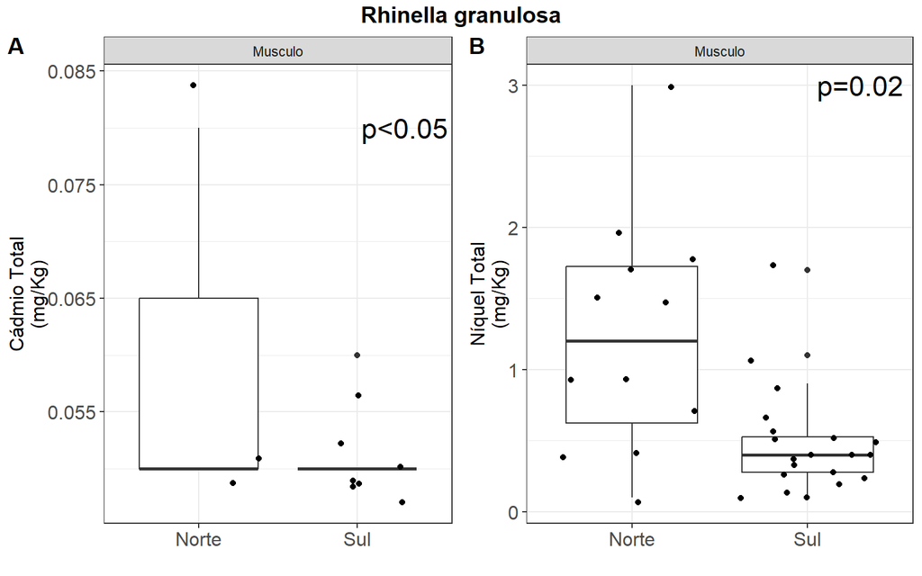

### 3.2. Campanha amostral

3.2.1. *Tropidurus torquatus*

3.2.1.2. Musculo

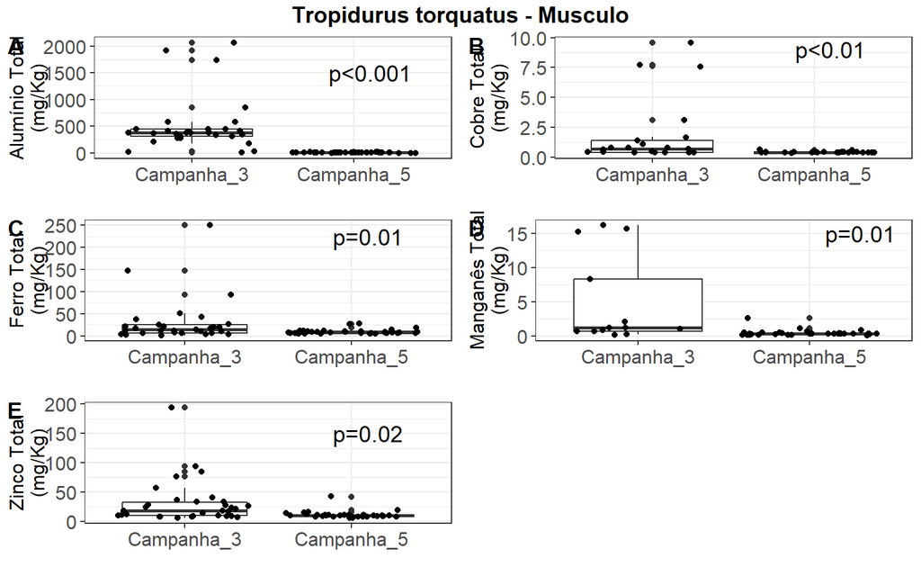

3.2.1.2. Figado

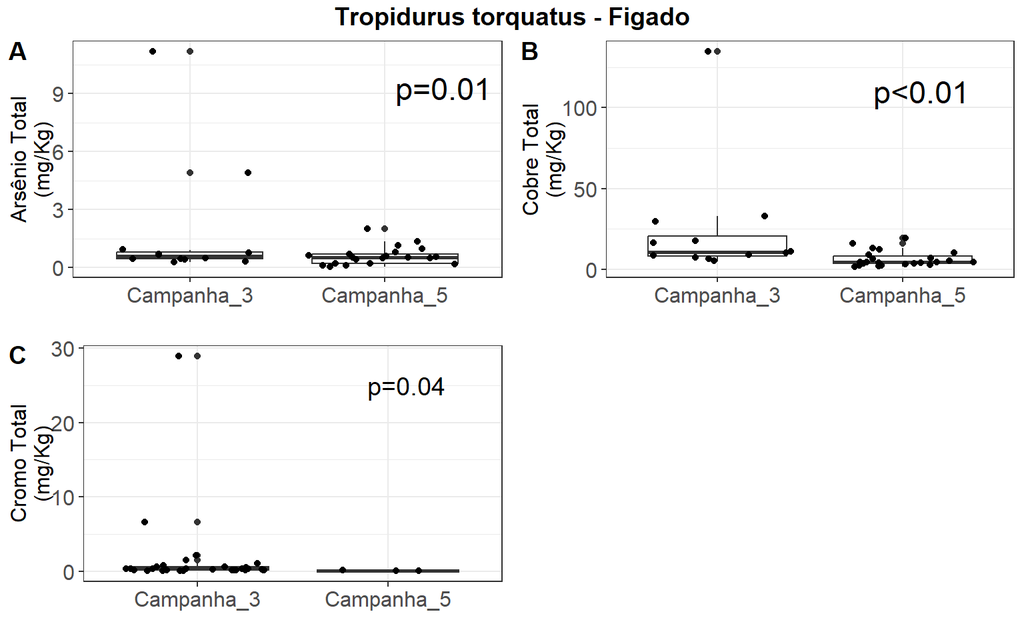

3.2.1.3. Interações

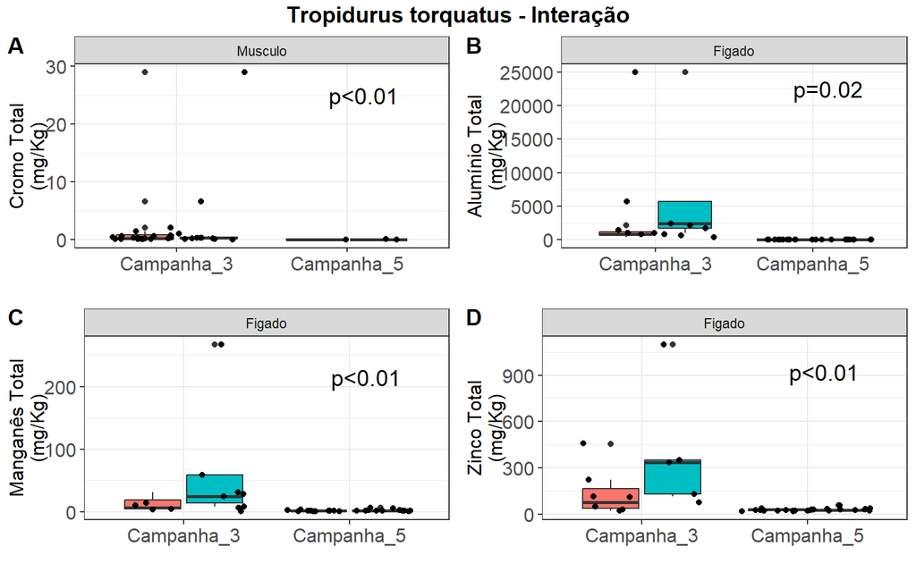

3.2.2. *Rhinella granulosa*

3.2.2.1. Musculo

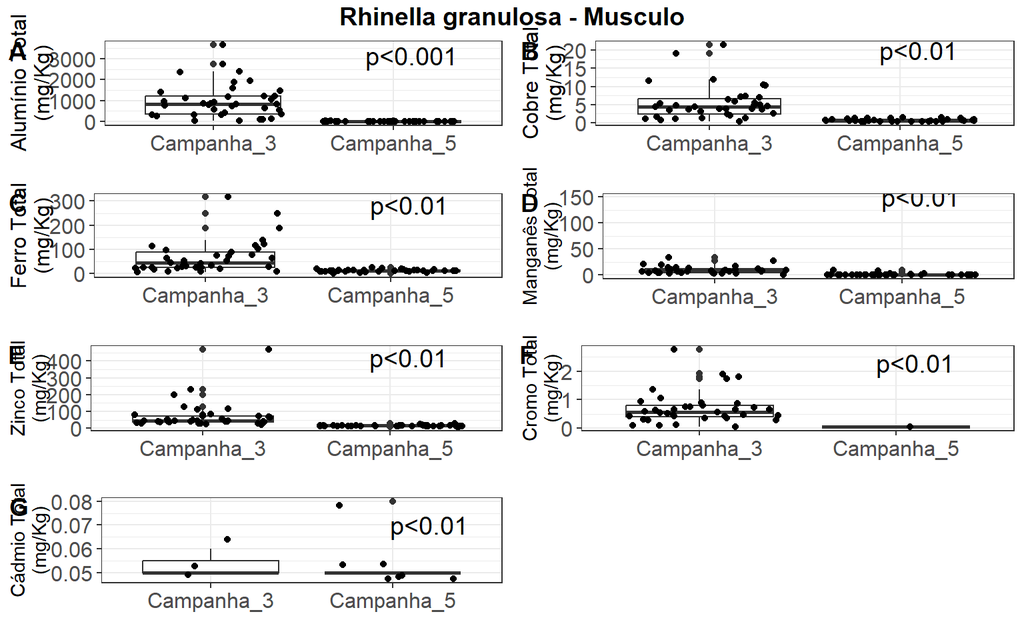

3.2.2.2. Figado

[figure not shown]

### 3.3. Distancia da Lama

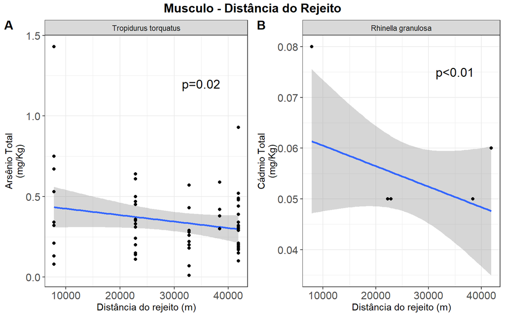

### 3.4. Distancia do Oceano

[figure not shown]

# Girinos

## Objetivo

- Apresentar os resultados obitidos da contaminação de metais em girinos.

## Dados coletados

| id_do_lote_de_campo | nome_do_sub_lote | sitio_amostral | id_oceanus | tipo_de_sitio_amostral | data_da_coleta | especie | no_de_individuos | finalidade_da_analise | biomassa_de_lote_g | responsavel_triagem_extracao | destino | local_de_armazenamento | data_transporte | observacao | unidade | aluminio_total | manganes_total | ferro_total | arsenio_total | zinco_total | cobre_total | cobalto_total | vanadio_total | niquel_total | cadmio_total | chumbo_total | cromo_total | campanha | desnivel_lama | … |
| --- | --- | --- | --- | --- | --- | --- | --- | --- | --- | --- | --- | --- | --- | --- | --- | --- | --- | --- | --- | --- | --- | --- | --- | --- | --- | --- | --- | --- | --- | --- |
| GIR070 | GIR070.5 | LRFG13 | 2707287 | Lagoa referência | 31/10/2023 | Boana faber | 2 | Contaminante | 2.8 | T. Kardush | Laboratório oceanus | Congelado -20ºC | 19/01/2023 | NA | mg/Kg | 140.3 | 10.2 | 83.6 | NA | 26 | NA | NA | NA | NA | NA | NA | NA | Campanha 5 | 0.1280120 | … |
| GIR071 | GIR071.1 | LRFG19 | 2707277 | Lagoa referência | 01/11/2023 | Boana albopunctata | 4 | Contaminante | 1.2 | T. Kardush | Laboratório oceanus | Congelado -20ºC | 19/01/2023 | NA | mg/Kg | 88.1 | 17.8 | 378 | NA | 10 | NA | NA | NA | NA | NA | NA | NA | Campanha 5 | 1.2801290 | … |
| GIR073 | GIR073.1 | LRFG16 | 2707202 | Lagoa referência | 01/11/2023 | Boana albopunctata | 2 | Contaminante | 1.7 | T. Kardush | Laboratório oceanus | Congelado -20ºC | 19/01/2023 | NA | mg/Kg | 72.6 | 1.6 | 155.9 | NA | 5 | NA | NA | NA | NA | NA | NA | NA | Campanha 5 | 3.2889484 | … |
| GIR076 | GIR076.1 | LRES01 | 2707223 | Lagoa alvo | 02/11/2023 | Boana crepitans | 5 | Contaminante | 1.8 | T. Kardush | Laboratório oceanus | Congelado -20ºC | 19/01/2023 | NA | mg/Kg | 81.8 | 5.8 | 234 | NA | 9 | 1.5 | NA | NA | NA | NA | NA | NA | Campanha 5 | -0.5219002 | … |
| GIR078 | GIR078.5 | LRES09 | 2707196 | Lagoa alvo | 03/11/2023 | Boana crepitans | 2 | Contaminante | 0.9 | T. Kardush | Laboratório oceanus | Congelado -20ºC | 19/01/2023 | NA | mg/Kg | 65.6 | 8.6 | 122.7 | 0.32 | 5 | NA | NA | NA | NA | NA | NA | NA | Campanha 5 | -0.3446514 | … |
| GIR081 | GIR081.1 | LRES05 | 2707229 | Lagoa alvo | 04/11/2023 | Boana crepitans | 4 | Contaminante | 2.2 | T. Kardush | Laboratório oceanus | Congelado -20ºC | 19/01/2023 | NA | mg/Kg | 49.7 | 1 | 129.5 | NA | 6 | NA | NA | NA | NA | NA | NA | NA | Campanha 5 | -0.2560270 | … |
| GIR085.1 | GIR085.1 | LRFG19 | 2707191 | Lagoa referência | 06/11/2023 | Boana faber | 1 | Contaminante | 2.4 | T. Kardush | Laboratório oceanus | Congelado -20ºC | 19/01/2023 | NA | mg/Kg | 127 | NA | 40.7 | 0.15 | 7 | NA | NA | NA | NA | NA | NA | NA | Campanha 5 | 1.2801290 | … |
| GIR085.3 | GIR085.3 | LRFG19 | 2707241 | Lagoa referência | 06/11/2023 | Boana albopunctata | 6 | Contaminante | 2.6 | T. Kardush | Laboratório oceanus | Congelado -20ºC | 19/01/2023 | NA | mg/Kg | 107.8 | 2.3 | 118.1 | 1.04 | 7 | 0.5 | NA | NA | NA | NA | NA | NA | Campanha 5 | 1.2801290 | … |
| GIR087 | GIR087.4 | LRFG11 | 2707218 | Lagoa referência | 07/11/2023 | Boana albopunctata | 2 | Contaminante | 0.8 | T. Kardush | Laboratório oceanus | Congelado -20ºC | 19/01/2023 | NA | mg/Kg | 16.1 | 1.8 | 35.1 | NA | 9 | NA | NA | NA | NA | NA | NA | NA | Campanha 5 | 2.4322460 | … |
| GIR104 | GIR104.1 | LRES09 | 2707275 | Lagoa alvo | 11/11/2023 | Boana crepitans | 6 | Contaminante | 2.7 | T. Kardush | Laboratório oceanus | Congelado -20ºC | 19/01/2023 | NA | mg/Kg | 1.5 | 2.9 | 47.7 | NA | 5 | NA | NA | 0.27 | NA | NA | NA | NA | Campanha 5 | -0.3446514 | … |
| GIR103 | GIR103.1 | LRES01 | 2707190 | Lagoa alvo | 12/11/2023 | Boana crepitans | 5 | Contaminante | 1.7 | T. Kardush | Laboratório oceanus | Congelado -20ºC | 19/01/2023 | NA | mg/Kg | 45.1 | 1.1 | 319.3 | 1.55 | 5 | NA | NA | NA | NA | NA | NA | NA | Campanha 5 | -0.5219002 | … |
| GIR111.1 | GIR111.1 | LRFG19 | 2707192 | Lagoa referência | 15/11/2023 | Boana albopunctata | 4 | Contaminante | 2.1 | T. Kardush | Laboratório oceanus | Congelado -20ºC | 19/01/2023 | NA | mg/Kg | 35.9 | 2.5 | 391.2 | 1.9 | 15 | 0.5 | NA | 0.44 | NA | NA | NA | NA | Campanha 5 | 1.2801290 | … |
| GIR111.4 | GIR111.4 | LRFG19 | 2707201 | Lagoa referência | 15/11/2023 | Boana faber | 2 | Contaminante | 6.3 | T. Kardush | Laboratório oceanus | Congelado -20ºC | 19/01/2023 | NA | mg/Kg | 1.9 | 0.5 | 87 | NA | 9 | NA | NA | NA | NA | NA | NA | NA | Campanha 5 | 1.2801290 | … |
| GIR130.1 | GIR130.1 | LRFG16 | 2707221 | Lagoa referência | 25/11/2023 | Boana faber | 5 | Contaminante | 23.5 | T. Kardush | Laboratório oceanus | Congelado -20ºC | 19/01/2023 | NA | mg/Kg | 10.9 | 1.4 | 28.4 | 1.89 | 5 | NA | NA | NA | NA | NA | NA | NA | Campanha 5 | 3.2889484 | … |
| GIR130.6 | GIR130.6 | LRFG16 | 2707237 | Lagoa referência | 25/11/2023 | Boana albopunctata | 2 | Contaminante | 1 | T. Kardush | Laboratório oceanus | Congelado -20ºC | 19/01/2023 | NA | mg/Kg | 52.8 | 1.2 | 130.5 | NA | 8 | NA | NA | NA | NA | NA | NA | NA | Campanha 5 | 3.2889484 | … |
| GIR132 | GIR132.1 | LRFG11 | 2707250 | Lagoa referência | 26/11/2023 | Boana albopunctata | 2 | Contaminante | 0.8 | T. Kardush | Laboratório oceanus | Congelado -20ºC | 19/01/2023 | NA | mg/Kg | 17.1 | 0.7 | 131.6 | NA | 9 | NA | NA | NA | NA | NA | NA | NA | Campanha 5 | 2.4322460 | … |
| GIR134 | GIR134.1 | LRES03 | 2707235 | Lagoa alvo | 27/11/2023 | Boana faber | 2 | Contaminante | 4.4 | T. Kardush | Laboratório oceanus | Congelado -20ºC | 19/01/2023 | NA | mg/Kg | 113.8 | 2.3 | 116 | 0.17 | 9 | NA | NA | NA | NA | NA | NA | NA | Campanha 5 | -0.4923587 | … |
| GIR143 | GIR143.1 | LRFG19 | 2707219 | Lagoa referência | 02/12/2023 | Boana faber | 1 | Contaminante | 3.2 | T. Kardush | Laboratório oceanus | Congelado -20ºC | 19/01/2023 | NA | mg/Kg | 199.2 | 3.7 | 272.5 | NA | 5 | NA | NA | 0.67 | NA | NA | NA | NA | Campanha 5 | 1.2801290 | … |
| GIR150 | GIR150.3 | LRFG16 | 2707211 | Lagoa referência | 06/12/2023 | Boana albopunctata | 3 | Contaminante | 1.2 | T. Kardush | Laboratório oceanus | Congelado -20ºC | 19/01/2023 | NA | mg/Kg | 18.7 | 3.9 | 227.7 | NA | 7 | 0.5 | NA | NA | NA | NA | NA | NA | Campanha 5 | 3.2889484 | … |
| GIR155 | GIR155.1 | LRFG18 | 2707236 | Lagoa referência | 10/12/2023 | Boana faber | 1 | Contaminante | 4 | T. Kardush | Laboratório oceanus | Congelado -20ºC | 19/01/2023 | NA | mg/Kg | 2.1 | 0.5 | 16 | NA | 6 | NA | NA | 0.05 | NA | NA | NA | NA | Campanha 5 | 3.2889484 | … |
| GIR156 | GIR156.15 | LRFG17 | 2707298 | Lagoa referência | 11/12/2023 | Boana crepitans | 6 | Contaminante | 2 | T. Kardush | Laboratório oceanus | Congelado -20ºC | 19/01/2023 | NA | mg/Kg | 25.3 | 4 | 98.5 | NA | 16 | NA | NA | NA | NA | NA | NA | NA | Campanha 5 | 1.0142558 | … |
| GIR173 | GIR173.1 | LRFG17 | 2796533 | Lagoa referência | 12/01/2024 | Boana faber | 1 | Contaminante | 2.4 | Juliana Reis | Laboratório oceanus | Congelado -20ºC | 05/04/2024 | NA | mg/Kg | 18.9 | 3.5 | 87.6 | NA | 6 | 0.5 | NA | 0.16 | NA | NA | NA | NA | Campanha 5 | 1.0142558 | … |
| GIR176 | GIR176.2 | LRFG12 | 2796506 | Lagoa referência | 14/01/2024 | Boana faber | 2 | Contaminante | 2 | Juliana Reis | Laboratório oceanus | Congelado -20ºC | 05/04/2024 | NA | mg/Kg | 88.6 | 10.2 | 145.1 | 0.09 | 9 | 1 | NA | NA | NA | 0.05 | 0.48 | NA | Campanha 5 | 1.0437973 | … |
| GIR181 | GIR181.1 | LRFG13 | 2796603 | Lagoa referência | 17/01/2024 | Boana faber | 1 | Contaminante | 1.7 | Juliana Reis | Laboratório oceanus | Congelado -20ºC | 05/04/2024 | NA | mg/Kg | 306.3 | 2.7 | 295.6 | 0.01 | 13 | 4.6 | NA | 0.24 | NA | 0.05 | 0.5 | 0.13 | Campanha 5 | 0.1280120 | … |
| GIR182 | GIR182.12 | LRES02 | 2796479 | Lagoa alvo | 17/01/2024 | Boana crepitans | 2 | Contaminante | 1.5 | Juliana Reis | Laboratório oceanus | Congelado -20ºC | 05/04/2024 | NA | mg/Kg | 1.8 | 18.7 | 41.1 | 0.02 | 7 | 0.6 | NA | NA | NA | NA | NA | NA | Campanha 5 | -0.3151100 | … |
| GIR188 | GIR188.1 | LRES05 | 2796585 | Lagoa alvo | 20/01/2024 | Boana faber | 2 | Contaminante | 3.55 | Juliana Reis | Laboratório oceanus | Congelado -20ºC | 05/04/2024 | NA | mg/Kg | 509.3 | 9.1 | 1121.6 | 0.2 | 9 | 1.5 | 0.22 | 0.45 | 0.2 | 0.05 | 0.46 | 0.16 | Campanha 5 | -0.2560270 | … |
| GIR204 | GIR204.3 | LRES01 | 2796632 | Lagoa alvo | 27/01/2024 | Boana faber | 1 | Contaminante | 2.11 | Juliana Reis | Laboratório oceanus | Congelado -20ºC | 05/04/2024 | NA | mg/Kg | 28.3 | 21.1 | 310.9 | 0.12 | 14 | 1.4 | NA | 0.1 | 0.8 | NA | 0.05 | NA | Campanha 5 | -0.5219002 | … |
| GIR214 | GIR214.1 | LRFG13 | 2796481 | Lagoa referência | 01/02/2024 | Boana faber | 1 | Contaminante | 2.47 | Juliana Reis | Laboratório oceanus | Congelado -20ºC | 05/04/2024 | NA | mg/Kg | NA | 0.2 | 31.4 | NA | 5 | NA | NA | NA | NA | NA | NA | NA | Campanha 5 | 0.1280120 | … |
| GIR214 | GIR214.4 | LRFG13 | 2796493 | Lagoa referência | 01/02/2024 | Boana albopunctata | 8 | Contaminante | 3.49 | Juliana Reis | Laboratório oceanus | Congelado -20ºC | 05/04/2024 | NA | mg/Kg | 138.3 | 2.4 | 454 | 0.18 | 9 | 0.6 | NA | 0.11 | 0.3 | 0.05 | NA | 0.24 | Campanha 5 | 0.1280120 | … |
| GIR216 | GIR216.2 | LRES02 | 2796534 | Lagoa alvo | 01/02/2024 | Boana crepitans | 2 | Contaminante | 1.68 | Juliana Reis | Laboratório oceanus | Congelado -20ºC | 05/04/2024 | NA | mg/Kg | 182.2 | 42.3 | 1088.8 | 0.04 | 8 | 1.9 | 0.05 | 0.56 | 0.2 | 0.05 | 0.35 | 0.82 | Campanha 5 | -0.3151100 | … |

[output cut: 969 more lines]

## Tabela de contaminantes

| tipo_de_sitio_amostral | especie | campanha | N_amostrado | peso_meang | Aluminio_mean | Aluminio_sd | Aluminio_n | Arsenio_mean | Arsenio_sd | Arsenio_n | Cadmio_mean | Cadmio_sd | Cadmio_n | Chumbo_mean | Chumbo_sd | Chumbo_n | cobalto_mean | cobalto_sd | cobalto_n | Cobre_mean | Cobre_sd | Cobre_n | Cromo_mean | Cromo_sd | Cromo_n | Ferro_mean | Ferro_sd | Ferro_n | Manganes_mean | … |
| --- | --- | --- | --- | --- | --- | --- | --- | --- | --- | --- | --- | --- | --- | --- | --- | --- | --- | --- | --- | --- | --- | --- | --- | --- | --- | --- | --- | --- | --- | --- |
| Lagoa alvo | Boana albopunctata | Campanha 3 | 16 | NA | 46.57500 | 6.379851 | 3 | 0.2600000 | NA | 1 | 0.0500 | NA | 1 | NaN | NA | 0 | 0.0500000 | 0.0000000 | 1 | 0.6250000 | 0.2500000 | 2 | 0.5475000 | 0.9551396 | 4 | 220.47500 | 43.68855 | 4 | 5.600000 | … |
| Lagoa alvo | Boana albopunctata | Campanha 5 | 5 | 1.155000 | 135.45000 | 43.487067 | 2 | 0.5400000 | NA | 1 | 0.0500 | 0.000 | 1 | 0.2350000 | 0.1767767 | 2 | NaN | NA | 0 | 0.8500000 | 0.3535534 | 2 | 0.0850000 | 0.0212132 | 2 | 835.90000 | 474.75149 | 2 | 27.950000 | … |
| Lagoa alvo | Boana crepitans | Campanha 3 | 64 | NA | 45.58000 | 26.321797 | 5 | 0.1425000 | 0.1040433 | 4 | 0.0900 | NA | 1 | NaN | NA | 0 | 0.0500000 | NA | 1 | 0.5000000 | 0.0000000 | 1 | 0.1940000 | 0.1254193 | 5 | 169.48000 | 141.90624 | 5 | 8.900000 | … |
| Lagoa alvo | Boana crepitans | Campanha 5 | 90 | 3.018571 | 71.10000 | 55.797615 | 14 | 0.3480000 | 0.4594393 | 10 | 0.0500 | 0.000 | 1 | 0.2057143 | 0.1209486 | 7 | 0.1033333 | 0.0838650 | 3 | 1.0900000 | 0.9445163 | 7 | 0.5866667 | 0.4660830 | 3 | 319.47857 | 275.15406 | 14 | 12.221429 | … |
| Lagoa alvo | Boana faber | Campanha 3 | 18 | NA | 38.96667 | 7.982690 | 3 | 0.1100000 | NA | 1 | NaN | NA | 0 | NaN | NA | 0 | 0.0500000 | NA | 1 | 0.5000000 | 0.0000000 | 1 | 0.1033333 | 0.0838650 | 3 | 108.66667 | 30.05501 | 3 | 6.033333 | … |
| Lagoa alvo | Boana faber | Campanha 5 | 18 | 4.706250 | 336.26250 | 474.124977 | 8 | 0.1525000 | 0.0394757 | 3 | 0.0500 | 0.000 | 1 | 0.3260000 | 0.3021258 | 5 | 0.1566667 | 0.1091177 | 5 | 1.5428571 | 0.8618916 | 6 | 0.7520000 | 0.7173353 | 5 | 619.43750 | 607.53595 | 8 | 19.000000 | … |
| Lagoa referência | Boana albopunctata | Campanha 3 | 51 | NA | 72.37500 | 79.208274 | 8 | 0.2012500 | 0.1120507 | 8 | 0.0675 | 0.015 | 3 | 0.1500000 | 0.1272792 | 2 | 0.0800000 | 0.0355903 | 3 | 0.7285714 | 0.5618846 | 3 | 0.8114286 | 0.9568251 | 6 | 157.27500 | 88.48031 | 8 | 1.500000 | … |
| Lagoa referência | Boana albopunctata | Campanha 5 | 48 | 1.709231 | 94.81538 | 89.103758 | 13 | 0.7900000 | 0.8620131 | 4 | 0.0500 | 0.000 | 1 | 0.1533333 | 0.0404145 | 3 | 0.1300000 | NA | 1 | 0.7142857 | 0.4375255 | 3 | 0.5100000 | 0.6207254 | 3 | 296.10000 | 212.13995 | 13 | 4.253846 | … |
| Lagoa referência | Boana crepitans | Campanha 3 | 39 | NA | 57.65000 | 41.595713 | 4 | 0.2833333 | 0.2138535 | 3 | NaN | NA | 0 | 0.1400000 | NA | 1 | 0.0500000 | NA | 1 | 0.8250000 | 0.2500000 | 4 | 0.1466667 | 0.0850490 | 3 | 110.52500 | 32.23470 | 4 | 2.550000 | … |
| Lagoa referência | Boana crepitans | Campanha 5 | 11 | 2.986667 | 114.33333 | 124.107870 | 3 | 0.2400000 | NA | 1 | 0.0500 | NA | 1 | 0.1900000 | 0.1414214 | 2 | 0.0500000 | NA | 1 | 1.0500000 | 0.6363961 | 2 | 0.1100000 | NA | 1 | 141.00000 | 37.78611 | 3 | 4.866667 | … |
| Lagoa referência | Boana faber | Campanha 3 | 19 | NA | 20.60000 | 13.356946 | 6 | 0.2925000 | 0.1855398 | 4 | 0.0500 | NA | 1 | NaN | NA | 0 | 0.0500000 | NA | 1 | 0.6000000 | 0.1732051 | 3 | 0.5850000 | 0.6323765 | 4 | 70.86667 | 52.88639 | 6 | 2.740000 | … |
| Lagoa referência | Boana faber | Campanha 5 | 41 | 5.869000 | 374.96842 | 1047.907388 | 19 | 0.3800000 | 0.5807538 | 8 | 0.0500 | 0.000 | 1 | 0.3680000 | 0.5385536 | 9 | 0.0600000 | NA | 1 | 1.8454545 | 2.2056127 | 8 | 0.7580000 | 0.8646791 | 5 | 303.04000 | 601.36255 | 20 | 4.642105 | … |

## Modelos

Todos os modelos seguiram a seguinte estrutura global:

> variavel resposta~ desnivel da lama + distancia da lama + tipo de sitio * campanha + (1| sitio amostral)

> Quando os modelos não atendiam aos pressupostos foi utilizada a transformaçãoem logaritimo

## 1. Contaminação *Boana faber*

**Dados**

| sitio_amostral | tipo_de_sitio_amostral | especie | no_de_individuos | biomassa_de_lote_g | aluminio_total | manganes_total | ferro_total | arsenio_total | zinco_total | cobre_total | cobalto_total | vanadio_total | niquel_total | cadmio_total | chumbo_total | cromo_total | campanha | desnível_lama | distância_lama |
| --- | --- | --- | --- | --- | --- | --- | --- | --- | --- | --- | --- | --- | --- | --- | --- | --- | --- | --- | --- |
| LRFG13 | Lagoa referência | Boana faber | 2 | 2.8 | 140.3 | 10.2 | 83.6 | NA | 26 | NA | NA | NA | NA | NA | NA | NA | Campanha 5 | 0.1280120 | -0.2229451 |
| LRFG19 | Lagoa referência | Boana faber | 1 | 2.4 | 127 | NA | 40.7 | 0.15 | 7 | NA | NA | NA | NA | NA | NA | NA | Campanha 5 | 1.2801290 | -0.1781652 |
| LRFG19 | Lagoa referência | Boana faber | 2 | 6.3 | 1.9 | 0.5 | 87 | NA | 9 | NA | NA | NA | NA | NA | NA | NA | Campanha 5 | 1.2801290 | -0.1781652 |
| LRFG16 | Lagoa referência | Boana faber | 5 | 23.5 | 10.9 | 1.4 | 28.4 | 1.89 | 5 | NA | NA | NA | NA | NA | NA | NA | Campanha 5 | 3.2889484 | -0.0168749 |
| LRES03 | Lagoa alvo | Boana faber | 2 | 4.4 | 113.8 | 2.3 | 116 | 0.17 | 9 | NA | NA | NA | NA | NA | NA | NA | Campanha 5 | -0.4923587 | -0.2990040 |
| LRFG19 | Lagoa referência | Boana faber | 1 | 3.2 | 199.2 | 3.7 | 272.5 | NA | 5 | NA | NA | 0.67 | NA | NA | NA | NA | Campanha 5 | 1.2801290 | -0.1781652 |
| LRFG18 | Lagoa referência | Boana faber | 1 | 4 | 2.1 | 0.5 | 16 | NA | 6 | NA | NA | 0.05 | NA | NA | NA | NA | Campanha 5 | 3.2889484 | -0.0411821 |
| LRFG17 | Lagoa referência | Boana faber | 1 | 2.4 | 18.9 | 3.5 | 87.6 | NA | 6 | 0.5 | NA | 0.16 | NA | NA | NA | NA | Campanha 5 | 1.0142558 | -0.1879962 |
| LRFG12 | Lagoa referência | Boana faber | 2 | 2 | 88.6 | 10.2 | 145.1 | 0.09 | 9 | 1 | NA | NA | NA | 0.05 | 0.48 | NA | Campanha 5 | 1.0437973 | 0.0799392 |
| LRFG13 | Lagoa referência | Boana faber | 1 | 1.7 | 306.3 | 2.7 | 295.6 | 0.01 | 13 | 4.6 | NA | 0.24 | NA | 0.05 | 0.5 | 0.13 | Campanha 5 | 0.1280120 | -0.2229451 |
| LRES05 | Lagoa alvo | Boana faber | 2 | 3.55 | 509.3 | 9.1 | 1121.6 | 0.2 | 9 | 1.5 | 0.22 | 0.45 | 0.2 | 0.05 | 0.46 | 0.16 | Campanha 5 | -0.2560270 | -0.2936641 |
| LRES01 | Lagoa alvo | Boana faber | 1 | 2.11 | 28.3 | 21.1 | 310.9 | 0.12 | 14 | 1.4 | NA | 0.1 | 0.8 | NA | 0.05 | NA | Campanha 5 | -0.5219002 | -0.2993127 |
| LRFG13 | Lagoa referência | Boana faber | 1 | 2.47 | NA | 0.2 | 31.4 | NA | 5 | NA | NA | NA | NA | NA | NA | NA | Campanha 5 | 0.1280120 | -0.2229451 |
| LRFG16 | Lagoa referência | Boana faber | 1 | 5.18 | 51.2 | 5.8 | 96.6 | NA | 17 | 0.5 | NA | 0.11 | 0.1 | 0.05 | 0.05 | NA | Campanha 5 | 3.2889484 | -0.0168749 |
| LRFG17 | Lagoa referência | Boana faber | 2 | 6.5 | 26.1 | 0.4 | 20.4 | NA | 5 | NA | NA | NA | 0.1 | NA | 0.17 | NA | Campanha 5 | 1.0142558 | -0.1879962 |
| LRFG16 | Lagoa referência | Boana faber | 2 | 7.44 | 19.2 | 6 | 107.7 | NA | 9 | 0.9 | 0.06 | NA | 0.2 | 0.05 | 0.23 | NA | Campanha 5 | 3.2889484 | -0.0168749 |
| LRES01 | Lagoa alvo | Boana faber | 1 | 1.68 | 44.1 | 65.6 | 497.5 | NA | 15 | 0.5 | 0.11 | 0.26 | 0.2 | NA | 0.08 | 1.95 | Campanha 5 | -0.5219002 | -0.2993127 |
| LRFG17 | Lagoa referência | Boana faber | 5 | 10.81 | 352 | 5.4 | 349.9 | 0.48 | 9 | 0.9 | NA | 0.38 | 0.1 | NA | NA | 0.45 | Campanha 5 | 1.0142558 | -0.1879962 |
| LRFG17 | Lagoa referência | Boana faber | 2 | 5.71 | 308.5 | 3.7 | 242 | NA | 10 | 0.6 | NA | 0.17 | 0.1 | NA | 0.08 | 0.09 | Campanha 5 | 1.0142558 | -0.1879962 |
| LRES05 | Lagoa alvo | Boana faber | 2 | 4.19 | 568.2 | 18.1 | 823.2 | 0.12 | 12 | 2.7 | 0.18 | 1.29 | 0.1 | 0.05 | 0.26 | 0.45 | Campanha 5 | -0.2560270 | -0.2936641 |
| LRFG12 | Lagoa referência | Boana faber | 1 | 1.86 | 759.1 | 4.4 | 1465.7 | 0.15 | 15 | 7.3 | NA | 1.08 | 0.2 | 0.05 | 0.15 | 0.94 | Campanha 5 | 1.0437973 | 0.0799392 |
| LRES05 | Lagoa alvo | Boana faber | 4 | 8.71 | 6.7 | 6.2 | 59.3 | NA | 9 | 1.2 | 0.05 | 0.1 | NA | 0.05 | NA | NA | Campanha 5 | -0.2560270 | -0.2936641 |
| LRFG17 | Lagoa referência | Boana faber | 2 | 4.36 | 4632.2 | 25.2 | 2476.4 | NA | 11 | 2.7 | NA | 3.09 | 0.3 | 0.05 | 1.83 | 2.18 | Campanha 5 | 1.0142558 | -0.1879962 |
| LRFG17 | Lagoa referência | Boana faber | 2 | 6.5 | 27.8 | 1 | 69.5 | 0.22 | 7 | 0.5 | NA | 0.22 | NA | NA | 0.05 | NA | Campanha 5 | 1.0142558 | -0.1879962 |
| LRFG16 | Lagoa referência | Boana faber | 2 | 7.44 | 0.9 | 0.9 | 54.1 | 0.19 | 5 | NA | NA | NA | NA | NA | NA | NA | Campanha 5 | 3.2889484 | -0.0168749 |
| LRFG17 | Lagoa referência | Boana faber | 5 | 10.81 | 52.2 | 2.5 | 90.6 | 0.24 | 8 | 0.8 | NA | 0.35 | NA | NA | 0.14 | NA | Campanha 5 | 1.0142558 | -0.1879962 |
| LRES05 | Lagoa alvo | Boana faber | 4 | 8.71 | 49.4 | 5.4 | 206.6 | NA | 15 | 0.8 | 0.05 | 0.14 | NA | NA | NA | 0.34 | Campanha 5 | -0.2560270 | -0.2936641 |
| LRES05 | Lagoa alvo | Boana faber | 2 | 4.3 | 1370.3 | 24.2 | 1820.4 | NA | 19 | 2.7 | 0.33 | 2.52 | 0.3 | 0.05 | 0.78 | 0.86 | Campanha 5 | -0.2560270 | -0.2936641 |
| LRES02 | Lagoa alvo | Boana faber | 14 | 15,3g | 30.6 | 6.7 | 138.4 | NA | 7 | 0.5 | NA | 0.16 | 0.1 | NA | NA | 0.06 | Campanha 3 | -0.3151100 | -0.2957663 |
| LRES08 | Lagoa alvo | Boana faber | 2 | 0,7g | 46.5 | 6.1 | 109.3 | 0.11 | 9 | 0.5 | 0.05 | 0.05 | 0.1 | NA | NA | 0.05 | Campanha 3 | -0.3151100 | -0.2960136 |
| LRES09 | Lagoa alvo | Boana faber | 2 | 1,6g | 39.8 | 5.3 | 78.3 | NA | 12 | 0.5 | NA | 0.18 | 0.1 | NA | NA | 0.2 | Campanha 3 | -0.3446514 | -0.3008163 |
| LRFG11 | Lagoa referência | Boana faber | 2 | 3,6g | 13.1 | 2.3 | 159.8 | 0.21 | 12 | 0.9 | NA | NA | 0.1 | NA | NA | 0.35 | Campanha 3 | 2.4322460 | 0.0300775 |
| LRFG12 | Lagoa referência | Boana faber | 4 | 3,9g | 23.4 | 2.1 | 54.9 | NA | 9 | 0.5 | NA | 0.05 | 0.1 | 0.05 | NA | 1.5 | Campanha 3 | 1.0437973 | 0.0799392 |
| LRFG13 | Lagoa referência | Boana faber | 1 | 1g | 14.5 | 2.9 | 38.8 | 0.07 | 9 | 0.5 | NA | 0.09 | 0.1 | NA | NA | 0.44 | Campanha 3 | 0.1280120 | -0.2229451 |
| LRFG16 | Lagoa referência | Boana faber | 2 | 5,8g | 18.5 | 1.3 | 49.3 | NA | 8 | 0.5 | NA | 0.06 | 0.1 | NA | NA | 0.05 | Campanha 3 | 3.2889484 | -0.0168749 |
| LRFG17 | Lagoa referência | Boana faber | 2 | 4,5g | 8.3 | NA | 15.7 | 0.43 | 5 | NA | NA | NA | NA | NA | NA | NA | Campanha 3 | 1.0142558 | -0.1879962 |
| LRFG19 | Lagoa referência | Boana faber | 8 | 4g | 45.8 | 5.1 | 106.7 | 0.46 | 9 | 0.6 | 0.05 | NA | NA | NA | NA | NA | Campanha 3 | 1.2801290 | -0.1781652 |

### 1.1. Aluminio

- Simplificação do modelo global

|  | df | AIC | Modelo |
| --- | --- | --- | --- |
| mod_al | 8 | 141.8998 | Global |
| mod_2 | 7 | 142.4264 | removendo a interação |

- Resultado

```
## Analysis of Deviance Table (Type II Wald chisquare tests)
##
## Response: aluminio_total
##                                  Chisq Df Pr(>Chisq)
## desnível_lama                   7.3471  1   0.006717 **
## distância_lama                  0.6607  1   0.416298
## tipo_de_sitio_amostral          0.6159  1   0.432586
## campanha                        3.2621  1   0.070898 .
## tipo_de_sitio_amostral:campanha 0.0385  1   0.844468
## ---
## Signif. codes:  0 '***' 0.001 '**' 0.01 '*' 0.05 '.' 0.1 ' ' 1
```

| contrast | campanha | estimate | SE | df | t.ratio | p.value |
| --- | --- | --- | --- | --- | --- | --- |
| Lagoa alvo - Lagoa referência | Campanha 3 | -0.5043228 | 1.432941 | 14.852464 | -0.3519495 | 0.7298199 |
| Lagoa alvo - Lagoa referência | Campanha 5 | -0.7779509 | 1.110667 | 2.862889 | -0.7004356 | 0.5362967 |

| contrast | tipo_de_sitio_amostral | estimate | SE | df | t.ratio | p.value |
| --- | --- | --- | --- | --- | --- | --- |
| Campanha 3 - Campanha 5 | Lagoa alvo | -1.000363 | 1.1713062 | 17.01212 | -0.8540573 | 0.4049395 |
| Campanha 3 - Campanha 5 | Lagoa referência | -1.273991 | 0.8257891 | 28.01012 | -1.5427554 | 0.1341137 |

### 1.2. Arsenio

- Simplificação do modelo global

[output not shown]

- Resultado

```
## Analysis of Deviance Table (Type II Wald chisquare tests)
##
## Response: arsenio_total
##                                  Chisq Df Pr(>Chisq)
## desnível_lama                   4.6101  1    0.03179 *
## distância_lama                  0.1999  1    0.65476
## tipo_de_sitio_amostral          1.2631  1    0.26106
## campanha                        1.2285  1    0.26769
## tipo_de_sitio_amostral:campanha 0.7213  1    0.39571
## ---
## Signif. codes:  0 '***' 0.001 '**' 0.01 '*' 0.05 '.' 0.1 ' ' 1
```

| contrast | campanha | estimate | SE | df | t.ratio | p.value |
| --- | --- | --- | --- | --- | --- | --- |
| Lagoa alvo - Lagoa referência | Campanha 3 | 0.2668911 | 1.2915614 | 6.011576 | 0.2066422 | 0.8431106 |
| Lagoa alvo - Lagoa referência | Campanha 5 | 1.3174697 | 0.9907197 | 4.598530 | 1.3298108 | 0.2457166 |

| contrast | tipo_de_sitio_amostral | estimate | SE | df | t.ratio | p.value |
| --- | --- | --- | --- | --- | --- | --- |
| Campanha 3 - Campanha 5 | Lagoa alvo | -0.3700832 | 1.1348291 | 6.980024 | -0.3261136 | 0.7538979 |
| Campanha 3 - Campanha 5 | Lagoa referência | 0.6804955 | 0.5456787 | 10.040579 | 1.2470626 | 0.2406794 |

### 1.3. Chumbo

- Simplificação do modelo global

[output not shown]

- Resultado

```
## Analysis of Deviance Table (Type II Wald chisquare tests)
##
## Response: chumbo_total
##                         Chisq Df Pr(>Chisq)
## desnível_lama          0.4312  1     0.5114
## distância_lama         0.0113  1     0.9152
## tipo_de_sitio_amostral 0.2139  1     0.6437
```

| contrast | estimate | SE | df | t.ratio | p.value |
| --- | --- | --- | --- | --- | --- |
| Lagoa alvo - Lagoa referência | -0.6835274 | 1.585805 | 2.021167 | -0.4310286 | 0.7080686 |

### 1.4. Cadmio

[output not shown]

| contrast | campanha | estimate | SE | df | t.ratio | p.value |
| --- | --- | --- | --- | --- | --- | --- |
| Lagoa alvo - Lagoa referência | Campanha 3 | NA | NA | NA | NA | NA |
| Lagoa alvo - Lagoa referência | Campanha 5 | 0 | 0 | 0.3920333 | 1.7386 | 0.5289549 |

| contrast | tipo_de_sitio_amostral | estimate | SE | df | t.ratio | p.value |
| --- | --- | --- | --- | --- | --- | --- |
| Campanha 3 - Campanha 5 | Lagoa alvo | NA | NA | NA | NA | NA |
| Campanha 3 - Campanha 5 | Lagoa referência | 0 | 0 | 5.008794 | -0.4135474 | 0.696316 |

### 1.5. Cobalto

- Simplificação do modelo global

[output not shown]

- Resultado

```
## Analysis of Deviance Table (Type II Wald chisquare tests)
##
## Response: as.numeric(cobalto_total)
##                                  Chisq Df Pr(>Chisq)
## desnível_lama                   0.0166  1     0.8974
## distância_lama                  0.0317  1     0.8588
## tipo_de_sitio_amostral          0.0230  1     0.8795
## campanha                        0.5351  1     0.4645
## tipo_de_sitio_amostral:campanha         0
```

| contrast | campanha | estimate | SE | df | z.ratio | p.value |
| --- | --- | --- | --- | --- | --- | --- |
| Lagoa alvo - Lagoa referência | Campanha 3 | NA | NA | NA | NA | NA |
| Lagoa alvo - Lagoa referência | Campanha 5 | NA | NA | NA | NA | NA |

| contrast | tipo_de_sitio_amostral | estimate | SE | df | z.ratio | p.value |
| --- | --- | --- | --- | --- | --- | --- |
| Campanha 3 - Campanha 5 | Lagoa alvo | NA | NA | NA | NA | NA |
| Campanha 3 - Campanha 5 | Lagoa referência | NA | NA | NA | NA | NA |

### 1.6. Cobre

- Simplificação do modelo global

|  | df | AIC | Modelo |
| --- | --- | --- | --- |
| mod | 8 | 66.07552 | Global |
| mod_2 | 7 | 142.42644 | removendo a interação |

- Resultado

```
## Analysis of Deviance Table (Type II Wald chisquare tests)
##
## Response: as.numeric(cobre_total)
##                                  Chisq Df Pr(>Chisq)
## desnível_lama                   2.3595  1   0.124519
## distância_lama                  1.8369  1   0.175313
## tipo_de_sitio_amostral          0.0171  1   0.896007
## campanha                        7.4890  1   0.006208 **
## tipo_de_sitio_amostral:campanha 0.0543  1   0.815723
## ---
## Signif. codes:  0 '***' 0.001 '**' 0.01 '*' 0.05 '.' 0.1 ' ' 1
```

| contrast | campanha | estimate | SE | df | t.ratio | p.value |
| --- | --- | --- | --- | --- | --- | --- |
| Lagoa alvo - Lagoa referência | Campanha 3 | -0.1709592 | 0.6894425 | 8.130668 | -0.2479673 | 0.8103075 |
| Lagoa alvo - Lagoa referência | Campanha 5 | -0.0219793 | 0.6326659 | 1.748307 | -0.0347407 | 0.9758367 |

| contrast | tipo_de_sitio_amostral | estimate | SE | df | t.ratio | p.value |
| --- | --- | --- | --- | --- | --- | --- |
| Campanha 3 - Campanha 5 | Lagoa alvo | -0.9380338 | 0.529350 | 5.465214 | -1.772048 | 0.1315851 |
| Campanha 3 - Campanha 5 | Lagoa referência | -0.7890539 | 0.457359 | 16.885915 | -1.725240 | 0.1027369 |

### 1.7. Cromo

- Simplificação do modelo global

|  | df | AIC | Modelo |
| --- | --- | --- | --- |
| mod | 8 | 53.63441 | Global |
| mod_2 | 7 | 142.42644 | removendo a interação |

- Resultado

```
## Analysis of Deviance Table (Type II Wald chisquare tests)
##
## Response: as.numeric(cromo_total)
##                                  Chisq Df Pr(>Chisq)
## desnível_lama                   3.8570  1    0.04954 *
## distância_lama                  2.3565  1    0.12476
## tipo_de_sitio_amostral          0.0420  1    0.83763
## campanha                        2.0506  1    0.15214
## tipo_de_sitio_amostral:campanha 3.0653  1    0.07998 .
## ---
## Signif. codes:  0 '***' 0.001 '**' 0.01 '*' 0.05 '.' 0.1 ' ' 1
```

| contrast | campanha | estimate | SE | df | t.ratio | p.value |
| --- | --- | --- | --- | --- | --- | --- |
| Lagoa alvo - Lagoa referência | Campanha 3 | -1.8131906 | 1.488113 | 5.814255 | -1.2184494 | 0.2701730 |
| Lagoa alvo - Lagoa referência | Campanha 5 | 0.2874116 | 1.116641 | 1.655449 | 0.2573896 | 0.8252516 |

| contrast | tipo_de_sitio_amostral | estimate | SE | df | t.ratio | p.value |
| --- | --- | --- | --- | --- | --- | --- |
| Campanha 3 - Campanha 5 | Lagoa alvo | -1.9402820 | 0.9593316 | 2.871729 | -2.0225353 | 0.1403924 |
| Campanha 3 - Campanha 5 | Lagoa referência | 0.1603203 | 1.1109554 | 10.942312 | 0.1443085 | 0.8878804 |

### 1.8. Ferro

- Simplificação do modelo global

|  | df | AIC | Modelo |
| --- | --- | --- | --- |
| mod | 8 | 121.7403 | Global |
| mod_2 | 7 | 142.4264 | removendo a interação |

- Resultado

```
## Analysis of Deviance Table (Type II Wald chisquare tests)
##
## Response: as.numeric(ferro_total)
##                                  Chisq Df Pr(>Chisq)
## desnível_lama                   3.4540  1    0.06310 .
## distância_lama                  2.4752  1    0.11566
## tipo_de_sitio_amostral          2.5498  1    0.11031
## campanha                        4.9700  1    0.02579 *
## tipo_de_sitio_amostral:campanha 0.1582  1    0.69081
## ---
## Signif. codes:  0 '***' 0.001 '**' 0.01 '*' 0.05 '.' 0.1 ' ' 1
```

| contrast | campanha | estimate | SE | df | t.ratio | p.value |
| --- | --- | --- | --- | --- | --- | --- |
| Lagoa alvo - Lagoa referência | Campanha 3 | 0.6609549 | 0.9521417 | 16.534048 | 0.694177 | 0.4972098 |
| Lagoa alvo - Lagoa referência | Campanha 5 | 1.0360781 | 0.6967990 | 3.191322 | 1.486911 | 0.2284559 |

| contrast | tipo_de_sitio_amostral | estimate | SE | df | t.ratio | p.value |
| --- | --- | --- | --- | --- | --- | --- |
| Campanha 3 - Campanha 5 | Lagoa alvo | -1.2375016 | 0.7905561 | 18.47724 | -1.565356 | 0.1344652 |
| Campanha 3 - Campanha 5 | Lagoa referência | -0.8623784 | 0.5514396 | 28.61260 | -1.563868 | 0.1288428 |

### 1.9. Manganes

- Simplificação do modelo global

|  | df | AIC | Modelo |
| --- | --- | --- | --- |
| mod | 8 | 114.1227 | Global |
| mod_2 | 7 | 142.4264 | removendo a interação |

- Resultado

```
## Analysis of Deviance Table (Type II Wald chisquare tests)
##
## Response: as.numeric(manganes_total)
##                                  Chisq Df Pr(>Chisq)
## desnível_lama                   1.2656  1     0.2606
## distância_lama                  0.9490  1     0.3300
## tipo_de_sitio_amostral          5.5104  1     0.0189 *
## campanha                        0.4476  1     0.5035
## tipo_de_sitio_amostral:campanha 0.3801  1     0.5375
## ---
## Signif. codes:  0 '***' 0.001 '**' 0.01 '*' 0.05 '.' 0.1 ' ' 1
```

| contrast | campanha | estimate | SE | df | t.ratio | p.value |
| --- | --- | --- | --- | --- | --- | --- |
| Lagoa alvo - Lagoa referência | Campanha 3 | 0.9432863 | 0.9768931 | 16.22257 | 0.9655983 | 0.3484203 |
| Lagoa alvo - Lagoa referência | Campanha 5 | 1.5316693 | 0.7015359 | 2.63613 | 2.1833086 | 0.1292925 |

| contrast | tipo_de_sitio_amostral | estimate | SE | df | t.ratio | p.value |
| --- | --- | --- | --- | --- | --- | --- |
| Campanha 3 - Campanha 5 | Lagoa alvo | -0.6781731 | 0.7812565 | 15.58633 | -0.8680543 | 0.3985333 |
| Campanha 3 - Campanha 5 | Lagoa referência | -0.0897900 | 0.6293969 | 28.98432 | -0.1426604 | 0.8875455 |

### 1.10. Niquel

- Simplificação do modelo global

|  | df | AIC | Modelo |
| --- | --- | --- | --- |
| mod | 8 | 42.14397 | Global |
| mod_2 | 7 | 142.42644 | removendo a interação |

- Resultado

```
## Analysis of Deviance Table (Type II Wald chisquare tests)
##
## Response: as.numeric(niquel_total)
##                                  Chisq Df Pr(>Chisq)
## desnível_lama                   0.1926  1    0.66076
## distância_lama                  0.3640  1    0.54630
## tipo_de_sitio_amostral          1.2443  1    0.26463
## campanha                        6.3526  1    0.01172 *
## tipo_de_sitio_amostral:campanha 0.9045  1    0.34158
## ---
## Signif. codes:  0 '***' 0.001 '**' 0.01 '*' 0.05 '.' 0.1 ' ' 1
```

| contrast | campanha | estimate | SE | df | t.ratio | p.value |
| --- | --- | --- | --- | --- | --- | --- |
| Lagoa alvo - Lagoa referência | Campanha 3 | 0.1199828 | 0.5929348 | 6.046132 | 0.2023541 | 0.8462774 |
| Lagoa alvo - Lagoa referência | Campanha 5 | 0.6080724 | 0.5671679 | 1.118681 | 1.0721206 | 0.4625104 |

| contrast | tipo_de_sitio_amostral | estimate | SE | df | t.ratio | p.value |
| --- | --- | --- | --- | --- | --- | --- |
| Campanha 3 - Campanha 5 | Lagoa alvo | -0.9085109 | 0.3884312 | 4.267617 | -2.338924 | 0.0753776 |
| Campanha 3 - Campanha 5 | Lagoa referência | -0.4204212 | 0.4054049 | 11.425142 | -1.037040 | 0.3211679 |

### 1.11. Vanadio

- Simplificação do modelo global

|  | df | AIC | Modelo |
| --- | --- | --- | --- |
| mod | 8 | 76.93101 | Global |
| mod_2 | 7 | 142.42644 | removendo a interação |

- Resultado

  ```
  ## Analysis of Deviance Table (Type II Wald chisquare tests)
  ##
  ## Response: as.numeric(vanadio_total)
  ##                                  Chisq Df Pr(>Chisq)
  ## desnível_lama                   2.0793  1    0.14931
  ## distância_lama                  0.1785  1    0.67267
  ## tipo_de_sitio_amostral          0.2989  1    0.58457
  ## campanha                        6.5859  1    0.01028 *
  ## tipo_de_sitio_amostral:campanha 0.2478  1    0.61860
  ## ---
  ## Signif. codes:  0 '***' 0.001 '**' 0.01 '*' 0.05 '.' 0.1 ' ' 1
  ```

| contrast | campanha | estimate | SE | df | t.ratio | p.value |
| --- | --- | --- | --- | --- | --- | --- |
| Lagoa alvo - Lagoa referência | Campanha 3 | 0.0438978 | 1.1636474 | 11.730076 | 0.0377243 | 0.9705419 |
| Lagoa alvo - Lagoa referência | Campanha 5 | -0.4859839 | 0.9481581 | 1.362731 | -0.5125557 | 0.6789359 |

| contrast | tipo_de_sitio_amostral | estimate | SE | df | t.ratio | p.value |
| --- | --- | --- | --- | --- | --- | --- |
| Campanha 3 - Campanha 5 | Lagoa alvo | -1.097575 | 0.7978209 | 5.667915 | -1.375716 | 0.2207958 |
| Campanha 3 - Campanha 5 | Lagoa referência | -1.627456 | 0.8988175 | 17.525184 | -1.810664 | 0.0873713 |

### 1.12. Zinco

- Simplificação do modelo global

|  | df | AIC | Modelo |
| --- | --- | --- | --- |
| mod | 8 | 55.22241 | Global |
| mod_2 | 7 | 142.42644 | removendo a interação |

- Resultado

```
## Analysis of Deviance Table (Type II Wald chisquare tests)
##
## Response: as.numeric(zinco_total)
##                                  Chisq Df Pr(>Chisq)
## desnível_lama                   2.8414  1    0.09186 .
## distância_lama                  2.3071  1    0.12879
## tipo_de_sitio_amostral          2.0709  1    0.15013
## campanha                        0.7146  1    0.39790
## tipo_de_sitio_amostral:campanha 0.5872  1    0.44351
## ---
## Signif. codes:  0 '***' 0.001 '**' 0.01 '*' 0.05 '.' 0.1 ' ' 1
```

| contrast | campanha | estimate | SE | df | t.ratio | p.value |
| --- | --- | --- | --- | --- | --- | --- |
| Lagoa alvo - Lagoa referência | Campanha 3 | 0.1028472 | 0.3256572 | 16.534048 | 0.3158141 | 0.7560952 |
| Lagoa alvo - Lagoa referência | Campanha 5 | 0.3500170 | 0.2383234 | 3.191322 | 1.4686643 | 0.2329756 |

| contrast | tipo_de_sitio_amostral | estimate | SE | df | t.ratio | p.value |
| --- | --- | --- | --- | --- | --- | --- |
| Campanha 3 - Campanha 5 | Lagoa alvo | -0.2935951 | 0.2703908 | 18.47724 | -1.0858177 | 0.2915232 |
| Campanha 3 - Campanha 5 | Lagoa referência | -0.0464252 | 0.1886067 | 28.61260 | -0.2461482 | 0.8073248 |

## 2. Contaminação *Boana albopunctata*

**Dados**

| sitio_amostral | tipo_de_sitio_amostral | especie | no_de_individuos | biomassa_de_lote_g | aluminio_total | manganes_total | ferro_total | arsenio_total | zinco_total | cobre_total | cobalto_total | vanadio_total | niquel_total | cadmio_total | chumbo_total | cromo_total | campanha | desnível_lama | distância_lama |
| --- | --- | --- | --- | --- | --- | --- | --- | --- | --- | --- | --- | --- | --- | --- | --- | --- | --- | --- | --- |
| LRFG19 | Lagoa referência | Boana albopunctata | 4 | 1.2 | 88.1 | 17.8 | 378 | NA | 10 | NA | NA | NA | NA | NA | NA | NA | Campanha 5 | 1.2801290 | -0.1781652 |
| LRFG16 | Lagoa referência | Boana albopunctata | 2 | 1.7 | 72.6 | 1.6 | 155.9 | NA | 5 | NA | NA | NA | NA | NA | NA | NA | Campanha 5 | 3.2889484 | -0.0168749 |
| LRFG19 | Lagoa referência | Boana albopunctata | 6 | 2.6 | 107.8 | 2.3 | 118.1 | 1.04 | 7 | 0.5 | NA | NA | NA | NA | NA | NA | Campanha 5 | 1.2801290 | -0.1781652 |
| LRFG11 | Lagoa referência | Boana albopunctata | 2 | 0.8 | 16.1 | 1.8 | 35.1 | NA | 9 | NA | NA | NA | NA | NA | NA | NA | Campanha 5 | 2.4322460 | 0.0300775 |
| LRFG19 | Lagoa referência | Boana albopunctata | 4 | 2.1 | 35.9 | 2.5 | 391.2 | 1.9 | 15 | 0.5 | NA | 0.44 | NA | NA | NA | NA | Campanha 5 | 1.2801290 | -0.1781652 |
| LRFG16 | Lagoa referência | Boana albopunctata | 2 | 1 | 52.8 | 1.2 | 130.5 | NA | 8 | NA | NA | NA | NA | NA | NA | NA | Campanha 5 | 3.2889484 | -0.0168749 |
| LRFG11 | Lagoa referência | Boana albopunctata | 2 | 0.8 | 17.1 | 0.7 | 131.6 | NA | 9 | NA | NA | NA | NA | NA | NA | NA | Campanha 5 | 2.4322460 | 0.0300775 |
| LRFG16 | Lagoa referência | Boana albopunctata | 3 | 1.2 | 18.7 | 3.9 | 227.7 | NA | 7 | 0.5 | NA | NA | NA | NA | NA | NA | Campanha 5 | 3.2889484 | -0.0168749 |
| LRFG13 | Lagoa referência | Boana albopunctata | 8 | 3.49 | 138.3 | 2.4 | 454 | 0.18 | 9 | 0.6 | NA | 0.11 | 0.3 | 0.05 | NA | 0.24 | Campanha 5 | 0.1280120 | -0.2229451 |
| LRFG16 | Lagoa referência | Boana albopunctata | 2 | 1.1 | 241 | 5 | 332.5 | NA | 7 | 0.6 | NA | NA | NA | 0.05 | 0.11 | NA | Campanha 5 | 3.2889484 | -0.0168749 |
| LRFG13 | Lagoa referência | Boana albopunctata | 6 | 2.68 | 27.5 | 2 | 218.1 | NA | 6 | NA | NA | NA | NA | NA | NA | NA | Campanha 5 | 0.1280120 | -0.2229451 |
| LRES01 | Lagoa alvo | Boana albopunctata | 3 | 1.17 | 104.7 | 51.9 | 1171.6 | NA | 6 | 0.6 | NA | 0.34 | 0.4 | 0.05 | 0.11 | 0.07 | Campanha 5 | -0.5219002 | -0.2993127 |
| LRFG19 | Lagoa referência | Boana albopunctata | 3 | 1.47 | 114.2 | 11.8 | 837.2 | NA | 8 | 0.6 | 0.13 | 0.48 | 0.6 | NA | 0.16 | 0.07 | Campanha 5 | 1.2801290 | -0.1781652 |
| LRFG13 | Lagoa referência | Boana albopunctata | 4 | 2.08 | 302.5 | 2.3 | 439.4 | 0.04 | 8 | 1.7 | NA | 0.28 | NA | 0.05 | 0.19 | 1.22 | Campanha 5 | 0.1280120 | -0.2229451 |
| LRES05 | Lagoa alvo | Boana albopunctata | 2 | 1.14 | 166.2 | 4 | 500.2 | 0.54 | 9 | 1.1 | NA | 0.19 | 0.1 | 0.05 | 0.36 | 0.1 | Campanha 5 | -0.2560270 | -0.2936641 |
| LRES01 | Lagoa alvo | Boana albopunctata | 8 | 2,4g | 47.7 | 11.9 | 230.3 | NA | 8 | 0.5 | 0.05 | 0.09 | 0.2 | 0.05 | NA | 1.98 | Campanha 3 | -0.5219002 | -0.2993127 |
| LRES05 | Lagoa alvo | Boana albopunctata | 2 | 0,7g | 47.7 | 2.4 | 157.6 | 0.26 | 8 | 1 | NA | NA | NA | NA | NA | 0.05 | Campanha 3 | -0.2560270 | -0.2936641 |
| LRES08 | Lagoa alvo | Boana albopunctata | 3 | 0,8g | 37.8 | 2.3 | 235.4 | NA | 8 | 0.5 | 0.05 | NA | NA | NA | NA | 0.07 | Campanha 3 | -0.3151100 | -0.2960136 |
| LRES09 | Lagoa alvo | Boana albopunctata | 3 | 4,6g | 53.1 | 5.8 | 258.6 | NA | 8 | 0.5 | NA | NA | 0.1 | NA | NA | 0.09 | Campanha 3 | -0.3446514 | -0.3008163 |
| LRFG11 | Lagoa referência | Boana albopunctata | 7 | 1,6g | 58.1 | 1 | 213.6 | 0.12 | 8 | 0.5 | 0.05 | 0.19 | 0.2 | 0.05 | 0.24 | 0.16 | Campanha 3 | 2.4322460 | 0.0300775 |
| LRFG12 | Lagoa referência | Boana albopunctata | 3 | 0,7g | 57.7 | 1.2 | 115.5 | 0.35 | 9 | 0.6 | 0.12 | 0.15 | 0.1 | 0.08 | NA | 1.01 | Campanha 3 | 1.0437973 | 0.0799392 |
| LRFG13 | Lagoa referência | Boana albopunctata | 9 | 3,3g | 31.9 | 1.6 | 114.4 | 0.17 | 8 | 2 | NA | 0.1 | NA | NA | NA | 0.11 | Campanha 3 | 0.1280120 | -0.2229451 |
| LRFG14 | Lagoa referência | Boana albopunctata | 1 | 0,3g | 15.4 | 1.6 | 48.1 | 0.11 | 5 | NA | NA | 0.05 | 0.1 | NA | NA | NA | Campanha 3 | 2.0482070 | 0.0400975 |
| LRFG15 | Lagoa referência | Boana albopunctata | 7 | 2,3g | 258.5 | 2.3 | 246.3 | 0.14 | 7 | 0.5 | NA | 0.33 | 0.2 | NA | NA | 0.16 | Campanha 3 | 0.1870949 | -0.2257869 |
| LRFG16 | Lagoa referência | Boana albopunctata | 9 | 2,5g | 15.1 | 1.8 | 59 | 0.36 | 7 | 0.5 | NA | NA | NA | NA | NA | 0.05 | Campanha 3 | 3.2889484 | -0.0168749 |
| LRFG18 | Lagoa referência | Boana albopunctata | 6 | 1,3g | 89.7 | 0.9 | 293 | 0.08 | 9 | 0.5 | 0.05 | 0.2 | 0.1 | 0.08 | 0.06 | 1.75 | Campanha 3 | 3.2889484 | -0.0411821 |
| LRFG19 | Lagoa referência | Boana albopunctata | 9 | 3,3g | 52.6 | 1.6 | 168.3 | 0.28 | 9 | 0.5 | 0.1 | 0.17 | 0.1 | 0.06 | NA | 2.44 | Campanha 3 | 1.2801290 | -0.1781652 |

### 2.1. Aluminio

- Simplificação do modelo global

|  | df | AIC | Modelo |
| --- | --- | --- | --- |
| mod_al | 8 | 75.33022 | Global |
| mod_2 | 7 | 76.19539 | removendo a interação |

- Resultado

```
## Analysis of Deviance Table (Type II Wald chisquare tests)
##
## Response: as.numeric(aluminio_total)
##                                  Chisq Df Pr(>Chisq)
## desnível_lama                   0.0361  1     0.8493
## distância_lama                  2.4974  1     0.1140
## tipo_de_sitio_amostral          0.9785  1     0.3226
## campanha                        0.7739  1     0.3790
## tipo_de_sitio_amostral:campanha 1.4338  1     0.2311
```

| contrast | campanha | estimate | SE | df | t.ratio | p.value |
| --- | --- | --- | --- | --- | --- | --- |
| Lagoa alvo - Lagoa referência | Campanha 3 | -0.9453572 | 0.6635280 | 10.62970 | -1.4247434 | 0.1829235 |
| Lagoa alvo - Lagoa referência | Campanha 5 | 0.0338836 | 0.7577001 | 10.09946 | 0.0447189 | 0.9652032 |

| contrast | tipo_de_sitio_amostral | estimate | SE | df | t.ratio | p.value |
| --- | --- | --- | --- | --- | --- | --- |
| Campanha 3 - Campanha 5 | Lagoa alvo | -1.0540670 | 0.7322815 | 19.04274 | -1.439429 | 0.1662657 |
| Campanha 3 - Campanha 5 | Lagoa referência | -0.0748263 | 0.4061832 | 20.18823 | -0.184218 | 0.8556803 |

### 2.2. Arsenio

- Simplificação do modelo global

|  | df | AIC | Modelo |
| --- | --- | --- | --- |
| mod | 8 | 43.26197 | Global |
| mod_2 | 7 | 76.19539 | removendo a interação |

- Resultado

```
## Analysis of Deviance Table (Type II Wald chisquare tests)
##
## Response: as.numeric(arsenio_total)
##                                  Chisq Df Pr(>Chisq)
## desnível_lama                   0.0100  1     0.9202
## distância_lama                  0.0123  1     0.9117
## tipo_de_sitio_amostral          0.2515  1     0.6160
## campanha                        1.1978  1     0.2738
## tipo_de_sitio_amostral:campanha 0.0030  1     0.9561
```

| contrast | campanha | estimate | SE | df | t.ratio | p.value |
| --- | --- | --- | --- | --- | --- | --- |
| Lagoa alvo - Lagoa referência | Campanha 3 | 0.5918096 | 1.488505 | 6.160625 | 0.3975865 | 0.7043461 |
| Lagoa alvo - Lagoa referência | Campanha 5 | 0.6708464 | 1.476895 | 5.066738 | 0.4542274 | 0.6684622 |

| contrast | tipo_de_sitio_amostral | estimate | SE | df | t.ratio | p.value |
| --- | --- | --- | --- | --- | --- | --- |
| Campanha 3 - Campanha 5 | Lagoa alvo | -0.7308875 | 1.2526232 | 3.204008 | -0.5834855 | 0.5981167 |
| Campanha 3 - Campanha 5 | Lagoa referência | -0.6518507 | 0.8031228 | 4.497574 | -0.8116452 | 0.4577774 |

### 2.3. Chumbo

- Simplificação do modelo global

|  | df | AIC | Modelo |
| --- | --- | --- | --- |
| mod | 6 | 17.89125 | Global |
| mod_2 | 7 | 76.19539 | removendo a Interação |

- Resultado

```
## Analysis of Deviance Table (Type II tests)
##
## Response: as.numeric(chumbo_total)
##                                 LR Chisq Df Pr(>Chisq)
## desnível_lama                    1.82339  1     0.1769
## distância_lama                   1.15503  1     0.2825
## tipo_de_sitio_amostral           0.04351  1     0.8348
## campanha                         0.21216  1     0.6451
## tipo_de_sitio_amostral:campanha           0
```

| contrast | campanha | estimate | SE | df | t.ratio | p.value |
| --- | --- | --- | --- | --- | --- | --- |
| Lagoa alvo - Lagoa referência | Campanha 3 | NA | NA | NA | NA | NA |
| Lagoa alvo - Lagoa referência | Campanha 5 | 0.1921186 | 0.9210193 | 2 | 0.2085934 | 0.8540809 |

| contrast | tipo_de_sitio_amostral | estimate | SE | df | t.ratio | p.value |
| --- | --- | --- | --- | --- | --- | --- |
| Campanha 3 - Campanha 5 | Lagoa alvo | NA | NA | NA | NA | NA |
| Campanha 3 - Campanha 5 | Lagoa referência | -0.3985463 | 0.8652547 | 2 | -0.4606115 | 0.6903107 |

### 2.4. Cadmio

- Simplificação do modelo global

|  | df | AIC | Modelo |
| --- | --- | --- | --- |
| mod | 8 | -12.59606 | Global |
| mod_2 | 7 | 76.19539 | removendo a interação |

- Resultado

```
## Analysis of Deviance Table (Type II Wald chisquare tests)
##
## Response: as.numeric(cadmio_total)
##                                  Chisq Df Pr(>Chisq)
## desnível_lama                   0.0318  1     0.8584
## distância_lama                  0.1251  1     0.7236
## tipo_de_sitio_amostral          0.0164  1     0.8981
## campanha                        0.0000  1     1.0000
## tipo_de_sitio_amostral:campanha 1.8945  1     0.1687
```

| contrast | campanha | estimate | SE | df | t.ratio | p.value |
| --- | --- | --- | --- | --- | --- | --- |
| Lagoa alvo - Lagoa referência | Campanha 3 | -0.1122329 | 0.1189031 | 7 | -0.9439024 | 0.3766495 |
| Lagoa alvo - Lagoa referência | Campanha 5 | -0.1122329 | 0.1189031 | 7 | -0.9439024 | 0.3766495 |

| contrast | tipo_de_sitio_amostral | estimate | SE | df | t.ratio | p.value |
| --- | --- | --- | --- | --- | --- | --- |
| Campanha 3 - Campanha 5 | Lagoa alvo | 0.2020192 | 0.1089765 | 7 | 1.853787 | 0.1061753 |
| Campanha 3 - Campanha 5 | Lagoa referência | 0.2020192 | 0.1089765 | 7 | 1.853787 | 0.1061753 |

### 2.5. Cobalto

- Simplificação do modelo global

|  | df | AIC | Modelo |
| --- | --- | --- | --- |
| mod | 7 | 13.12953 | Global |
| mod_2 | 7 | 76.19539 | removendo a interação |

- Resultado

```
## Analysis of Deviance Table (Type II Wald chisquare tests)
##
## Response: as.numeric(cobalto_total)
##                                    Chisq Df Pr(>Chisq)
## desnível_lama                    14.5594  1  0.0001358 ***
## distância_lama                    0.0187  1  0.8911438
## tipo_de_sitio_amostral           12.3129  1  0.0004498 ***
## campanha                        200.8220  1  < 2.2e-16 ***
## tipo_de_sitio_amostral:campanha           0
## ---
## Signif. codes:  0 '***' 0.001 '**' 0.01 '*' 0.05 '.' 0.1 ' ' 1
```

| contrast | campanha | estimate | SE | df | t.ratio | p.value |
| --- | --- | --- | --- | --- | --- | --- |
| Lagoa alvo - Lagoa referência | Campanha 3 | -1.424243 | 0.3250154 | 2 | -4.38208 | 0.048332 |
| Lagoa alvo - Lagoa referência | Campanha 5 | NA | NA | NA | NA | NA |

| contrast | tipo_de_sitio_amostral | estimate | SE | df | t.ratio | p.value |
| --- | --- | --- | --- | --- | --- | --- |
| Campanha 3 - Campanha 5 | Lagoa alvo | NA | NA | NA | NA | NA |
| Campanha 3 - Campanha 5 | Lagoa referência | -0.262278 | NaN | 0 | NaN | NaN |

### 2.6. Cobre

- Simplificação do modelo global

|  | df | AIC | Modelo |
| --- | --- | --- | --- |
| mod | 8 | 36.25166 | Global |
| mod_2 | 7 | 76.19539 | removendo a interação |

- Resultado

```
## Analysis of Deviance Table (Type II Wald chisquare tests)
##
## Response: as.numeric(cobre_total)
##                                  Chisq Df Pr(>Chisq)
## desnível_lama                   0.5481  1     0.4591
## distância_lama                  0.1064  1     0.7443
## tipo_de_sitio_amostral          0.6131  1     0.4336
## campanha                        0.0209  1     0.8851
## tipo_de_sitio_amostral:campanha 0.6872  1     0.4071
```

| contrast | campanha | estimate | SE | df | t.ratio | p.value |
| --- | --- | --- | --- | --- | --- | --- |
| Lagoa alvo - Lagoa referência | Campanha 3 | -0.4146557 | 0.4084614 | 7.752103 | -1.0151650 | 0.3406596 |
| Lagoa alvo - Lagoa referência | Campanha 5 | -0.1077896 | 0.4611555 | 8.554911 | -0.2337382 | 0.8206851 |

| contrast | tipo_de_sitio_amostral | estimate | SE | df | t.ratio | p.value |
| --- | --- | --- | --- | --- | --- | --- |
| Campanha 3 - Campanha 5 | Lagoa alvo | -0.2343532 | 0.3238101 | 9.426437 | -0.7237364 | 0.4867990 |
| Campanha 3 - Campanha 5 | Lagoa referência | 0.0725129 | 0.2237332 | 10.028756 | 0.3241044 | 0.7525174 |

### 2.7. Cromo

- Simplificação do modelo global

|  | df | AIC | Modelo |
| --- | --- | --- | --- |
| mod | 8 | 58.76175 | Global |
| mod_2 | 7 | 76.19539 | removendo a interação |

- Resultado

```
## Analysis of Deviance Table (Type II Wald chisquare tests)
##
## Response: as.numeric(cromo_total)
##                                  Chisq Df Pr(>Chisq)
## desnível_lama                   0.2105  1     0.6464
## distância_lama                  0.1235  1     0.7253
## tipo_de_sitio_amostral          0.7109  1     0.3991
## campanha                        0.2114  1     0.6457
## tipo_de_sitio_amostral:campanha 0.0409  1     0.8397
```

| contrast | campanha | estimate | SE | df | t.ratio | p.value |
| --- | --- | --- | --- | --- | --- | --- |
| Lagoa alvo - Lagoa referência | Campanha 3 | -0.8375921 | 1.578123 | 9.679981 | -0.5307522 | 0.6075513 |
| Lagoa alvo - Lagoa referência | Campanha 5 | -1.2249275 | 1.889842 | 5.572250 | -0.6481639 | 0.5426444 |

| contrast | tipo_de_sitio_amostral | estimate | SE | df | t.ratio | p.value |
| --- | --- | --- | --- | --- | --- | --- |
| Campanha 3 - Campanha 5 | Lagoa alvo | 0.6462815 | 1.568224 | 6.078761 | 0.4121104 | 0.6943976 |
| Campanha 3 - Campanha 5 | Lagoa referência | 0.2589460 | 1.463294 | 5.973162 | 0.1769611 | 0.8653868 |

### 2.8. Ferro

- Simplificação do modelo global

|  | df | AIC | Modelo |
| --- | --- | --- | --- |
| mod | 8 | 63.69741 | Global |
| mod_2 | 7 | 76.19539 | removendo a interação |

- Resultado

```
## Analysis of Deviance Table (Type II Wald chisquare tests)
##
## Response: as.numeric(ferro_total)
##                                  Chisq Df Pr(>Chisq)
## desnível_lama                   0.3720  1    0.54193
## distância_lama                  4.9665  1    0.02584 *
## tipo_de_sitio_amostral          0.0142  1    0.90501
## campanha                        4.6162  1    0.03167 *
## tipo_de_sitio_amostral:campanha 2.2220  1    0.13605
## ---
## Signif. codes:  0 '***' 0.001 '**' 0.01 '*' 0.05 '.' 0.1 ' ' 1
```

| contrast | campanha | estimate | SE | df | t.ratio | p.value |
| --- | --- | --- | --- | --- | --- | --- |
| Lagoa alvo - Lagoa referência | Campanha 3 | -0.3412139 | 0.5030047 | 10.62970 | -0.6783513 | 0.5120460 |
| Lagoa alvo - Lagoa referência | Campanha 5 | 0.5829167 | 0.5743943 | 10.09946 | 1.0148372 | 0.3338785 |

| contrast | tipo_de_sitio_amostral | estimate | SE | df | t.ratio | p.value |
| --- | --- | --- | --- | --- | --- | --- |
| Campanha 3 - Campanha 5 | Lagoa alvo | -1.269306 | 0.5551250 | 19.04274 | -2.286522 | 0.0338469 |
| Campanha 3 - Campanha 5 | Lagoa referência | -0.345175 | 0.3079177 | 20.18823 | -1.120998 | 0.2754470 |

### 2.9. Manganes

- Simplificação do modelo global

|  | df | AIC | Modelo |
| --- | --- | --- | --- |
| mod | 8 | 71.79282 | Global |
| mod_2 | 7 | 76.19539 | removendo a interação |

- Resultado

```
## Analysis of Deviance Table (Type II Wald chisquare tests)
##
## Response: as.numeric(manganes_total)
##                                  Chisq Df Pr(>Chisq)
## desnível_lama                   0.0182  1    0.89278
## distância_lama                  0.4691  1    0.49338
## tipo_de_sitio_amostral          1.2277  1    0.26785
## campanha                        5.1417  1    0.02336 *
## tipo_de_sitio_amostral:campanha 0.6685  1    0.41359
## ---
## Signif. codes:  0 '***' 0.001 '**' 0.01 '*' 0.05 '.' 0.1 ' ' 1
```

| contrast | campanha | estimate | SE | df | t.ratio | p.value |
| --- | --- | --- | --- | --- | --- | --- |
| Lagoa alvo - Lagoa referência | Campanha 3 | 0.5544162 | 0.7514917 | 8.537189 | 0.7377543 | 0.4804489 |
| Lagoa alvo - Lagoa referência | Campanha 5 | 1.1249641 | 0.8532492 | 9.973604 | 1.3184472 | 0.2168277 |

| contrast | tipo_de_sitio_amostral | estimate | SE | df | t.ratio | p.value |
| --- | --- | --- | --- | --- | --- | --- |
| Campanha 3 - Campanha 5 | Lagoa alvo | -1.107858 | 0.6317311 | 17.17327 | -1.753686 | 0.0973127 |
| Campanha 3 - Campanha 5 | Lagoa referência | -0.537310 | 0.3593774 | 18.35582 | -1.495113 | 0.1518790 |

### 2.10. Niquel

- Simplificação do modelo global

|  | df | AIC | Modelo |
| --- | --- | --- | --- |
| mod | 8 | 29.37076 | Global |
| mod_2 | 7 | 76.19539 | removendo a interação |

- Resultado

```
## Analysis of Deviance Table (Type II Wald chisquare tests)
##
## Response: as.numeric(niquel_total)
##                                  Chisq Df Pr(>Chisq)
## desnível_lama                   0.0014  1   0.970130
## distância_lama                  0.0106  1   0.918187
## tipo_de_sitio_amostral          1.0849  1   0.297596
## campanha                        6.7635  1   0.009304 **
## tipo_de_sitio_amostral:campanha 1.5633  1   0.211176
## ---
## Signif. codes:  0 '***' 0.001 '**' 0.01 '*' 0.05 '.' 0.1 ' ' 1
```

| contrast | campanha | estimate | SE | df | t.ratio | p.value |
| --- | --- | --- | --- | --- | --- | --- |
| Lagoa alvo - Lagoa referência | Campanha 3 | -0.0807587 | 1.0006662 | 4.426687 | -0.0807049 | 0.9391959 |
| Lagoa alvo - Lagoa referência | Campanha 5 | -0.9355452 | 0.8405325 | 5.989176 | -1.1130388 | 0.3083589 |

| contrast | tipo_de_sitio_amostral | estimate | SE | df | t.ratio | p.value |
| --- | --- | --- | --- | --- | --- | --- |
| Campanha 3 - Campanha 5 | Lagoa alvo | -0.4530321 | 0.9309473 | 0.7835292 | -0.4866355 | 0.7282911 |
| Campanha 3 - Campanha 5 | Lagoa referência | -1.3078186 | 0.9361111 | 0.8141162 | -1.3970762 | 0.4312770 |

### 2.11. Vanadio

- Simplificação do modelo global

|  | df | AIC | Modelo |
| --- | --- | --- | --- |
| mod | 8 | 33.70221 | Global |
| mod_2 | 7 | 76.19539 | removendo a interação |

- Resultado

  ```
  ## Analysis of Deviance Table (Type II Wald chisquare tests)
  ##
  ## Response: as.numeric(vanadio_total)
  ##                                  Chisq Df Pr(>Chisq)
  ## desnível_lama                   0.2139  1   0.643713
  ## distância_lama                  0.6949  1   0.404499
  ## tipo_de_sitio_amostral          0.5804  1   0.446163
  ## campanha                        8.0498  1   0.004551 **
  ## tipo_de_sitio_amostral:campanha 0.7225  1   0.395339
  ## ---
  ## Signif. codes:  0 '***' 0.001 '**' 0.01 '*' 0.05 '.' 0.1 ' ' 1
  ```

| contrast | campanha | estimate | SE | df | t.ratio | p.value |
| --- | --- | --- | --- | --- | --- | --- |
| Lagoa alvo - Lagoa referência | Campanha 3 | -0.9173459 | 0.8664118 | 7.134783 | -1.0587873 | 0.3242202 |
| Lagoa alvo - Lagoa referência | Campanha 5 | -0.3662819 | 0.7360120 | 4.808555 | -0.4976575 | 0.6406410 |

| contrast | tipo_de_sitio_amostral | estimate | SE | df | t.ratio | p.value |
| --- | --- | --- | --- | --- | --- | --- |
| Campanha 3 - Campanha 5 | Lagoa alvo | -1.2178407 | 0.6024442 | 3.701120 | -2.021500 | 0.1189649 |
| Campanha 3 - Campanha 5 | Lagoa referência | -0.6667767 | 0.3704616 | 3.777713 | -1.799854 | 0.1504668 |

### 2.12. Zinco

- Simplificação do modelo global

|  | df | AIC | Modelo |
| --- | --- | --- | --- |
| mod | 8 | 21.34878 | Global |
| mod_2 | 7 | 76.19539 | removendo a interação |

- Resultado

```
## Analysis of Deviance Table (Type II Wald chisquare tests)
##
## Response: as.numeric(zinco_total)
##                                  Chisq Df Pr(>Chisq)
## desnível_lama                   0.0103  1     0.9191
## distância_lama                  0.0570  1     0.8112
## tipo_de_sitio_amostral          0.1210  1     0.7280
## campanha                        0.0109  1     0.9167
## tipo_de_sitio_amostral:campanha 0.3281  1     0.5668
```

| contrast | campanha | estimate | SE | df | t.ratio | p.value |
| --- | --- | --- | --- | --- | --- | --- |
| Lagoa alvo - Lagoa referência | Campanha 3 | -0.0160549 | 0.2085690 | 8.859308 | -0.0769766 | 0.9403525 |
| Lagoa alvo - Lagoa referência | Campanha 5 | -0.1401405 | 0.2398335 | 9.703197 | -0.5843241 | 0.5723360 |

| contrast | tipo_de_sitio_amostral | estimate | SE | df | t.ratio | p.value |
| --- | --- | --- | --- | --- | --- | --- |
| Campanha 3 - Campanha 5 | Lagoa alvo | 0.0849812 | 0.1962428 | 18.02176 | 0.4330412 | 0.6701231 |
| Campanha 3 - Campanha 5 | Lagoa referência | -0.0391043 | 0.1108743 | 19.31955 | -0.3526905 | 0.7281391 |

## 3. **Contaminação** *Boana crepitans*

**Dados**

| sitio_amostral | tipo_de_sitio_amostral | especie | no_de_individuos | biomassa_de_lote_g | aluminio_total | manganes_total | ferro_total | arsenio_total | zinco_total | cobre_total | cobalto_total | vanadio_total | niquel_total | cadmio_total | chumbo_total | cromo_total | campanha | desnível_lama | distância_lama |
| --- | --- | --- | --- | --- | --- | --- | --- | --- | --- | --- | --- | --- | --- | --- | --- | --- | --- | --- | --- |
| LRES01 | Lagoa alvo | Boana crepitans | 5 | 1.8 | 81.8 | 5.8 | 234 | NA | 9 | 1.5 | NA | NA | NA | NA | NA | NA | Campanha 5 | -0.5219002 | -0.2993127 |
| LRES09 | Lagoa alvo | Boana crepitans | 2 | 0.9 | 65.6 | 8.6 | 122.7 | 0.32 | 5 | NA | NA | NA | NA | NA | NA | NA | Campanha 5 | -0.3446514 | -0.3008163 |
| LRES05 | Lagoa alvo | Boana crepitans | 4 | 2.2 | 49.7 | 1 | 129.5 | NA | 6 | NA | NA | NA | NA | NA | NA | NA | Campanha 5 | -0.2560270 | -0.2936641 |
| LRES09 | Lagoa alvo | Boana crepitans | 6 | 2.7 | 1.5 | 2.9 | 47.7 | NA | 5 | NA | NA | 0.27 | NA | NA | NA | NA | Campanha 5 | -0.3446514 | -0.3008163 |
| LRES01 | Lagoa alvo | Boana crepitans | 5 | 1.7 | 45.1 | 1.1 | 319.3 | 1.55 | 5 | NA | NA | NA | NA | NA | NA | NA | Campanha 5 | -0.5219002 | -0.2993127 |
| LRFG17 | Lagoa referência | Boana crepitans | 6 | 2 | 25.3 | 4 | 98.5 | NA | 16 | NA | NA | NA | NA | NA | NA | NA | Campanha 5 | 1.0142558 | -0.1879962 |
| LRES02 | Lagoa alvo | Boana crepitans | 2 | 1.5 | 1.8 | 18.7 | 41.1 | 0.02 | 7 | 0.6 | NA | NA | NA | NA | NA | NA | Campanha 5 | -0.3151100 | -0.2957663 |
| LRES02 | Lagoa alvo | Boana crepitans | 2 | 1.68 | 182.2 | 42.3 | 1088.8 | 0.04 | 8 | 1.9 | 0.05 | 0.56 | 0.2 | 0.05 | 0.35 | 0.82 | Campanha 5 | -0.3151100 | -0.2957663 |
| LRFG16 | Lagoa referência | Boana crepitans | 1 | 3.81 | 61.6 | 4.6 | 153.7 | NA | 12 | 1.5 | 0.05 | NA | NA | NA | 0.09 | NA | Campanha 5 | 3.2889484 | -0.0168749 |
| LRES05 | Lagoa alvo | Boana crepitans | 1 | 1.8 | 151.4 | 5.3 | 483.9 | 0.14 | 11 | 3.4 | 0.2 | 0.34 | NA | 0.05 | 0.28 | NA | Campanha 5 | -0.2560270 | -0.2936641 |
| LRFG16 | Lagoa referência | Boana crepitans | 4 | 3.15 | 256.1 | 6 | 170.8 | 0.24 | 17 | 0.6 | NA | 0.38 | 0.1 | 0.05 | 0.29 | 0.11 | Campanha 5 | 3.2889484 | -0.0168749 |
| LRES05 | Lagoa alvo | Boana crepitans | 5 | 2.79 | 96.4 | 8.6 | 402.4 | 0.62 | 8 | 0.8 | 0.06 | 0.29 | 0.1 | NA | 0.05 | 0.05 | Campanha 5 | -0.2560270 | -0.2936641 |
| LRES02 | Lagoa alvo | Boana crepitans | 6 | 3.46 | 16.2 | 8.1 | 42.7 | 0.03 | 7 | 0.5 | NA | NA | NA | NA | 0.19 | NA | Campanha 5 | -0.3151100 | -0.2957663 |
| LRES05 | Lagoa alvo | Boana crepitans | 14 | 3.74 | 147.2 | 4.8 | 273.3 | 0.19 | 7 | 0.7 | NA | 0.09 | NA | NA | 0.15 | NA | Campanha 5 | -0.2560270 | -0.2936641 |
| LRES01 | Lagoa alvo | Boana crepitans | 6 | 2.79 | 48.5 | 13.7 | 366.8 | 0.3 | 5 | 0.5 | NA | NA | 0.4 | NA | 0.08 | NA | Campanha 5 | -0.5219002 | -0.2993127 |
| LRES01 | Lagoa alvo | Boana crepitans | 16 | 7.6 | 64.4 | 24.2 | 507 | 0.27 | 6 | 0.5 | NA | NA | 6.8 | 0.05 | 0.34 | 0.89 | Campanha 5 | -0.5219002 | -0.2993127 |
| LRES01 | Lagoa alvo | Boana crepitans | 16 | 7.6 | 43.6 | 26 | 413.5 | NA | 7 | 0.5 | NA | NA | NA | NA | NA | NA | Campanha 5 | -0.5219002 | -0.2993127 |
| LRES01 | Lagoa alvo | Boana crepitans | 11 | 4,7g | 77.5 | 6.3 | 107 | NA | 8 | 0.5 | NA | 0.05 | 0.1 | NA | NA | 0.17 | Campanha 3 | -0.5219002 | -0.2993127 |
| LRES02 | Lagoa alvo | Boana crepitans | 11 | 7,9g | 18.1 | 8.2 | 154.1 | 0.06 | 5 | 0.5 | NA | NA | 0.1 | NA | NA | 0.1 | Campanha 3 | -0.3151100 | -0.2957663 |
| LRES03 | Lagoa alvo | Boana crepitans | 16 | 9,2g | 31.2 | 8.8 | 75.5 | 0.08 | 6 | 0.5 | 0.05 | 0.13 | 0.1 | 0.09 | NA | 0.4 | Campanha 3 | -0.4923587 | -0.2990040 |
| LRES05 | Lagoa alvo | Boana crepitans | 8 | 3,7g | 31.3 | 9.2 | 92.9 | 0.14 | 6 | 0.5 | NA | 0.05 | NA | NA | NA | 0.21 | Campanha 3 | -0.2560270 | -0.2936641 |
| LRES09 | Lagoa alvo | Boana crepitans | 18 | 8,2g | 69.8 | 12 | 417.9 | 0.29 | 7 | 0.5 | NA | NA | NA | NA | NA | 0.09 | Campanha 3 | -0.3446514 | -0.3008163 |
| LRFG12 | Lagoa referência | Boana crepitans | 10 | 4,1g | 27.1 | 4.5 | 106.8 | 0.47 | 5 | 0.8 | NA | 0.08 | NA | NA | NA | NA | Campanha 3 | 1.0437973 | 0.0799392 |
| LRFG13 | Lagoa referência | Boana crepitans | 13 | 4,3g | 88.9 | 2.8 | 157 | 0.33 | 8 | 0.9 | NA | NA | 0.1 | NA | 0.14 | 0.18 | Campanha 3 | 0.1280120 | -0.2229451 |
| LRFG17 | Lagoa referência | Boana crepitans | 5 | 4,5g | 97.8 | 1.3 | 85.3 | NA | 6 | 0.5 | NA | 0.12 | 0.1 | NA | NA | 0.05 | Campanha 3 | 1.0142558 | -0.1879962 |
| LRFG19 | Lagoa referência | Boana crepitans | 11 | 4g | 16.8 | 1.6 | 93 | 0.05 | 7 | 1.1 | 0.05 | NA | NA | NA | NA | 0.21 | Campanha 3 | 1.2801290 | -0.1781652 |

### 3.1. Aluminio

- Simplificação do modelo global

|  | df | AIC | Modelo |
| --- | --- | --- | --- |
| mod_al | 8 | 88.89843 | Global |
| mod_2 | 7 | 89.70004 | removendo a interação |

- Resultado

```
## Analysis of Deviance Table (Type II Wald chisquare tests)
##
## Response: aluminio_total
##                                  Chisq Df Pr(>Chisq)
## desnível_lama                   0.3789  1     0.5382
## distância_lama                  0.0898  1     0.7644
## tipo_de_sitio_amostral          0.0177  1     0.8940
## campanha                        0.0169  1     0.8964
## tipo_de_sitio_amostral:campanha 0.0159  1     0.8998
```

| contrast | campanha | estimate | SE | df | t.ratio | p.value |
| --- | --- | --- | --- | --- | --- | --- |
| Lagoa alvo - Lagoa referência | Campanha 3 | 0.1636299 | 1.309421 | 14.89402 | 0.1249636 | 0.9022234 |
| Lagoa alvo - Lagoa referência | Campanha 5 | 0.3683238 | 2.115271 | 18.54162 | 0.1741261 | 0.8636535 |

| contrast | tipo_de_sitio_amostral | estimate | SE | df | t.ratio | p.value |
| --- | --- | --- | --- | --- | --- | --- |
| Campanha 3 - Campanha 5 | Lagoa alvo | 0.0458164 | 0.683807 | 17.61547 | 0.0670020 | 0.9473347 |
| Campanha 3 - Campanha 5 | Lagoa referência | 0.2505103 | 1.554096 | 19.48252 | 0.1611936 | 0.8736007 |

### 3.2. Arsenio

- Simplificação do modelo global

|  | df | AIC | Modelo |
| --- | --- | --- | --- |
| mod | 8 | 49.81589 | Global |
| mod_2 | 7 | 89.70004 | removendo a interação |

- Resultado

```
## Analysis of Deviance Table (Type II Wald chisquare tests)
##
## Response: arsenio_total
##                                  Chisq Df Pr(>Chisq)
## desnível_lama                   1.8238  1     0.1769
## distância_lama                  1.4824  1     0.2234
## tipo_de_sitio_amostral          0.0000  1     0.9990
## campanha                        0.1080  1     0.7424
## tipo_de_sitio_amostral:campanha 1.3803  1     0.2401
```

| contrast | campanha | estimate | SE | df | t.ratio | p.value |
| --- | --- | --- | --- | --- | --- | --- |
| Lagoa alvo - Lagoa referência | Campanha 3 | -1.343345 | 1.870201 | 5.649423 | -0.7182889 | 0.5011887 |
| Lagoa alvo - Lagoa referência | Campanha 5 | -5.762025 | 5.138700 | 5.485872 | -1.1213001 | 0.3088299 |

| contrast | tipo_de_sitio_amostral | estimate | SE | df | t.ratio | p.value |
| --- | --- | --- | --- | --- | --- | --- |
| Campanha 3 - Campanha 5 | Lagoa alvo | -0.0909548 | 0.4996882 | 9.538517 | -0.182023 | 0.8593745 |
| Campanha 3 - Campanha 5 | Lagoa referência | -4.5096348 | 3.7482569 | 5.544348 | -1.203129 | 0.2777716 |

### 3.3. Chumbo

- Simplificação do modelo global

|  | df | AIC | Modelo |
| --- | --- | --- | --- |
| mod | 7 | 12.69951 | Global |
| mod_2 | 7 | 89.70004 | removendo a Interação |

- Resultado

```
## Analysis of Deviance Table (Type II Wald chisquare tests)
##
## Response: chumbo_total
##                                  Chisq Df Pr(>Chisq)
## desnível_lama                   0.7198  1     0.3962
## distância_lama                  0.7823  1     0.3765
## tipo_de_sitio_amostral          0.7952  1     0.3725
## campanha                        0.8002  1     0.3710
## tipo_de_sitio_amostral:campanha         0
```

| contrast | campanha | estimate | SE | df | t.ratio | p.value |
| --- | --- | --- | --- | --- | --- | --- |
| Lagoa alvo - Lagoa referência | Campanha 3 | NA | NA | NA | NA | NA |
| Lagoa alvo - Lagoa referência | Campanha 5 | -156.7505 | NaN | 1e-07 | NaN | NaN |

| contrast | tipo_de_sitio_amostral | estimate | SE | df | t.ratio | p.value |
| --- | --- | --- | --- | --- | --- | --- |
| Campanha 3 - Campanha 5 | Lagoa alvo | NA | NA | NA | NA | NA |
| Campanha 3 - Campanha 5 | Lagoa referência | -108.743 | NaN | 1e-07 | NaN | NaN |

### 3.4. Cadmio

- Simplificação do modelo global

|  | df | AIC | Modelo |
| --- | --- | --- | --- |
| mod | 5 | 7.825242 | Global |
| mod_2 | 7 | 89.700043 | removendo o desnivel da lama |

- Resultado

```
## Analysis of Deviance Table (Type II tests)
##
## Response: cadmio_total
##                        LR Chisq Df Pr(>Chisq)
## desnível_lama          0.013239  1     0.9084
## distância_lama         0.039628  1     0.8422
## tipo_de_sitio_amostral 0.052086  1     0.8195
```

| contrast | estimate | SE | df | t.ratio | p.value |
| --- | --- | --- | --- | --- | --- |
| Lagoa alvo - Lagoa referência | -30.30512 | 132.7874 | 1 | -0.2282229 | 0.8571553 |

### 3.5. Cobalto

- Simplificação domodelo global

|  | df | AIC | Modelo |
| --- | --- | --- | --- |
| mod | 7 | 6.798724 | Global |
| mod_2 | 7 | 89.700043 | removendo a interação |

- Resultado

```
## Analysis of Deviance Table (Type II Wald chisquare tests)
##
## Response: cobalto_total
##                                  Chisq Df Pr(>Chisq)
## desnível_lama                   0.5758  1     0.4480
## distância_lama                  0.5895  1     0.4426
## tipo_de_sitio_amostral          0.5086  1     0.4757
## campanha                        0.4049  1     0.5246
## tipo_de_sitio_amostral:campanha         0
```

| contrast | campanha | estimate | SE | df | z.ratio | p.value |
| --- | --- | --- | --- | --- | --- | --- |
| Lagoa alvo - Lagoa referência | Campanha 3 | NA | NA | NA | NA | NA |
| Lagoa alvo - Lagoa referência | Campanha 5 | NA | NA | NA | NA | NA |

| contrast | tipo_de_sitio_amostral | estimate | SE | df | z.ratio | p.value |
| --- | --- | --- | --- | --- | --- | --- |
| Campanha 3 - Campanha 5 | Lagoa alvo | NA | NA | NA | NA | NA |
| Campanha 3 - Campanha 5 | Lagoa referência | NA | NA | NA | NA | NA |

### 3.6. Cobre

- Simplificação do modelo global

|  | df | AIC | Modelo |
| --- | --- | --- | --- |
| mod | 8 | 44.66430 | Global |
| mod_2 | 7 | 89.70004 | removendo a interação |

- Resultado

```
## Analysis of Deviance Table (Type II Wald chisquare tests)
##
## Response: cobre_total
##                                  Chisq Df Pr(>Chisq)
## desnível_lama                   0.2199  1     0.6391
## distância_lama                  0.0125  1     0.9110
## tipo_de_sitio_amostral          0.6375  1     0.4246
## campanha                        2.5882  1     0.1077
## tipo_de_sitio_amostral:campanha 0.4439  1     0.5053
```

| contrast | campanha | estimate | SE | df | t.ratio | p.value |
| --- | --- | --- | --- | --- | --- | --- |
| Lagoa alvo - Lagoa referência | Campanha 3 | -0.1465321 | 0.9141275 | 11.616446 | -0.1602972 | 0.8754006 |
| Lagoa alvo - Lagoa referência | Campanha 5 | 0.8777560 | 2.4489065 | 9.931294 | 0.3584277 | 0.7275251 |

| contrast | tipo_de_sitio_amostral | estimate | SE | df | t.ratio | p.value |
| --- | --- | --- | --- | --- | --- | --- |
| Campanha 3 - Campanha 5 | Lagoa alvo | -0.5325467 | 0.3246065 | 14.453048 | -1.6405914 | 0.1224579 |
| Campanha 3 - Campanha 5 | Lagoa referência | 0.4917414 | 1.7035602 | 9.713138 | 0.2886551 | 0.7789114 |

### 3.7. Cromo

- Simplificação do modelo global

|  | df | AIC | Modelo |
| --- | --- | --- | --- |
| mod | 8 | 27.09494 | Global |
| mod_2 | 7 | 89.70004 | removendo a interação |

- Resultado

```
## Analysis of Deviance Table (Type II Wald chisquare tests)
##
## Response: cromo_total
##                                  Chisq Df Pr(>Chisq)
## desnível_lama                   1.5617  1     0.2114
## distância_lama                  1.2689  1     0.2600
## tipo_de_sitio_amostral          0.0534  1     0.8173
## campanha                        0.7535  1     0.3854
## tipo_de_sitio_amostral:campanha 1.0041  1     0.3163
```

| contrast | campanha | estimate | SE | df | t.ratio | p.value |
| --- | --- | --- | --- | --- | --- | --- |
| Lagoa alvo - Lagoa referência | Campanha 3 | 8.251177 | 8.815295 | 4.603670 | 0.9360069 | 0.3957230 |
| Lagoa alvo - Lagoa referência | Campanha 5 | 20.692449 | 22.237580 | 4.631026 | 0.9305171 | 0.3980202 |

| contrast | tipo_de_sitio_amostral | estimate | SE | df | t.ratio | p.value |
| --- | --- | --- | --- | --- | --- | --- |
| Campanha 3 - Campanha 5 | Lagoa alvo | -0.601698 | 0.8574318 | 3.205253 | -0.7017444 | 0.5303934 |
| Campanha 3 - Campanha 5 | Lagoa referência | 11.839574 | 13.6131719 | 4.745942 | 0.8697145 | 0.4262461 |

### 3.8. Ferro

- Simplificação do modelo global

|  | df | AIC | Modelo |
| --- | --- | --- | --- |
| mod | 8 | 73.22348 | Global |
| mod_2 | 7 | 89.70004 | removendo a interação |

- Resultado

```
## Analysis of Deviance Table (Type II Wald chisquare tests)
##
## Response: ferro_total
##                                  Chisq Df Pr(>Chisq)
## desnível_lama                   0.0036  1     0.9523
## distância_lama                  0.0286  1     0.8656
## tipo_de_sitio_amostral          0.1514  1     0.6972
## campanha                        0.9789  1     0.3225
## tipo_de_sitio_amostral:campanha 0.0284  1     0.8663
```

| contrast | campanha | estimate | SE | df | t.ratio | p.value |
| --- | --- | --- | --- | --- | --- | --- |
| Lagoa alvo - Lagoa referência | Campanha 3 | 0.3173995 | 0.8570425 | 17.15191 | 0.3703428 | 0.7156608 |
| Lagoa alvo - Lagoa referência | Campanha 5 | 0.5048774 | 1.4105826 | 19.06001 | 0.3579212 | 0.7243355 |

| contrast | tipo_de_sitio_amostral | estimate | SE | df | t.ratio | p.value |
| --- | --- | --- | --- | --- | --- | --- |
| Campanha 3 - Campanha 5 | Lagoa alvo | -0.4490029 | 0.4730621 | 17.94947 | -0.9491415 | 0.3551539 |
| Campanha 3 - Campanha 5 | Lagoa referência | -0.2615249 | 1.0666063 | 19.65408 | -0.2451935 | 0.8088486 |

### 3.9. Manganes

- Simplificação do modelo global

|  | df | AIC | Modelo |
| --- | --- | --- | --- |
| mod | 8 | 74.29319 | Global |
| mod_2 | 7 | 89.70004 | removendo a interação |

- Resultado

```
## Analysis of Deviance Table (Type II Wald chisquare tests)
##
## Response: manganes_total
##                                  Chisq Df Pr(>Chisq)
## desnível_lama                   0.3697  1    0.54318
## distância_lama                  0.9777  1    0.32276
## tipo_de_sitio_amostral          3.1743  1    0.07481 .
## campanha                        0.0220  1    0.88198
## tipo_de_sitio_amostral:campanha 1.1417  1    0.28530
## ---
## Signif. codes:  0 '***' 0.001 '**' 0.01 '*' 0.05 '.' 0.1 ' ' 1
```

| contrast | campanha | estimate | SE | df | t.ratio | p.value |
| --- | --- | --- | --- | --- | --- | --- |
| Lagoa alvo - Lagoa referência | Campanha 3 | 1.6181568 | 0.8851156 | 16.71875 | 1.8281870 | 0.0854213 |
| Lagoa alvo - Lagoa referência | Campanha 5 | 0.3996539 | 1.4514200 | 18.97131 | 0.2753537 | 0.7860212 |

| contrast | tipo_de_sitio_amostral | estimate | SE | df | t.ratio | p.value |
| --- | --- | --- | --- | --- | --- | --- |
| Campanha 3 - Campanha 5 | Lagoa alvo | 0.1416875 | 0.4835827 | 17.88149 | 0.2929954 | 0.7728987 |
| Campanha 3 - Campanha 5 | Lagoa referência | -1.0768154 | 1.0913396 | 19.61562 | -0.9866915 | 0.3358092 |

### 3.10. Niquel

- Simplificação do modelo global

|  | df | AIC | Modelo |
| --- | --- | --- | --- |
| mod | 8 | 21.14459 | Global |
| mod_2 | 7 | 89.70004 | removendo a interação |

- Resultado

```
## Analysis of Deviance Table (Type II Wald chisquare tests)
##
## Response: niquel_total
##                                  Chisq Df Pr(>Chisq)
## desnível_lama                   2.3753  1    0.12327
## distância_lama                  2.0365  1    0.15356
## tipo_de_sitio_amostral          0.0240  1    0.87677
## campanha                        2.8003  1    0.09425 .
## tipo_de_sitio_amostral:campanha 1.7035  1    0.19183
## ---
## Signif. codes:  0 '***' 0.001 '**' 0.01 '*' 0.05 '.' 0.1 ' ' 1
```

| contrast | campanha | estimate | SE | df | t.ratio | p.value |
| --- | --- | --- | --- | --- | --- | --- |
| Lagoa alvo - Lagoa referência | Campanha 3 | 17.57542 | 17.05932 | 0.6947491 | 1.030254 | 0.5432765 |
| Lagoa alvo - Lagoa referência | Campanha 5 | 46.46458 | 45.38621 | 0.7486855 | 1.023760 | 0.5337544 |

| contrast | tipo_de_sitio_amostral | estimate | SE | df | t.ratio | p.value |
| --- | --- | --- | --- | --- | --- | --- |
| Campanha 3 - Campanha 5 | Lagoa alvo | -1.759321 | 1.38685 | 3.7203646 | -1.2685736 | 0.2781569 |
| Campanha 3 - Campanha 5 | Lagoa referência | 27.129831 | 27.74135 | 0.8067921 | 0.9779565 | 0.5361739 |

### 3.11. Vanadio

- Simplificação do modelo global

|  | df | AIC | Modelo |
| --- | --- | --- | --- |
| mod | 8 | 23.04504 | Global |
| mod_2 | 7 | 89.70004 | removendo a interação |

- Resultado

  ```
  ## Analysis of Deviance Table (Type II Wald chisquare tests)
  ##
  ## Response: vanadio_total
  ##                                  Chisq Df Pr(>Chisq)
  ## desnível_lama                   0.5545  1    0.45647
  ## distância_lama                  0.1328  1    0.71559
  ## tipo_de_sitio_amostral          0.3619  1    0.54744
  ## campanha                        7.3598  1    0.00667 **
  ## tipo_de_sitio_amostral:campanha 0.5557  1    0.45600
  ## ---
  ## Signif. codes:  0 '***' 0.001 '**' 0.01 '*' 0.05 '.' 0.1 ' ' 1
  ```

| contrast | campanha | estimate | SE | df | t.ratio | p.value |
| --- | --- | --- | --- | --- | --- | --- |
| Lagoa alvo - Lagoa referência | Campanha 3 | -3.869434 | 8.399592 | 0.8970727 | -0.4606693 | 0.7319514 |
| Lagoa alvo - Lagoa referência | Campanha 5 | -8.598928 | 20.175522 | 0.8203116 | -0.4262060 | 0.7550940 |

| contrast | tipo_de_sitio_amostral | estimate | SE | df | t.ratio | p.value |
| --- | --- | --- | --- | --- | --- | --- |
| Campanha 3 - Campanha 5 | Lagoa alvo | -1.661048 | 1.003734 | 4.6283384 | -1.6548694 | 0.1635325 |
| Campanha 3 - Campanha 5 | Lagoa referência | -6.390542 | 12.707676 | 0.9280057 | -0.5028883 | 0.7084469 |

### 3.12. Zinco

- Simplificação do modelo global

|  | df | AIC | Modelo |
| --- | --- | --- | --- |
| mod | 8 | 18.11319 | Global |
| mod_2 | 7 | 89.70004 | removendo a interação |

- Resultado

```
## Analysis of Deviance Table (Type II Wald chisquare tests)
##
## Response: zinco_total
##                                  Chisq Df Pr(>Chisq)
## desnível_lama                   0.0455  1    0.83100
## distância_lama                  1.4254  1    0.23252
## tipo_de_sitio_amostral          1.1100  1    0.29207
## campanha                        3.1989  1    0.07369 .
## tipo_de_sitio_amostral:campanha 8.1822  1    0.00423 **
## ---
## Signif. codes:  0 '***' 0.001 '**' 0.01 '*' 0.05 '.' 0.1 ' ' 1
```

| contrast | campanha | estimate | SE | df | t.ratio | p.value |
| --- | --- | --- | --- | --- | --- | --- |
| Lagoa alvo - Lagoa referência | Campanha 3 | -0.1779630 | 0.2160976 | 17.15191 | -0.8235307 | 0.4215101 |
| Lagoa alvo - Lagoa referência | Campanha 5 | -0.9808275 | 0.3556691 | 19.06001 | -2.7576965 | 0.0124997 |

| contrast | tipo_de_sitio_amostral | estimate | SE | df | t.ratio | p.value |
| --- | --- | --- | --- | --- | --- | --- |
| Campanha 3 - Campanha 5 | Lagoa alvo | -0.0537895 | 0.1192795 | 17.94947 | -0.4509532 | 0.6574236 |
| Campanha 3 - Campanha 5 | Lagoa referência | -0.8566539 | 0.2689378 | 19.65408 | -3.1853240 | 0.0047231 |

## 4. Graficos

### 4.1. Boana faber

#### 4.1.1. Desnível

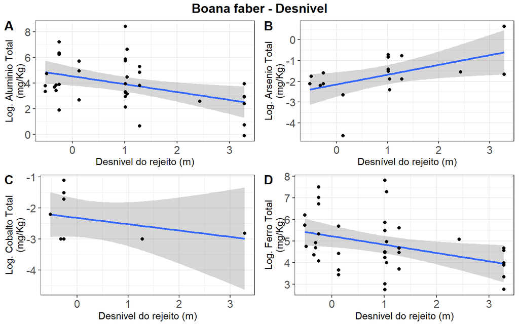

#### 4.1.2. Distância

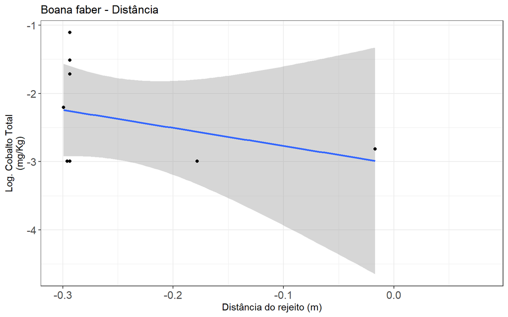

#### 4.1.3. Tipo de sitio

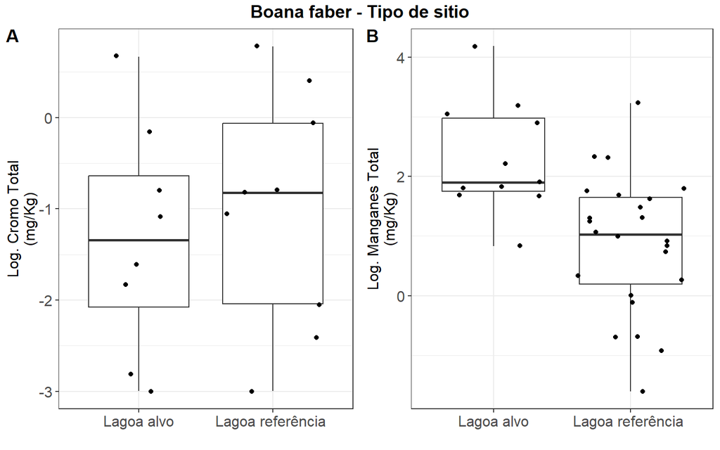

#### 4.1.4. Campanha

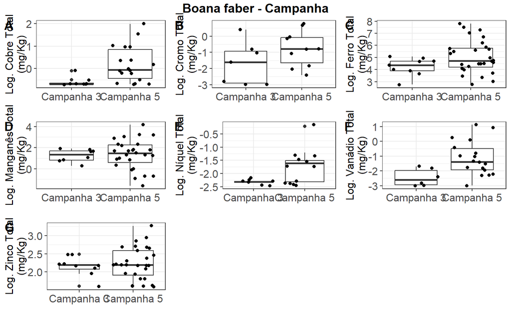

### 4.2. Boana albopunctata

#### 4.2.1. Campanha

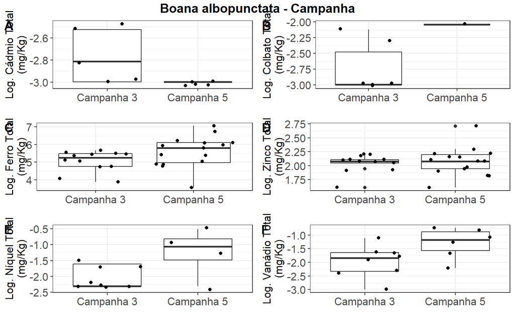

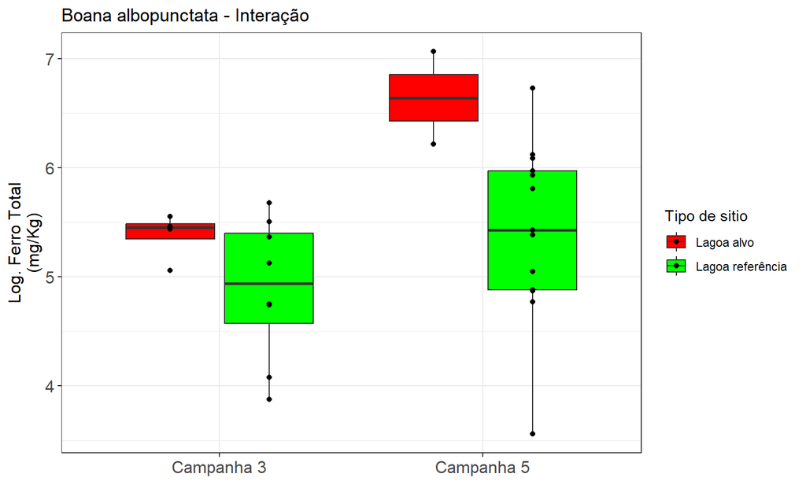

### 4.3. Boana crepitans

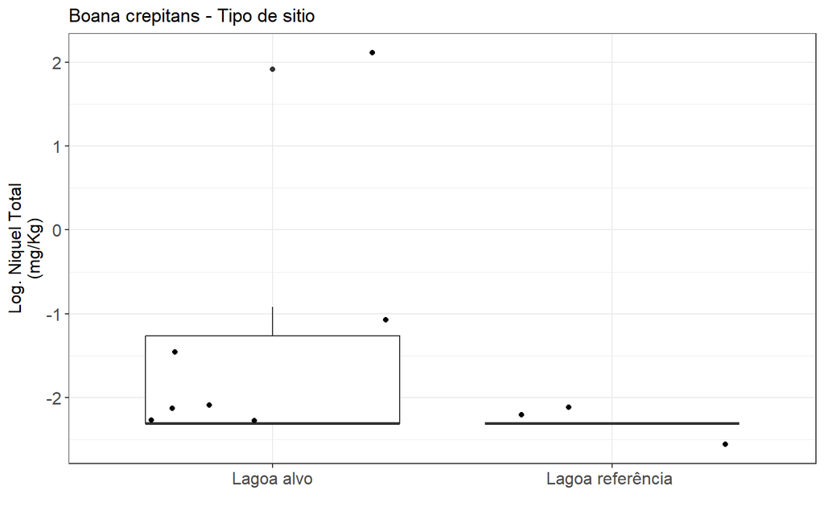

#### 4.3.2. Campanha

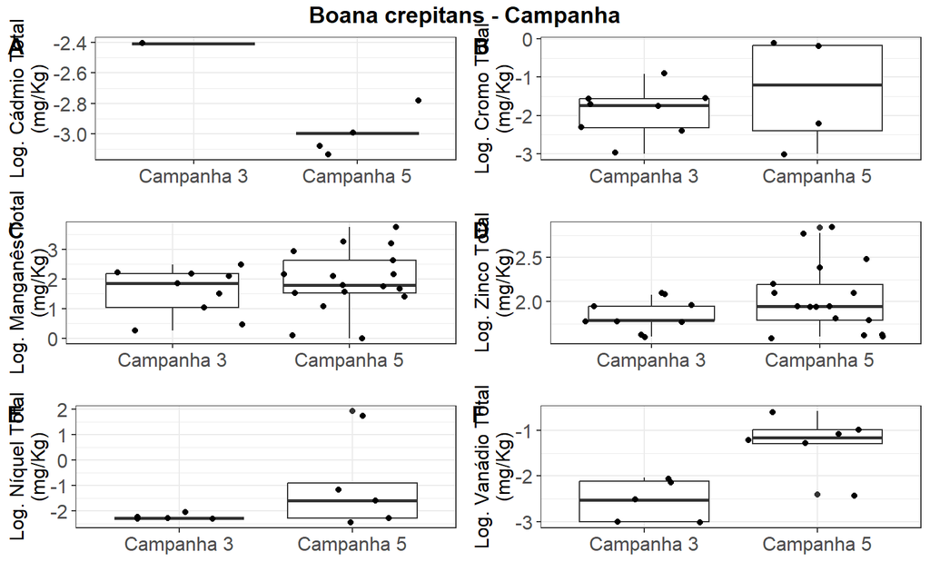

#### 4.3.3. Interação

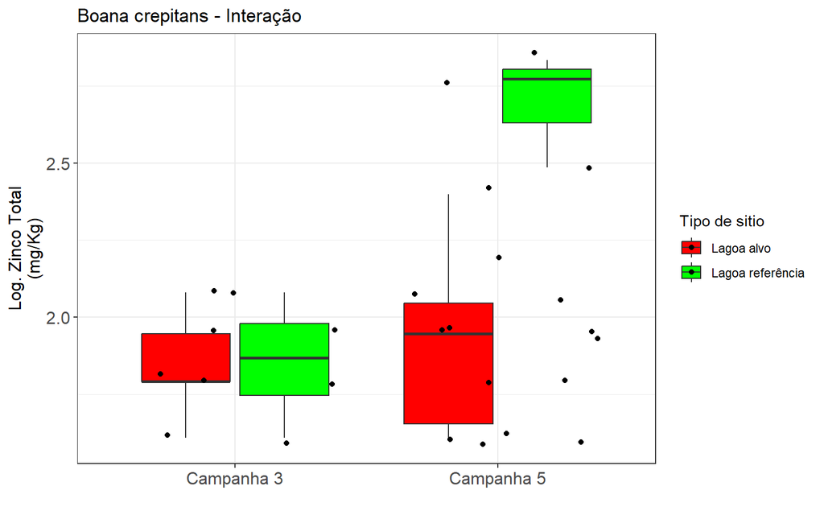

# Mamiferos

## Objetivo

- Apresentar os resultados obitidos da contaminação de metais em mamiferos.

## Dados coletados

transporte_escritorio

data_envio_oceanus

observacoes

unidade

aluminio_total

manganes_total

ferro_total

arsenio_total

zinco_total

cobre_total

cobalto_total

vanadio_total

niquel_total

cadmio_total

chumbo_total

cromo_total

desnivel_lama

distancia_lama

Contaminantes

mg/Kg

7.1

1.7

72.6

NA

22

3.2

NA

NA

0.1

NA

NA

0.05

NA

-0.2848703

PFA

3a Campanha

LB_MAM295

Akodon sp

MAM_A_153

2264057

PFA02

Fígado

1.465

Contaminantes

mg/Kg

5.7

1.6

109.1

0.42

26

2.4

NA

NA

NA

NA

NA

NA

NA

-0.2848703

PFA

3a Campanha

LB_MAM171

Akodon sp

MAM_A_097

2263954

PFA06

Rim

0,322g

Contaminantes

mg/Kg

7.7

1.5

89.4

0.24

19

3.6

NA

NA

0.1

NA

NA

NA

NA

-0.2689725

PFA

3a Campanha

LB_MAM172

Akodon sp

MAM_A_097

2263955

PFA06

Fígado

0,866g

Contaminantes

mg/Kg

44.6

2.9

199.3

0.44

38

5.6

NA

NA

NA

NA

0.08

NA

NA

-0.2689725

PFA

3a Campanha

LB_MAM240

Akodon sp

MAM_A_123

2263974

PFA10

Rim

0.196

Contaminantes

mg/Kg

25

1.7

96.8

0.48

27

5

NA

NA

NA

0.05

0.05

NA

NA

-0.2843537

PFA

3a Campanha

LB_MAM241

Akodon sp

MAM_A_123

2263975

PFA10

Fígado

0.878

Contaminantes

mg/Kg

36.7

1.3

135

0.67

43

4

NA

NA

NA

NA

NA

0.05

NA

-0.2843537

PFA

3a Campanha

LB_MAM198

Akodon sp

MAM_A_109

2263964

PFA10

Rim

0,214g

Contaminantes

mg/Kg

8.6

1.5

61.3

0.1

19

3.1

NA

0.05

0.1

NA

NA

0.12

NA

-0.2843537

PFA

3a Campanha

LB_MAM199

Akodon sp

MAM_A_109

2263965

PFA10

Fígado

0,849g

Contaminantes

mg/Kg

7.2

2.4

298.3

0.51

42

5.8

NA

NA

0.1

NA

NA

0.15

NA

-0.2843537

PFA

3a Campanha

LB_MAM029

Akodon sp

MAM_A_028

2264212

PFA13

Rim

0,4g

Contaminantes

mg/Kg

10.2

1.8

62.3

0.25

31

2.9

NA

NA

0.1

0.05

NA

0.05

NA

-0.2652845

PFA

3a Campanha

LB_MAM030

Akodon sp

MAM_A_028

2264213

PFA13

Fígado

1,4g

Contaminantes

mg/Kg

2.9

1.3

85.8

0.06

61

3.3

NA

NA

NA

NA

0.05

0.08

NA

-0.2652845

PFA

3a Campanha

LB_MAM031

Akodon sp

MAM_A_031

2264214

PFA13

Rim

0,6g

Contaminantes

mg/Kg

NA

2.1

135.1

0.28

29

5.1

NA

NA

NA

NA

NA

0.88

NA

-0.2652845

PFA

3a Campanha

LB_MAM032

Akodon sp

MAM_A_031

2264215

PFA13

Fígado

1,5g

Contaminantes

mg/Kg

10.7

1.3

256.8

0.33

72

4.2

NA

NA

NA

NA

0.13

0.2

NA

-0.2652845

PFA

3a Campanha

LB_MAM037

Akodon sp

MAM_A_032

2264217

PFA13

Rim

Contaminantes

mg/Kg

83

2.3

116.3

1.3

36

3.7

NA

NA

0.1

NA

0.74

0.17

NA

-0.2652845

PFA

3a Campanha

LB_MAM043

Akodon sp

MAM_A_033

2264218

PFA13

Rim

Contaminantes

mg/Kg

18.5

2

54.7

0.27

31

3.3

NA

0.06

0.2

0.05

NA

0.17

NA

-0.2652845

PFA

3a Campanha

LB_MAM044

Akodon sp

MAM_A_033

2264219

PFA13

Fígado

Contaminantes

mg/Kg

NA

1.1

90.3

0.37

20

2.7

NA

NA

NA

NA

NA

NA

NA

-0.2652845

PFA

3a Campanha

LB_MAM049

Akodon sp

MAM_A_035

2264220

PFA13

Rim

Contaminantes

mg/Kg

53.5

2.7

124.8

1.02

42

5

NA

NA

0.1

NA

NA

NA

NA

-0.2652845

PFA

3a Campanha

LB_MAM050

Akodon sp

MAM_A_035

2264221

PFA13

Fígado

Contaminantes

mg/Kg

6.1

0.6

74

0.15

24

2.9

NA

NA

NA

NA

NA

0.08

NA

-0.2652845

PFA

3a Campanha

LB_MAM062

Akodon sp

MAM_A_037

2264222

PFA13

Fígado

Contaminantes

mg/Kg

NA

3.3

91.7

0.19

28

4.3

NA

NA

0.1

NA

0.08

0.1

NA

-0.2652845

PFA

3a Campanha

LB_MAM079

Akodon sp

MAM_A_046

2264225

PFA15

Rim

Contaminantes

mg/Kg

1.5

0.9

71.5

0.42

17

3.6

NA

NA

NA

NA

0.21

NA

NA

-0.2867628

PFA

3a Campanha

LB_MAM080

Akodon sp

MAM_A_046

2264226

PFA15

Fígado

Contaminantes

mg/Kg

15.5

1.5

93.6

0.13

20

2.3

NA

0.08

NA

NA

NA

0.07

NA

-0.2867628

PFA

3a Campanha

LB_MAM073

Akodon sp

MAM_A_039

2263930

PFA19

Rim

Contaminantes

mg/Kg

51.3

2.3

147.7

1.85

44

6.5

NA

NA

0.1

0.05

NA

NA

NA

-0.2907678

PFA

3a Campanha

LB_MAM074

Akodon sp

MAM_A_039

2263931

PFA19

Fígado

Contaminantes

mg/Kg

51.5

2.4

98.3

NA

29

3.2

NA

NA

0.1

NA

NA

0.29

NA

-0.2907678

PFA

3a Campanha

LB_MAM091

Akodon sp

MAM_A_048

2263932

PFA19

Rim

Contaminantes

mg/Kg

30.1

2

63.6

0.02

29

3.6

NA

NA

0.4

NA

NA

0.11

NA

-0.2907678

PFA

3a Campanha

LB_MAM092

Akodon sp

MAM_A_048

2263933

PFA19

Fígado

Contaminantes

mg/Kg

7.7

2.2

88.4

0.47

26

4.3

NA

NA

NA

NA

NA

NA

NA

-0.2907678

PFA

3a Campanha

LB_MAM097

Akodon sp

MAM_A_049

2263934

PFA19

Rim

Contaminantes

mg/Kg

14.4

2

122.6

0.51

30

5.2

NA

NA

0.3

NA

0.15

0.24

NA

-0.2907678

PFA

3a Campanha

LB_MAM098

Akodon sp

MAM_A_049

2263935

PFA19

Fígado

Contaminantes

mg/Kg

13.6

1.8

76.9

NA

31

3.5

NA

NA

NA

NA

NA

0.28

NA

-0.2907678

PFA

3a Campanha

LB_MAM103

Akodon sp

MAM_A_066

2263936

PFA19

Rim

Contaminantes

mg/Kg

14.5

1.4

94.2

0.22

20

3.7

NA

NA

0.2

NA

NA

NA

NA

-0.2907678

PFA

3a Campanha

LB_MAM104

Akodon sp

MAM_A_066

2263937

PFA19

Fígado

Contaminantes

mg/Kg

18.1

2

152.5

0.33

41

5.3

NA

NA

NA

NA

NA

1.04

NA

-0.2907678

PFA

3a Campanha

LB_MAM206

Akodon sp

MAM_B_03

2263968

PFA24

Rim

0,361g

Contaminantes

mg/Kg

1.1

1.2

42.2

0.41

15

2.8

NA

NA

NA

NA

NA

NA

NA

-0.2844862

PFA

3a Campanha

LB_MAM207

Akodon sp

MAM_B_03

2263969

PFA24

Fígado

1,477g

Contaminantes

mg/Kg

3.8

3.1

233.1

0.42

32

4.7

NA

NA

0.1

NA

NA

0.2

NA

-0.2844862

PFA

Marmosops incanus

MAM_A_154

2264040

PFA02

Rim

0.237

Contaminantes

mg/Kg

2.3

1.4

88

NA

30

4.9

NA

NA

NA

NA

NA

NA

NA

-0.2848703

PFA

3a Campanha

LB_MAM301

Marmosops incanus

MAM_A_154

2264054

PFA02

Fígado

0.704

Contaminantes

mg/Kg

2.7

13.6

195.2

0.26

41

11

NA

NA

NA

0.05

0.12

0.05

NA

-0.2848703

PFA

3a Campanha

LB_MAM252

Marmosops incanus

MAM_A_128

2263976

PFA05

Rim

0.163

Contaminantes

mg/Kg

25.8

1.6

65.6

0.3

29

4

NA

NA

0.1

NA

NA

1.13

NA

-0.2823439

PFA

3a Campanha

LB_MAM253

Marmosops incanus

MAM_A_128

2264044

PFA05

Fígado

0.641

Contaminantes

mg/Kg

NA

6.2

149.2

0.03

28

10.2

NA

NA

NA

NA

NA

0.05

NA

-0.2823439

PFA

3a Campanha

LB_MAM264

Marmosops incanus

MAM_A_139

2264050

PFA07

Rim

0.248

Contaminantes

mg/Kg

<0.5

1.8

135.3

0.31

29

6.4

NA

NA

0.1

0.15

0.38

0.16

NA

-0.2807386

PFA

3a Campanha

LB_MAM265

Marmosops incanus

MAM_A_139

2264046

PFA07

Fígado

1.117

Contaminantes

mg/Kg

NA

6.1

167

0.33

30

6.9

NA

NA

NA

0.05

NA

NA

NA

-0.2807386

PFA

3a Campanha

LB_MAM306

Monodelphis americana

MAM_A_155

2264056

PFA03

Rim

0.181

Contaminantes

mg/Kg

12.2

1.5

74.4

0.62

24

5.3

NA

0.05

0.1

0.06

NA

0.08

NA

-0.2872033

PFA

3a Campanha

LB_MAM307

Monodelphis americana

MAM_A_155

2263978

PFA03

Fígado

0.673

Contaminantes

mg/Kg

18.6

19.2

482.7

0.8

53

15.8

NA

NA

NA

0.1

0.1

0.05

NA

-0.2872033

PFA

3a Campanha

LB_MAM282

Monodelphis americana

MAM_A_151

2264052

PFA04

Rim

0.183

Contaminantes

mg/Kg

NA

1.6

96.9

0.52

25

7.8

NA

NA

0.1

0.05

NA

NA

NA

-0.2848634

PFA

3a Campanha

LB_MAM283

Monodelphis americana

MAM_A_151

2264051

PFA04

Fígado

0.804

Contaminantes

mg/Kg

2.1

5.6

108.8

0.51

17

3.9

NA

NA

NA

NA

NA

NA

NA

-0.2848634

PFA

3a Campanha

LB_MAM288

Monodelphis americana

MAM_A_152

2264053

PFA04

Rim

0.181

Contaminantes

mg/Kg

0.7

1.4

117.3

0.39

28

5.5

NA

NA

NA

0.08

0.2

NA

NA

-0.2848634

PFA

3a Campanha

LB_MAM289

Monodelphis americana

MAM_A_152

2264055

PFA04

Fígado

0.981

Contaminantes

mg/Kg

0.7

12.6

136.5

0.3

33

6.6

NA

NA

NA

0.05

0.05

0.1

NA

-0.2848634

PFA

3a Campanha

LB_MAM159

Monodelphis americana

MAM_A_095

2263950

PFA06

Rim

0,191g

Contaminantes

mg/Kg

21

1.2

92

0.21

24

2.8

NA

0.07

0.1

NA

NA

3.29

NA

-0.2689725

PFA

3a Campanha

LB_MAM160

Monodelphis americana

MAM_A_095

2263951

PFA06

Fígado

1,148g

Contaminantes

mg/Kg

3.2

9.2

352.2

0.29

29

7.2

NA

NA

NA

NA

0.08

0.12

NA

-0.2689725

PFA

3a Campanha

LB_MAM165

Monodelphis americana

MAM_A_096

2263952

PFA06

Rim

0,271g

Contaminantes

mg/Kg

8.5

1.1

55.6

0.08

25

5

NA

NA

0.1

0.05

NA

0.09

NA

-0.2689725

PFA

3a Campanha

LB_MAM166

Monodelphis americana

MAM_A_096

2263953

PFA06

Fígado

0,558g

Contaminantes

mg/Kg

5.8

9.3

147.2

0.25

24

5.6

NA

NA

NA

NA

NA

0.08

NA

-0.2689725

PFA

3a Campanha

LB_MAM177

Monodelphis americana

MAM_A_102

2263956

FFR33

Rim

0,097g

Contaminantes

mg/Kg

10

1

71.2

0.77

26

3.5

NA

NA

0.4

0.07

NA

NA

NA

-0.0436645

FFR

3a Campanha

LB_MAM178

Monodelphis americana

MAM_A_102

2263957

FFR33

Fígado

0,269g

Contaminantes

mg/Kg

NA

17.7

209.1

0.44

46

10.3

NA

NA

NA

0.05

NA

NA

NA

-0.0436645

FFR

3a Campanha

LB_MAM189

Monodelphis americana

MAM_A_104

2263960

PFA06

Rim

0,208g

Contaminantes

mg/Kg

20.7

1

81.2

0.32

26

3

NA

NA

0.3

NA

0.05

0.13

NA

-0.2689725

PFA

3a Campanha

LB_MAM190

Monodelphis americana

MAM_A_104

2263961

PFA06

Fígado

0,876g

Contaminantes

mg/Kg

3.4

3.4

65.4

NA

13

2.6

NA

0.05

NA

0.05

NA

0.06

NA

-0.2689725

PFA

3a Campanha

LB_MAM270

Monodelphis americana

MAM_A_146

2264045

PFA07

Rim

0.2808

Contaminantes

mg/Kg

11.3

1.1

82

0.32

24

5.8

NA

NA

NA

0.07

NA

NA

NA

-0.2807386

PFA

3a Campanha

LB_MAM271

Monodelphis americana

MAM_A_146

2264047

PFA07

Fígado

1.257

Contaminantes

mg/Kg

6.6

10.6

286.6

0.44

42

9.7

NA

NA

NA

0.05

NA

0.16

NA

-0.2807386

PFA

3a Campanha

LB_MAM055

Monodelphis americana

MAM_A_036

2264223

PFA13

Rim

Contaminantes

mg/Kg

101.3

2.1

94.8

0.5

37

4.1

NA

0.05

2.2

NA

NA

0.66

NA

-0.2652845

PFA

3a Campanha

LB_MAM056

Monodelphis americana

MAM_A_036

2264224

PFA13

Fígado

Contaminantes

mg/Kg

4.2

4

183.5

0.13

17

3.1

NA

0.05

0.1

0.05

NA

0.29

NA

-0.2652845

PFA

3a Campanha

LB_MAM085

Monodelphis americana

MAM_A_047

2264062

PFA15

Rim

Contaminantes

mg/Kg

62.5

2.2

137.1

0.69

33

6.2

NA

NA

0.5

0.05

0.14

0.39

NA

-0.2867628

PFA

3a Campanha

LB_MAM086

Monodelphis americana

MAM_A_047

2264063

PFA15

Fígado

Contaminantes

mg/Kg

1.3

8

244.9

NA

24

5.6

NA

0.06

NA

0.05

0.05

0.05

NA

-0.2867628

PFA

3a Campanha

LB_MAM109

Monodelphis americana

MAM_A_067

2263926

PFA15

Rim

Contaminantes

mg/Kg

17.3

1.3

111.4

0.71

23

7.3

NA

NA

NA

0.17

NA

NA

NA

-0.2867628

PFA

3a Campanha

LB_MAM110

Monodelphis americana

MAM_A_067

2263927

PFA15

Fígado

Contaminantes

mg/Kg

25.5

5.7

534.3

0.5

28

7.4

NA

NA

NA

0.13

0.05

NA

NA

-0.2867628

PFA

3a Campanha

LB_MAM122

Monodelphis americana

MAM_A_079

2263929

PFA15

Fígado

Contaminantes

mg/Kg

NA

9.3

313

0.62

21

6.3

NA

NA

0.1

NA

0.05

0.05

NA

-0.2867628

PFA

3a Campanha

LB_MAM115

Monodelphis americana

MAM_A_078

2263938

PFA19

Rim

Contaminantes

mg/Kg

10.4

1

105.4

0.15

20

4.4

NA

NA

0.2

0.07

NA

0.14

NA

-0.2907678

PFA

3a Campanha

LB_MAM116

Monodelphis americana

MAM_A_078

2263939

PFA19

Fígado

Contaminantes

mg/Kg

1.2

6.1

387.7

0.45

24

5.8

NA

NA

NA

0.06

0.12

0.07

NA

-0.2907678

PFA

3a Campanha

LB_MAM067

Monodelphis sp.

MAM_A_038

2264060

PFA15

Rim

Contaminantes

mg/Kg

1

1.2

100.5

0.23

20

5.1

NA

NA

0.1

NA

0.59

NA

NA

-0.2867628

PFA

3a Campanha

LB_MAM068

Monodelphis sp.

MAM_A_038

2264061

PFA15

Fígado

Contaminantes

mg/Kg

13.5

10.9

106.6

0.95

24

7.1

NA

NA

0.1

NA

0.09

NA

NA

-0.2867628

PFA

Didelphis aurita

MAM_C_080

2308327

Ilha01

Rim

2.048

Contaminantes

mg/Kg

936.3

37

327.1

39.22

25

4.9

NA

0.11

0.7

0.24

0.85

0.58

-0.1674027

-0.2770889

Ilha

3a Campanha

LB_MAM487 - Ilha 1

Didelphis aurita

MAM_C_080

2308343

Ilha01

Fígado

1.079

Contaminantes

mg/Kg

271.4

48

221.4

42.28

49

3.8

NA

NA

0.8

0.19

0.52

0.57

-0.1674027

-0.2770889

Ilha

3a Campanha

LB_MAM492 - Ilha 1

Didelphis aurita

MAM_C_081

2308339

Ilha01

Rim

2

Contaminantes

mg/Kg

756.7

41.9

109

43.84

28

5.3

NA

0.22

0.8

0.24

0.9

0.52

-0.1674027

-0.2770889

Ilha

3a Campanha

LB_MAM493 - Ilha 1

Didelphis aurita

MAM_C_081

2308341

Ilha01

Fígado

1.076

Contaminantes

mg/Kg

361.9

38.2

141.9

33.88

30

25.4

NA

0.08

0.7

0.18

0.89

1.13

-0.1674027

-0.2770889

Ilha

3a Campanha

LB_MAM498 - Ilha 1

Didelphis aurita

MAM_C_082

2308342

Ilha01

Rim

1.661

Contaminantes

mg/Kg

592.9

41.4

165.2

40.38

27

4.5

NA

0.12

0.7

0.21

0.28

0.51

-0.1674027

-0.2770889

Ilha

3a Campanha

LB_MAM499 - Ilha 1

Didelphis aurita

MAM_C_082

2308354

Ilha01

Fígado

1.297

Contaminantes

mg/Kg

288.9

34.1

224.8

32.62

34

3.8

NA

NA

0.6

0.14

0.89

0.48

-0.1674027

-0.2770889

Ilha

3a Campanha

LB_MAM504 - Ilha 1

Didelphis aurita

MAM_C_083

2308337

Ilha01

Fígado

1.038

Contaminantes

mg/Kg

326.5

45.7

156.1

42.22

32

4.4

NA

0.05

0.9

0.18

0.93

0.65

-0.1674027

-0.2770889

Ilha

3a Campanha

LB_MAM480 - Ilha 3

Didelphis aurita

MAM_C_077

2308340

Ilha03

Rim

1.518

Contaminantes

mg/Kg

1564

44

120.8

55.2

20

4.3

NA

0.19

0.9

0.18

0.8

0.64

-0.1526319

-0.2845241

Ilha

3a Campanha

LB_MAM481 - Ilha 3

Didelphis aurita

MAM_C_077

2308344

Ilha03

Fígado

1.076

Contaminantes

mg/Kg

1052.5

43.8

268

48.88

32

16

NA

0.17

0.9

0.18

0.93

0.64

-0.1526319

-0.2845241

Ilha

3a Campanha

LB_MAM462 - Ilha 4

Didelphis aurita

MAM_C_049

2308330

Ilha04

Rim

2.902

Contaminantes

mg/Kg

1264.3

41.8

123.2

52.2

24

4.1

NA

0.51

1

0.75

1.01

0.64

-0.0640075

-0.2861033

Ilha

3a Campanha

LB_MAM463 - Ilha 4

Didelphis aurita

MAM_C_049

2308351

Ilha04

Fígado

3.006

Contaminantes

mg/Kg

931.3

NA

205.6

1.41

19

2.1

NA

0.16

NA

0.05

0.91

0.09

-0.0640075

-0.2861033

Ilha

3a Campanha

LB_MAM466 - Ilha 4

Didelphis aurita

MAM_C_048

2308349

Ilha04

Rim

2.348

Contaminantes

mg/Kg

1275.6

NA

97.1

0.01

27

4.5

NA

0.18

NA

0.48

0.64

NA

-0.0640075

-0.2861033

Ilha

3a Campanha

LB_MAM467 - Ilha 4

Didelphis aurita

MAM_C_048

2308348

Ilha04

Fígado

2.937

Contaminantes

mg/Kg

1550.6

44.8

465.3

56.38

27

3.1

NA

0.26

1

0.25

1.1

0.63

-0.0640075

-0.2861033

Ilha

3a Campanha

LB_MAM470 - Ilha 4

Didelphis aurita

MAM_C_047

2308352

Ilha04

Rim

1.123

Contaminantes

mg/Kg

1789.5

1.6

357.1

17.2

36

10.8

NA

0.53

0.1

0.07

0.36

0.11

-0.0640075

-0.2861033

Ilha

3a Campanha

LB_MAM471 - Ilha 4

Didelphis aurita

MAM_C_047

2308328

Ilha04

Fígado

2.905

Contaminantes

mg/Kg

1243.2

42.6

393.8

48.49

27

3.4

NA

0.17

0.8

0.16

1.42

0.6

-0.0640075

-0.2861033

Ilha

3a Campanha

LB_MAM472 - Ilha 4

Didelphis aurita

MAM_C_046

2308353

Ilha04

Rim

1.005

Contaminantes

mg/Kg

182.4

NA

38.6

NA

18

3.7

NA

0.05

NA

0.05

NA

NA

-0.0640075

-0.2861033

Ilha

3a Campanha

LB_MAM473 - Ilha 4

Didelphis aurita

MAM_C_046

2308345

Ilha04

Fígado

1.862

Contaminantes

mg/Kg

674.4

52.1

241.6

51.32

24

3.1

NA

0.05

1

0.18

1.54

0.64

-0.0640075

-0.2861033

Ilha

3a Campanha

LB_MAM460 - Ilha 5

Didelphis aurita

MAM_C_042

2308332

Ilha05

Rim

1.435

Contaminantes

mg/Kg

754.1

NA

74.8

NA

18

5

NA

0.09

NA

0.09

0.41

NA

0.1575534

-0.2840635

Ilha

3a Campanha

LB_MAM461 - Ilha 5

Didelphis aurita

MAM_C_042

2308347

Ilha05

Fígado

1.969

Contaminantes

mg/Kg

349.7

NA

173.7

NA

27

2.5

NA

0.05

NA

NA

0.31

NA

0.1575534

-0.2840635

Ilha

3a Campanha

LB_MAM464 - Ilha 5

Didelphis aurita

MAM_C_044

2308350

Ilha05

Rim

1.682

Contaminantes

mg/Kg

1217.8

NA

102

1.78

18

4.3

NA

0.15

NA

0.06

0.12

NA

0.1575534

-0.2840635

Ilha

3a Campanha

LB_MAM465 - Ilha 5

Didelphis aurita

MAM_C_044

2308331

Ilha05

Fígado

2.042

Contaminantes

mg/Kg

1103.1

43.2

299

49.1

26

4.5

NA

0.08

0.8

0.18

1.15

0.56

0.1575534

-0.2840635

Ilha

3a Campanha

LB_MAM468 - Ilha 5

Didelphis aurita

MAM_C_043

2308329